# Gliederung

Die Arbeit wurde komplett in Python erstellt. Dazu wurden zwei Programme angwendet. Die IDE (integrated development environment) Pycharm wurde für den ersten Teil der Arbeit verwendet. Jupyter Notebook in dem auch diese Gesamtübersicht erstellt wurde, wurde für die weiteren Teile der Arbeit verwendet. Pycharm eignet sich besonders gut um Fehler im Code zu beheben. Jupyter Notebook ist besser zur Darstellung, Übersicht und Navigation des Codes geeignet.

**Die Arbeit ist untergliedert in vier Teile:**

1. Extrahieren der Daten und Auswahl an Prädiktoren
2. Deskripitive Statistik - Erstellen von Schaubildern
3. Induktive Statistik - Regressionen
4. Das aktuelle Sortiment (nicht in der schriftlichen Arbeit enthalten)

Verwendete Module zum Erstellen des Datensatzes:

```python
import json, re, csv, requests, sys, json, time
from math import sqrt
from collections import Counter
from checking_numbers import checking_number, getting_attributes, creating_new_fieldnames
from bs4 import BeautifulSoup
from multiprocessing.pool import ThreadPool
```

Verwendete Module zur grafischen Darstellung der Merkmale:

```python
import pandas as pd
import numpy as np
import matplotlib as mp
import seaborn as sns
import matplotlib.pyplot as plt
from collections import Counter
from matplotlib import colors
from mpl_toolkits.axes_grid1 import make_axes_locatable
import matplotlib.patches as mpatches
```

Verwendete Module zum Erstellen der Regressionen:

```python
import statsmodels.api as sm
import statsmodels.stats.api as sms
from statsmodels.compat import lzip
import statsmodels.stats.outliers_influence as outliers_influence
from patsy import dmatrices
from sklearn.model_selection import cross_val_score, cross_val_predict
from sklearn.linear_model import LinearRegression, RidgeCV
```

## Extrahieren der Daten und Auswahl an Prädiktoren

Zurück zur Gliederung

1. Parsen des HTML-Codes und Speichern der Links zu Laptops
2. Extrahieren der Daten zu Laptops
3. Beschränken der Merkmale auf analyserelevante Prädiktoren
4. Normieren der Prädiktoren
5. Erstellen der Pixeldichte
6. Beifügen der Daten zu Grafikkarte

### Parsen des HTML-Codes und Speichern der Links zu Laptops

Zurück zu Extrahieren der Daten und Auswahl an Prädiktoren

Um die Daten aus dem Code zu extrahieren werden zunächst die einzelnen URLs aufgerufen. Die URL der ersten Seite aller Notebooks auf Alternate.de ist:

*https://www.alternate.de/Alle-Notebooks/html/listings/1444138486045?lk=21363&size=120&hideFilter=false*

Die zweite Seite der Laptops:

*https://www.alternate.de/Alle-Notebooks/html/listings/1444138486045?lk=21363&page=2&size=120&hideFilter=false*

Die dritte Seite der Laptops:

*https://www.alternate.de/Alle-Notebooks/html/listings/1444138486045?lk=21363&page=3&size=120&hideFilter=false*

usw...

**Die zweite und die dritte Seite unterscheiden sich also nur hinsichtlich "page=...", auf der ersten Seite wurde "page=..." ausgelassen**

Um also alle Links zu sämtlichen Seiten zu bekommen, auf denen sich die Links zu den einzelnen Laptops befinden, kann in allen Links die entsprechende Stelle für "page=..." angepasst werden. Die generierten Links werden einer Liste beigefügt:

```python
BaseURLs = []
def getting_base_urls():
    BaseURLs.append("https://www.alternate.de/Alle-Notebooks/html/listings/1444138486045?lk=21363&size=120&hideFilter=false")
    for number in range(2, 16):
        BaseURLs.append(r"https://www.alternate.de/Alle-Notebooks/html/listings/1444138486045?lk=21363&page="+str(number)+"&size=120&hideFilter=false")
```

In der Liste "BaseURLs" befinden sich also alle Links unter denen die einzelnen Laptops aufgerufen werden können. Mittels des Moduls *requests* lässt sich der HTML-Code von einer beliebigen Webseite in den Speicher des Rechners laden.

In Zeile 4 des untenstehenden Codes wird damit der Code geladen. Um den Server mit Anfragen nicht zu überladen und somit zu riskieren, dass die IP-Adresse des Rechners gesperrt wird, wird nur alle drei Sekunden eine Anfrage zum Laden einer neuen Seite gestellt. In Zeile 3 des untenstehenden Codes wurde diese Methode angewendet.

Anschließend werden mittels des Moduls BeautifulSoup und des LXML-Parsers sämtliche Links zu allen Laptops gefunden. Links in einem HTML-Code sind überlicherweise mit *href* gekennzeichnet. So auch in diesem Fall. Der Screenshot zeigt, dass sich die Links der Laptops in einem *<a-Tag* befinden (dunkelrot markiert). Es wird versucht aus sämtlichen <a-Tags der Klasse productLink:

```
for article in soup.find_all("a", class_= "productLink"):
```

das Attribut href, also den Link, in den Speicher des Rechners zu lesen:

```
    URLs.append(article.get("href")+"\n")
```

[figure not shown]

```python
def getting_hyperlinks(BaseURLs):
    global BaseURL_searched
    time.sleep(3)
    source = requests.get(BaseURLs).text
    soup = BeautifulSoup(source, "lxml")
    for article in soup.find_all("a", class_= "productLink"):
        URLs.append(article.get("href")+"\n")
        print(article.get("href"))
    BaseURL_searched += 1
    sys.stdout.write("\r%i BaseURLs searched" % BaseURL_searched)
```

### Extrahieren der Daten zu Laptops

Zurück zu Extrahieren der Daten und Auswahl an Prädiktoren

Um nun aus den Links zu den einzelnen Laptops die Daten zu extrahieren, die als Prädiktoren den Preis erklären sollen, wird erneut die HTML-Struktur der Webeseiten untersucht. Allerdings wird diesmal der Code einer Ebene tiefer untersucht, also der Code der einzelnen Laptops. Für jeden Laptops wird ein Dictionary angelegt, in dem sich alle Informationen des Laptops befinden:

```
indiv_information = {}
```

Erneut werden die Links, die mittels des obenstehenden Codes gefunden und gespeichert wurden aufgerufen und mittels des LXML-Parsers leicht zugänglich gemacht:

```
joined_url = "https://www.alternate.de"+URL
source = requests.get(joined_url).text
soup = BeautifulSoup(source, "lxml")
```

Der Preis wird mit derselben Methode, mit der auch die Links der einzelnen Laptops gefunden wurden, ausfindig gemacht:

```
price = soup.find("span", itemprop= "price")
indiv_information.update({"Laptop_ID": laptops_found, "Preis": price.get("content")})
print(joined_url)
```

Ebenso wird mit den Prädiktoren verfahren. Aus der Grafik ist ersichtlich, dass die Liste der Eigenschaften des Laptops *tech Data* benannt wurde (blau markiert) und sich in einem <div-Tag befindet.

```
specification_table = soup.find("div", class_="techData")
```

Die einzelnen Merkmale in der Auflistung *tech Data* befinden sich in

```
for specification in specification_table.find_all("tr"):
    getting_cat(specification, indiv_information)
indiv_information.update({"URL": joined_url})
return indiv_information
```

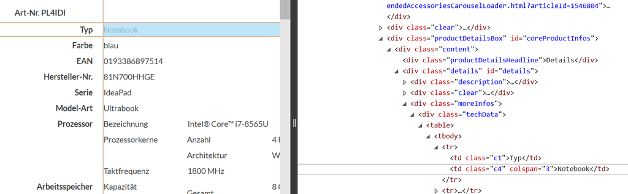

```python
def getting_information(URL):
    global laptops_found
    laptops_found += 1
    sys.stdout.write("\rData downloaded for %i laptops" % laptops_found)
    indiv_information = {}
    joined_url = "https://www.alternate.de"+URL
    source = requests.get(joined_url).text
    soup = BeautifulSoup(source, "lxml")
    #Preis
    price = soup.find("span", itemprop= "price")
    indiv_information.update({"Laptop_ID": laptops_found, "Preis": price.get("content")})
    print(joined_url)
    #Prädiktoren
    specification_table = soup.find("div", class_="techData")
    for specification in specification_table.find_all("tr"):
        getting_cat(specification, indiv_information)
    indiv_information.update({"URL": joined_url})
    return indiv_information

def getting_cat(specification, indiv_information):
    namelist = []
    number = "c4"
    value = specification.find("td", class_=number).get_text()
    while number != "c1":
        key = None
        while key is None:
            try:
                key = specification.find("td", class_=number).previous_sibling
                keytext = key.string
                if keytext is None:
                    specification = specification.previous_sibling
                else:
                    number = "".join(key["class"])
                    namelist.append(keytext)
            except AttributeError:
                specification = specification.previous_sibling
    keytext = "-".join(namelist)
    indiv_information.update({keytext: value})
```

Da bisher nur Funktionen definiert wurden (def ...), diese aber nicht ausgeführt wurden, werden diese nun ausgeführt. Da außerdem zu über 1700 Laptops die Daten mittels Parser übersetzt und extrahiert werden sollen und dieser Prozess lange dauern könnte, wird Multithreading angewendet, also das Auslasten aller verfügbaren Prozessorkerne. In Python lässt sich Multithreading unter anderem mit dem Modul multiprocessing und der zugehörigen Funktion ThreadPool durchführen:

```
    with ThreadPool() as p:
    hyperlinks = p.map(getting_hyperlinks, BaseURLs)
    individual_information = p.map(getting_information, URLs)
```

Die Daten der Laptops werden in einer Json-Datei gespeichert und der ThreadPool nach Ausführen des Programms geschlossen:

```
    json.dump(individual_information, json_file)
    p.close()
    p.join()
```

```python
if __name__ == '__main__':

    BaseURLs = []  # Links der Seiten, unter denen die Laptops aufgerufen werden können
    URLs = []  # Links der einzelnen Laptops
    laptops_found = 0
    BaseURL_searched = 0

    json_file = open("laptop_information_neu.json", "w")
    getting_base_urls()
    with ThreadPool() as p:
        hyperlinks = p.map(getting_hyperlinks, BaseURLs)
        individual_information = p.map(getting_information, URLs)
        json.dump(individual_information, json_file)
        p.close()
        p.join()

    json_file.close()
```

Die gespeicherten Daten werden dann zur Auswahl der Prädiktoren und Normierung erneut geladen. Dazu wird ein eigenhändig geschriebenes Modul (creating_new_fieldnames) angewendet, dass eine Liste der Merkmale erstellt:

```python
with open("laptop_information.json", "r") as old_data:
    reader = json.load(old_data)
Fieldnames = creating_new_fieldnames(reader)
c = Counter(Fieldnames) # Überprüft die Anzahl der Merkmale
```

Zwei weitere eigenhändig geschriebene Module erlauben es zu überprüfen, wie häufig die einzelnen Merkmalsausprägungen auftreten und wie viele Merkmalsausprägungen vorhanden sind. Die Module sind nicht wesentlicher Bestandteil der Arbeit und werden deshalb nicht beschrieben. Eine zusätzliche Eigenschaft der Funktion _getting*attributes* ist, dass damit eine Excel-Tabelle der vier häufigsten Ausprägungen erstellt wird, die auf der letzten Seite der Arbeit abgebildet ist.

```python
checking_number(reader)
getting_attributes(reader, Fieldnames, Excel_Tabelle_speichern=True, Name_Excel_Tabelle="Übersicht Merkmale")
```

### Beschränken der Merkmale auf analyserelevante Prädiktoren

Zurück zu Extrahieren der Daten und Auswahl an Prädiktoren

Anschließend wurde unterschieden zwischen Merkmalen die *MCAR* und *MNAR* zuzuschreiben sind, die in Listen zusammengefasst wurden. Es wurde unteschieden zwischen qualitativen und quantitativen *MNAR* -Merkmalen (_nicht_vorhanden*qualitativ* _, nicht_vorhanden*quantitativ), MCAR* -Merkmalen (behalten_liste), Eigenschaften die den Preis vermutlich stark beeinflussen, aber zu denen nur wenige Observationen Ausprägungen besitzen (_laptop_löschen*liste* ) und Kathegorien, die nicht berücksichtigt wurden (_remove_c*list* ):

```python
nicht_vorhanden_qualitativ = ["Tastatur-Beleuchtung", "Fingerabdrucksensor-Eingabe", "Mikrofon-Sound",
                  "Touchscreen-Eingabe","Mobilefunk Standards-Konnektivität", "NFC-Konnektivität", "Hinweis"]
nicht_vorhanden_quantitativ = ["Speicher 2-Datenspeicher", "Speicher 3-Datenspeicher", "Gesamt-Speicher-Grafik"]
behalten_liste = ["Anzahl-Prozessorkerne-Prozessor", "Bild-Display", "Speicher 1-Datenspeicher",
               "Taktfrequenz-Prozessor", "Typ-Arbeitsspeicher", "Auflösung-Display",
               "Lautsprecher-Sound", "Typ-Optisches Laufwerk", "Stromquelle-Akku-Stromversorgung"]
laptop_löschen_liste = ["Gehäuse-Beleuchtung", "G-Sync-Display", "Handvenensensor-Eingabe"]
remove_c_list =["Hersteller-Nr.", "Typ", "Layout-Tastatur-Eingabe", "Farbe", "Abmessungen", "vorhanden-Zubehör",
                "Bluetooth-Konnektivität", "Gewicht", "EAN", "Anzahl -Webcam-Kamera", "Kartenleser", "Art-Display",
                "Weitere Informationen", 'davon-Speicher-Grafik', "Gesamtkapazität-Datenspeicher",
                "Funktionen-Tastatur-Eingabe", "Maus/Touchpad-Eingabe", "Funktion",
                "SoundChip-Sound", "Architektur-Prozessorkerne-Prozessor", "Serie", "WLAN-Konnektivität",
                "Eigenschaft-Display", "LAN-Konnektivität", "Slots-Arbeitsspeicher",
                "Seitenverhältnis-Display", "Besonderheiten-Webcam-Kamera",
                "Dauer-Akku-Stromversorgung", "max. unterstützt	-Kapazität-Arbeitsspeicher", "Helligkeit-Display",
                "Modellbezeichnung", "Detail-Display", "Sprache-Beleuchtung", "Webcam-Auflösung 1-Webcam-Kamera",
                "Frequenz-Display", "Model-Art", "Kapazität-Akku-Stromversorgung", "Feature", "Kontrast-Display", "Lesen-Formate-Optisches Laufwerk",
                "Schreiben-Formate-Optisches Laufwerk", "Chipsatz", "Sprache-Eingabe",
                "max. Leistungsaufnahme-Prozessor", "Besonderheiten-Rückseite-Kamera", "Anzahl Objektive-Rückseite-Kamera",
                "Auflösung 1-Rückseite-Kamera", "intern-Schnittstellen", "Zusätzliche Info-Eingabe",
                "Ladezeit-Akku-Stromversorgung", "Ortung", "Lizenz-Beleuchtung", "HDR-Display",
                "Zusätzliche Info-Beleuchtung", "optional-Zubehör", "Lizenz-Eingabe", "SLI-Grafik"]
```

Es werden also drei Funktionen erstellt, die erste Funktion ( _deleting*observations* ) löscht Laptops mit Ausprägungungen der in _laptop_löschen*liste* definierten Merkmale sowie Laptops, die die Merkmale aus _behalten*liste* nicht vorweisen. Zu quantitativen und qualitativen Merkmalen werden in _replacing_missing*data* bei nicht vorhandenen Ausprägungen geschlussfolgert, dass die Ausprägungen entweder _nicht*vorhanden* bzw. 0 ist. Nicht analyserelevante Merkmale werden in _removing_from*laptop* gelöscht:

```python
def deleting_observations(keeping_list, deleting_list):
    for keep_element in keeping_list:
        for delete_element in deleting_list:
            for laptop in reader:
                if keep_element not in laptop:
                    reader.remove(laptop)
                else:
                    if delete_element in laptop:
                        reader.remove(laptop)

deleting_observations(behalten_liste, laptop_löschen_liste)

def replacing_missing_data(list,  new_value):
    for attribute in list:
        for laptop in reader:
            if attribute not in laptop:
                    laptop[attribute] = new_value

replacing_missing_data(nicht_vorhanden_qualitativ, "nicht vorhanden")
replacing_missing_data(nicht_vorhanden_quantitativ, "0")

def removing_from_laptop(dellist):
    for laptop in reader:
        for element in dellist:
            if element in laptop:
                del laptop[element]
            try:
                Fieldnames.remove(element)
            except ValueError:
                continue

removing_from_laptop(remove_c_list)
```

Es wird erneut eine Excel-Tabelle mit den restlichen Ausprägungen erstellt:

```python
getting_attributes(reader, Fieldnames, Excel_Tabelle_speichern=True, Name_Excel_Tabelle="Übersicht Merkmale")
```

Vereinzelt waren die Informationen unvollständig. Wenn die Speicherart nicht ausdrücklich genannt wurde oder zwei Grafikkarten vorhanden waren (für ein Laptop der Fall), so werden auch diese Laptops aus der Analyse ausgeschlossen:

```python
def deleting_certain_obs(attribute, value):
    for laptop in reader:
        if laptop[attribute] == value:
            reader.remove(laptop)
            print("gelöscht aus", attribute, ":", laptop[attribute])
print("so viele Laptops sind noch im Datensatz: ", len(reader))
# Bei den folgenden Datenspeichern wurden keine Angaben zur Speicherart gemacht, weshalb sie gelöscht werden
deleting_certain_obs("Speicher 1-Datenspeicher", "512 GB")
deleting_certain_obs("Speicher 1-Datenspeicher", "256 GB")
deleting_certain_obs("Speicher 1-Datenspeicher", "1.000 GB [5400 U/min]")
deleting_certain_obs("Speicher 1-Datenspeicher", "64 GB [Flash]")
deleting_certain_obs("Speicher 2-Datenspeicher", "1.000 GB [5400 U/min]")
deleting_certain_obs("Speicher 3-Datenspeicher", "undefined [5400 U/min]")
print("so viele Daten sind noch im Datenset: ", len(reader))
# Ein Laptop der zwei Grafikkarten besitzt wird gelöscht
deleting_certain_obs("Typ-Grafik", "2x NVIDIA GeForce RTX 2080")

print("so viele Laptops sind noch im Datensatz: ", len(reader))
```

### Normieren der Prädiktoren

Zurück zu Extrahieren der Daten und Auswahl an Prädiktoren

Um die Daten zu normieren werden reguläre Ausdücke angewendet. Auch hier wird eine Funktion erstellt, die vergleicht, welchen Wert die Ausprägung vor und nach der Normierung angenommen hat:

```python
def general_regex(regex, subst, ct):
    already_printed = [] # wurde die Ausprägung und die folgende Normierung schon gedruckt, soll die Ausprägung nicht erneut
    # dargestellt werden, weshalb hierfür eine Liste bereits gedruckter Ausprägungen erstellt wird
    print(ct.center(80, "="))
    for laptop in reader:
        pass_statement = False
        if regex.fullmatch(laptop[ct]):
            if laptop[ct] not in already_printed:
                print("vor Normierung:".ljust(40, "-") + laptop[ct].rjust(40, "-"), 10 * " ", laptop["URL"], end= "")
                already_printed.append(laptop[ct])
                pass_statement = True
            laptop[ct] = regex.sub(subst, laptop[ct]).upper()
            if pass_statement is True:
                print("nach Normierung:".ljust(40, "-") + laptop[ct].rjust(40, "-"))
        else:
            if laptop[ct] not in already_printed:
                already_printed.append(laptop[ct])
```

Die einzelnen Regulären Ausdrücke werden erstellt und auf die Merkmale mittels der erstellen Funktion _general*regex* angewendet.

Besonderheiten dabei:

1. Für die Festplatte wird eine eigene Funktion erstellt, die den Speicher in SSD, HDD und EMMC unterteilt, wobei die Laptops mit EMMC-Speicherkarte allerdings nicht berücksichtigt werden
2. Für den Akku wird ebenfalls eine Funktion erstellt, die in Akku-Typ und Akku-Kapazität unterteilt

```python
# Prozessor
Prozessor_Kerne_regex = re.compile(r"(\d)(\sKerne)")
general_regex(Prozessor_Kerne_regex, r"\1", "Anzahl-Prozessorkerne-Prozessor")

# Arbeitsspeicher, Taktfrequenz des Prozessors
Taktfr_Arbeitssp_regex = re.compile(r"(\d\d?\d?\d?)(.*)")
general_regex(Taktfr_Arbeitssp_regex, r"\1", "Gesamt-Kapazität-Arbeitsspeicher")
general_regex(Taktfr_Arbeitssp_regex, r"\1", "Taktfrequenz-Prozessor")

# Festplatte
HDD_SSD_eMMC_regex = re.compile(r"(\d?.?\d?\d\d) GB \[(.*)?(HDD|SSD|eMMC)(.*)?\]", re.IGNORECASE)
SSD_regex = re.compile(r"(\d?.\d?\d\d) GB \[(.*)(M\.2|PCIe|SSHD)(.*)", re.IGNORECASE)
for laptop in reader:
    laptop["HDD-Kapazität"], laptop["HDD-Anzahl"] = 0, 0
    laptop["SSD-Kapazität"], laptop["SSD-Anzahl"] = 0, 0
    laptop["EMMC-Kapazität"], laptop["EMMC-Anzahl"]= 0, 0
def split_Festplatte(storage, type):
    for laptop in reader:
        if type in str(laptop[storage]):
            xy = laptop[storage].split(" ")
            laptop[type+"-Anzahl"] += 1
            laptop[type + "-Kapazität"] += int(xy[0].replace(".", ""))
            laptop[storage] = int(xy[0].replace(".", ""))
            laptop[storage+"-Typ"] = type
# 1 Festplatte
general_regex(HDD_SSD_eMMC_regex, r"\1 \3", "Speicher 1-Datenspeicher")
general_regex(SSD_regex, r"\1 SSD", "Speicher 1-Datenspeicher")
split_Festplatte("Speicher 1-Datenspeicher", "HDD")
split_Festplatte("Speicher 1-Datenspeicher", "SSD")
split_Festplatte("Speicher 1-Datenspeicher", "EMMC")
# 2 Festplatte
general_regex(HDD_SSD_eMMC_regex, r"\1 \3", "Speicher 2-Datenspeicher")
general_regex(SSD_regex, r"\1 SSD", "Speicher 2-Datenspeicher")
split_Festplatte("Speicher 2-Datenspeicher", "HDD")
split_Festplatte("Speicher 2-Datenspeicher", "SSD")
split_Festplatte("Speicher 2-Datenspeicher", "EMMC")
for laptop in reader:
    if "Speicher 2-Datenspeicher-Typ" not in laptop:
        laptop["Speicher 2-Datenspeicher-Typ"] = "nicht vorhanden"
# 3 Festplatte
general_regex(HDD_SSD_eMMC_regex, r"\1 \3", "Speicher 3-Datenspeicher")
general_regex(SSD_regex, r"\1 SSD", "Speicher 3-Datenspeicher")
split_Festplatte("Speicher 3-Datenspeicher", "HDD")
split_Festplatte("Speicher 3-Datenspeicher", "SSD")
split_Festplatte("Speicher 3-Datenspeicher", "EMMC")
for laptop in reader:
    if "Speicher 3-Datenspeicher-Typ" not in laptop:
        laptop["Speicher 3-Datenspeicher-Typ"] = "nicht vorhanden"
removing_from_laptop(["Speicher 1-Datenspeicher", "Speicher 2-Datenspeicher", "Speicher 3-Datenspeicher"])
removing_from_laptop(["Speicher 1-Datenspeicher-Typ", "Speicher 2-Datenspeicher-Typ", "Speicher 3-Datenspeicher-Typ"])

# Display-Größe
Display_regex = re.compile(r"(.*)((\d\d(,\d)?) Zoll)(.*)")
general_regex(Display_regex, r"\3", "Bild-Display")

# Laufwerk
Laufwerk_regex = re.compile(r"(DVD-Brenner|DVD-Combo|DVD-ROM|Intern CD/DVD|Blu-ray-Combo)")
general_regex(Laufwerk_regex, "vorhanden", "Typ-Optisches Laufwerk")

# Typ Arbeitsspeicher
Arbeitsspeicher_regex = re.compile(r"(DDR \d)(.*)")
general_regex(Arbeitsspeicher_regex, r"\1", "Typ-Arbeitsspeicher")

# Lautsprecher
Lautsprecher1_regex = re.compile(r"(1.0 Kanal|2.0 Kanal)")
Lautsprecher2_regex = re.compile(r"(4.0 Kanal|2.1 Kanal|2.2 Kanal|7.1 Kanal)")
general_regex(Lautsprecher1_regex, "Standard Lautsprecher", "Lautsprecher-Sound")
general_regex(Lautsprecher2_regex, "Überdurchschn Lautsprecher", "Lautsprecher-Sound")

# Akku
Akku_regex = re.compile(r"(.*)(Polymer|Ion)(.*)(\d\d(.\d)?)(.*)", re.IGNORECASE)
general_regex(Akku_regex, r"\2 \4", "Stromquelle-Akku-Stromversorgung")
Akku_mit_Info = re.compile(r"(ION|POLYMER) (\d\d)(,\d)?")
def split_Akku():
    for laptop in reader:
        if Akku_mit_Info.fullmatch(laptop["Stromquelle-Akku-Stromversorgung"]):
            xy = laptop["Stromquelle-Akku-Stromversorgung"].split(" ")
            laptop["Akku-Typ"] = xy[0]
            laptop["Akku-Kapazität"] = xy[1].replace(",", ".")
        else:
            del laptop["Stromquelle-Akku-Stromversorgung"]
split_Akku()
removing_from_laptop(["Stromquelle-Akku-Stromversorgung"])

# Marke
for laptop in reader:
    laptop["Marke"] = laptop["URL"].split("/")[3]
Marke_regex = re.compile(r"OMEN-by-(HP)|OMEN-X-by-(HP)|(H)ewlett-(P)ackard")
general_regex(Marke_regex, r"\1\2\3\4", "Marke")

# Betriebssystem
Betriebssystem_regex = re.compile(r"(.*?)(Windows|Mac|Linux|DOS|Google|ohne Betriebssystem)(.*)", re.IGNORECASE)
general_regex(Betriebssystem_regex, r"\2", "Betriebssystem")

# externe Schnittstellen
Schnittstellen_regex = re.compile(r"(.*?)(((\d)x)(.*?))*")
general_regex(Schnittstellen_regex, (r"\4 "), "extern-Schnittstellen")
for laptop in reader:
    laptop["extern-Schnittstellen"] = (filter(None, re.sub("( )*", " ", laptop["extern-Schnittstellen"]).split(" ")))
    laptop["extern-Schnittstellen"] = sum([int(i) for i in laptop["extern-Schnittstellen"]])

# Generalüberholt
for laptop in reader:
    laptop["Zustand"] = "neu"
    if "Generalüberholt" in laptop["URL"].split("/")[4]:
        laptop["Zustand"] = "generalüberholt"

# Rabattaktion
for laptop in reader:
    laptop["Rabatt_Lehreinrichtung"] = "nicht vorhanden"
    if "Kaufberechtigt sind:" in laptop["Hinweis"]:
        laptop["Rabatt_Lehreinrichtung"] = "vorhanden"
    del laptop["Hinweis"]
```

Einige Merkmalsausprägungen werden zusammegefasst. Sämtliche Ausprägungen des Mobilfunks und der Tastatur-Beleuchtung werden zusammegefasst zu *vorhanden,* wenn die Ausprägung nicht *nicht vorhanden* ist

```python
def standardizing_remaining(pass_statement, else_value, new_value, attribute = "Typ-Grafik"):
    for laptop in reader:
        if pass_statement:
            if laptop[attribute] != else_value:
                laptop[attribute] = new_value
        else:
            if laptop[attribute] == else_value:
                laptop[attribute] = new_value

# Mobilfunk
standardizing_remaining(True, "nicht vorhanden", "vorhanden", "Mobilefunk Standards-Konnektivität")
# Tastatur-Beleuchtung
standardizing_remaining(True, "nicht vorhanden", "vorhanden", "Tastatur-Beleuchtung")
```

### Erstellen der Pixeldichte

Zurück zu Extrahieren der Daten und Auswahl an Prädiktoren

Zur Berechnung der Pixeldichte wird ebenfalls eine eigene Funktion erstellt:

```python
def generating_ppi():
    for laptop in reader:
        xy = laptop["Auflösung-Display"].split(" x ")
        x = xy[1].split(" ")
        y = xy[0].replace(".", "")
        x = x[0].replace(".", "")
        laptop["Bild-Display"] = float(laptop["Bild-Display"].replace(",", "."))
        temp2 = sqrt(int(y)**2+int(x)**2)
        laptop["PPI-Display"] = int(temp2/laptop["Bild-Display"])

generating_ppi()
```

### Beifügen der Daten zu Grafikkarte

Zurück zu Extrahieren der Daten und Auswahl an Prädiktoren

Da an dieser Stelle der Datensatz der Alternate GMBH und der Datensatz der Grafikkarten zusammengefasst werden soll, werden einige Ausprägungen abgeändert, nachdem überprüft worden ist, ob es sich hierbei um dieselben Grafikkarten handelt. Die Bezeichnung der Grafikkarten selbt ist hier Mittel um die zwei Datensätze zusammenzufügen:

```python
# Grafikkarte
standardizing_remaining(False, "AMD Radeon Vega 8", "AMD Radeon RX Vega 8")
standardizing_remaining(False, "AMD Radeon Vega 3", "AMD Radeon RX Vega 3")
standardizing_remaining(False, "AMD Radeon Vega 10", "AMD Radeon RX Vega 10")
standardizing_remaining(False, "AMD Radeon Vega 6", "AMD Radeon RX Vega 6")
standardizing_remaining(False, "AMD Radeon 540X", "AMD Radeon RX 540X")
standardizing_remaining(False, "AMD Radeon Pro WX 3100", "AMD Radeon Pro WX 3100 Mobile")
standardizing_remaining(False, "AMD Radeon RX Vega M GL", "AMD Radeon RX Vega M GL / 870")
standardizing_remaining(False, "AMD Radeon R3", "AMD Radeon R3 (Mullins/Beema)")
standardizing_remaining(False, "Intel HD Graphics 400", "Intel HD Graphics 400 (Braswell)")
standardizing_remaining(False, "Intel HD Graphics 405", "Intel HD Graphics 405 (Braswell)")

for laptop in reader:
    laptop["Typ-Grafik"] = laptop["Typ-Grafik"].replace("®", "")
```

Einige Grafikkarten sind nicht integriert und besitzen daher einen Grafikspeicher. In einigen Fällen wurde diese Angabe nicht gemacht:

```python
# Fälschlicherweise vom Verkäufer ausgelassen:
for laptop in reader:
    if laptop["Typ-Grafik"] == "NVIDIA GeForce GTX 1060":
        laptop["Gesamt-Speicher-Grafik"] = "6.144 MB"
    if laptop["Typ-Grafik"] == "NVIDIA GeForce MX150":
        laptop["Gesamt-Speicher-Grafik"] = "4.096 MB"
    if laptop["Typ-Grafik"] == "NVIDIA GeForce RTX 2080":
        laptop["Gesamt-Speicher-Grafik"] = "8.192 MB"
    if laptop["Typ-Grafik"] == "NVIDIA Quadro P1000":
        laptop["Gesamt-Speicher-Grafik"] = "4.096 MB"
# Die Endungen MB werden entfernt
    laptop["Gesamt-Speicher-Grafik"] = laptop["Gesamt-Speicher-Grafik"].strip(" MB").replace(".", "")
```

Der Datensatz der Alternate GMBH und der Datensatz der Grafikkarten werden zusammengefügt. Das Erstellen des Datensatzes der Grafikkarten funktioniert dabei nach dem selben Prinzip wie der Datensatz der Alternate GMBH.

```python
with open(r"C:\Users\tobias\PycharmProjects\Alternate\Grafikkarten\grafik_information.json", "r") as json_file:
    information = json.load(json_file)
    Grafikkarten = []
    for alleGrafikkarten in information:
        Grafikkarten = alleGrafikkarten["Grafikkarten"]
        for Grafikkarte in Grafikkarten:
            # Es wird lediglich die Anzahl der Shader berücksichtigt
            del Grafikkarte["Architektur"]
            del Grafikkarte["Kerntakt"]
    for laptop in reader:
        # Die Grafikkarten der Laptops werden abgeglichen und durch die Anzahl der Pixelshader ergänzt, wenn die
        # Grafikkarte in beiden Datensätzen vertreten ist
        for Grafikkarte in Grafikkarten:
            if laptop["Typ-Grafik"]+ (" (Laptop)") == Grafikkarte["Modell"]:
                laptop.update(Grafikkarte)
            elif laptop["Typ-Grafik"] == Grafikkarte["Modell"]:
                laptop.update(Grafikkarte)
```

Es wird erneut überprüft, welche Ausprägungen die einzelnen Merkmale besitzen und eine Excel Tabelle mit den vier häufigsten Ausprägungen mit den Namen *Übersicht Merkmale bearbeitet* erstellt:

```python
checking_number(reader)
Fieldnames = creating_new_fieldnames(reader)
getting_attributes(reader, Fieldnames, Excel_Tabelle_speichern=True, Name_Excel_Tabelle="Übersicht Merkmale bearbeitet")
print("im Datenset sind noch:", len(reader), "Laptops")
```

Der fertige Datensatz wird als CSV-Datei gespeichert:

```python
with open("edited_laptops.csv", "w", newline= "") as newfile:
    with open(r"C:\Users\tobias\Desktop\Uni\Marburg\Bachelorarbeit\Alternate\edited_laptops.csv", "w", newline="") as newfile2:
        with open(r"C:\Users\tobias\AnacondaProjects\Alternate\edited_laptops.csv", "w", newline="") as newfile3:
            writer = csv.DictWriter(newfile, Fieldnames)
            writer2 = csv.DictWriter(newfile2, Fieldnames)
            writer3 = csv.DictWriter(newfile3, Fieldnames)
            writer.writeheader()
            writer2.writeheader()
            writer3.writeheader()
            for laptop in reader:
                laptop["URL"] = laptop["URL"].rstrip("\n")
                writer.writerow(laptop)
                writer2.writerow(laptop)
                writer3.writerow(laptop)
```

## Deskriptive Statistik

Zurück zur Gliederung

1. Der ursprüngliche Datensatz
2. Der bearbeitete Datensatz
3. Der bearbeitete Datensatz ohne fehlende Werte
   - Löschen einiger Merkmale und Merkmalsausprägungen
   - Klassieren in Preisspannen
   - Qualitative Merkmale
     - qualitative Merkmale mit mehr als zwei Ausprägungen
     - qualitative Merkmale mit zwei Ausprägungen
   - Quantitative Merkmale(grobe Übersicht)
   - Komponenten (detaillierte Übersicht nach Komponenten)
   - Ausschluss des Ausreißers

### Der ursprüngliche Datensatz

Zurück zu Deskriptive Statistik

```python
pd.set_option('display.max_rows', 5)
```

```python
df = pd.read_json("laptop_information.json")
```

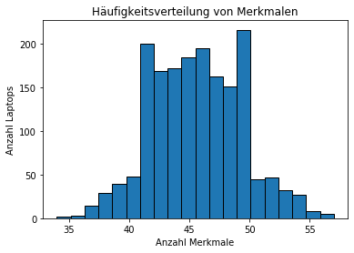

```python
df['Anzahl_Merkmale'] = df.apply(lambda x: x.count(), axis=1)
df_hist = plt.hist(df.Anzahl_Merkmale, bins= 20, edgecolor="black")
plt.title("Häufigkeitsverteilung von Merkmalen")
plt.ylabel("Anzahl Laptops")
plt.xlabel("Anzahl Merkmale")
plt.savefig("hfgt_merkmale_datenset_alt");
```

Im Durchschnitt besitzt ein Merkmalsträger Informationen zu rund 46 Merkmalen:

```python
df.Anzahl_Merkmale.mean()
```

```
45.64779874213836
```

## Der bearbeitete Datensatz

Zurück zu Deskriptive Statistik

```python
df = pd.read_csv('edited_laptops.csv', encoding='cp1252')
pd.options.display.max_columns = None
```

```python
df
```

|  | Laptop_ID | Preis | Bezeichnung-Prozessor | Anzahl-Prozessorkerne-Prozessor | Taktfrequenz-Prozessor | Gesamt-Kapazität-Arbeitsspeicher | Typ-Arbeitsspeicher | Bild-Display | Auflösung-Display | Typ-Grafik | Gesamt-Speicher-Grafik | Anzahl-Datenspeicher | Typ-Optisches Laufwerk | Lautsprecher-Sound | Mikrofon-Sound | Tastatur-Beleuchtung | Betriebssystem | extern-Schnittstellen | URL | Fingerabdrucksensor-Eingabe | Touchscreen-Eingabe | Mobilefunk Standards-Konnektivität | NFC-Konnektivität | HDD-Kapazität | HDD-Anzahl | SSD-Kapazität | SSD-Anzahl | EMMC-Kapazität | EMMC-Anzahl | … |
| --- | --- | --- | --- | --- | --- | --- | --- | --- | --- | --- | --- | --- | --- | --- | --- | --- | --- | --- | --- | --- | --- | --- | --- | --- | --- | --- | --- | --- | --- | --- |
| 0 | 1 | 1699.0 | Intel® Core™ i7-8750H | 6 | 2200 | 16 | DDR 4 | 15.6 | 1.920 x 1.080 Pixel | NVIDIA GeForce GTX 1070 | 8192 | 1 | nicht vorhanden | STANDARD LAUTSPRECHER | vorhanden | vorhanden | DOS | 9 | https://www.alternate.de/MSI/GS65-8RF-078-Stealth-Thin-Notebook/html/product/1433639? | nicht vorhanden | nicht vorhanden | nicht vorhanden | nicht vorhanden | 0 | 0 | 512 | 1 | 0 | 0 | … |
| 1 | 2 | 299.0 | AMD Ryzen 3 3200U | 2 | 2600 | 8 | DDR 4 | 15.6 | 1.920 x 1.080 Pixel | AMD Radeon RX Vega 3 | 0 | 1 | VORHANDEN | STANDARD LAUTSPRECHER | vorhanden | nicht vorhanden | OHNE BETRIEBSSYSTEM | 6 | https://www.alternate.de/HP/15-db1224ng-Notebook/html/product/1556331? | nicht vorhanden | nicht vorhanden | nicht vorhanden | nicht vorhanden | 0 | 0 | 256 | 1 | 0 | 0 | … |
| ... | ... | ... | ... | ... | ... | ... | ... | ... | ... | ... | ... | ... | ... | ... | ... | ... | ... | ... | ... | ... | ... | ... | ... | ... | ... | ... | ... | ... | ... | … |
| 1437 | 1747 | 949.0 | Intel® Core™ i5-8300H | 4 | 2300 | 8 | DDR 4 | 15.6 | 1.920 x 1.080 Pixel | NVIDIA GeForce GTX 1050 | 4096 | 2 | nicht vorhanden | STANDARD LAUTSPRECHER | vorhanden | vorhanden | WINDOWS | 7 | https://www.alternate.de/Acer/Nitro-5-(AN515-52-53TW)-Notebook/html/product/1509168? | nicht vorhanden | nicht vorhanden | nicht vorhanden | nicht vorhanden | 1000 | 1 | 128 | 1 | 0 | 0 | … |
| 1438 | 1748 | 1299.0 | AMD Ryzen 7 3750H | 4 | 2300 | 16 | DDR 4 | 15.6 | 1.920 x 1.080 Pixel | NVIDIA GeForce RTX 2060 | 6144 | 1 | nicht vorhanden | STANDARD LAUTSPRECHER | vorhanden | vorhanden | WINDOWS | 6 | https://www.alternate.de/ASUS/TUF-Gaming-(FX505DV-BQ016T)-Notebook/html/product/1566407? | nicht vorhanden | nicht vorhanden | nicht vorhanden | nicht vorhanden | 0 | 0 | 512 | 1 | 0 | 0 | … |

1439 rows × 37 columns

die automatisch generierten Namen der Merkmale werden umbenannt:

```python
df.columns = df.columns.str.replace("-", "_")
df = df.rename(columns={"Bezeichnung_Prozessor":"Prozessor",
                        "Anzahl_Prozessorkerne_Prozessor":"Kerne",
                        "Taktfrequenz_Prozessor": "Takt_Prozessor",
                        "Gesamt_Kapazität_Arbeitsspeicher": "Arbeitsspeicher",
                        "SSD_Kapazität":"SSD",
                        "HDD_Kapazität":"HDD",
                        "Typ_Optisches Laufwerk": "Laufwerk",
                        "Gesamt_Speicher_Grafik": "Speicher_Grafik",
                        "Lautsprecher_Sound":"Lautsprecher",
                        "Fingerabdrucksensor_Eingabe": "Fingerabdrucksensor",
                        "Touchscreen_Eingabe": "Touchscreen",
                        "Mobilefunk Standards_Konnektivität": "Mobilfunk",
                        "NFC_Konnektivität": "NFC",})
```

Im bearbeiteten Datensatz kommen vier Merkmale vor, zu denen Angaben fehlen, alle anderen Variablen kamen 1439 mal vor:

```python
df_anzahl = df.count().rename_axis('Merkmale').reset_index(name='Anzahl').sort_values(["Anzahl"], ascending=False)
# Die letzten 5 Merkmale mit den wenigsten Ausprägungen
df_anzahl.tail(5)
```

|  | Merkmale | Anzahl |
| --- | --- | --- |
| 14 | Mikrofon_Sound | 1439 |
| 35 | Modell | 1401 |
| 36 | Pixelshader | 1401 |
| 29 | Akku_Typ | 1294 |
| 30 | Akku_Kapazität | 1294 |

## Der berarbeitete Datensatz ohne fehlende Werte

Zurück zu Deskriptive Statistik

Anzahl an Observationen, wenn fehlende Merkmale ausgeschlossen werden:

```python
df_neu = df.dropna()
del df
df_neu.set_index("Laptop_ID", inplace=True)
print(len(df_neu))
```

```
1260
```

Anzahl an Observationen, wenn Duplikate ausgeschlossen werden:

```python
exogene_var = list(set(df_neu.columns) - set(["Laptop_ID", "Preis", "URL"]))
df_neu_exogen = df_neu[exogene_var]
```

```python
df_neu_exogen.drop_duplicates()
len(df_neu_exogen)
```

```
1260
```

Es sind also keine Duplikate im Datenset, die Anzahl beträgt auch nach Löschen der Duplikate 1260

Alle Merkmale haben dieselbe Anzahl:

```python
df_anzahl_neu = df_neu.count().rename_axis('Merkmale').reset_index(name='Anzahl').sort_values(["Anzahl"], ascending=False)
df_anzahl_neu
```

|  | Merkmale | Anzahl |
| --- | --- | --- |
| 0 | Preis | 1260 |
| 1 | Prozessor | 1260 |
| ... | ... | ... |
| 15 | Betriebssystem | 1260 |
| 35 | Pixelshader | 1260 |

36 rows × 2 columns

### Löschen einiger Merkmale und Merkmalsausprägungen

Zurück zu Deskriptive Statistik

Typ-Grafik und Modell entsprechen einander. Die Merkmale _Prozessor, Auflösung_Display, Typ*Grafik* und *Modell* sind die einzigen String-Variablen, die nicht als Dummy-Variablen dargestellt werden sollen und jeweils andere Merkmale haben, die den Zusammenhang zu dem entsprechenden Preis besser erkären und werden deshalb gelöscht:

```python
pd.set_option('display.max_colwidth', -1)
df_neu[["Prozessor", "Auflösung_Display", "Typ_Grafik", "Modell", "URL"]].head(4)
```

| Laptop_ID | Prozessor | Auflösung_Display | Typ_Grafik | Modell | URL |
| --- | --- | --- | --- | --- | --- |
| 1 | Intel® Core™ i7-8750H | 1.920 x 1.080 Pixel | NVIDIA GeForce GTX 1070 | NVIDIA GeForce GTX 1070 (Laptop) | https://www.alternate.de/MSI/GS65-8RF-078-Stealth-Thin-Notebook/html/product/1433639? |
| 2 | AMD Ryzen 3 3200U | 1.920 x 1.080 Pixel | AMD Radeon RX Vega 3 | AMD Radeon RX Vega 3 | https://www.alternate.de/HP/15-db1224ng-Notebook/html/product/1556331? |
| 3 | Intel® Core™ i7-8750H | 1.920 x 1.080 Pixel | NVIDIA GeForce GTX 1060 | NVIDIA GeForce GTX 1060 (Laptop) | https://www.alternate.de/Razer/Blade-15-Dual-Storage-(RZ09-02705G75-R3G1)-Notebook/html/product/1493919? |
| 4 | Intel® Core™ i7-8750H | 1.920 x 1.080 Pixel | NVIDIA GeForce GTX 1060 | NVIDIA GeForce GTX 1060 (Laptop) | https://www.alternate.de/OMEN-by-HP/15-dc0003ng-Notebook/html/product/1462417? |

```python
df_neu = df_neu.drop(["Prozessor", "Auflösung_Display", "Typ_Grafik", "Modell"], axis = 1)
```

Das gekürzte Datenset besteht nur aus neuen Laptops, das Merkmal Zustand wird deshalb ebenfalls gelöscht:

```python
print("Zustand:\n", df_neu.Zustand.value_counts())
df_neu = df_neu.drop("Zustand", axis= 1);
```

```
Zustand:
 neu    1260
Name: Zustand, dtype: int64
```

die Anzahl der Datenspeicher setzt sich aus der Summe von Anzahl an SSDs und HDDs zusammen. Da ein grundlegender Unterschied zwischen diesen beiden Festplattentypen sollte, wird dieses Merkmal ebenfalls gelöscht

```python
df_neu[["Anzahl_Datenspeicher", "HDD_Anzahl", "SSD_Anzahl", "EMMC_Anzahl"]].head(5)
```

| Laptop_ID | Anzahl_Datenspeicher | HDD_Anzahl | SSD_Anzahl | EMMC_Anzahl |
| --- | --- | --- | --- | --- |
| 1 | 1 | 0 | 1 | 0 |
| 2 | 1 | 0 | 1 | 0 |
| 3 | 2 | 1 | 1 | 0 |
| 4 | 2 | 1 | 1 | 0 |
| 5 | 1 | 0 | 1 | 0 |

```python
df_neu = df_neu.drop("Anzahl_Datenspeicher", axis=1);
```

Einzelne Marken sind selten vertreten im Datenset und werden ebenfalls gelöscht. Die Wahl fiehl dabei auf die sechs größten Marken gemessen an ihrem Marktanteil. Marken, die weniger als 44 mal vertreten waren wurden deshalb gelöscht:

```python
Anzahl_Marke = df_neu.groupby(["Marke"], as_index=False).size().to_frame("Anzahl").reset_index(level=0)
Liste = Anzahl_Marke[Anzahl_Marke.Anzahl < 44]
for Markealt in Liste.Marke:
    print("Laptops mit der Marke",Markealt, "werden gelöscht")
    df_neu = df_neu[df_neu["Marke"] != Markealt]
```

```
Laptops mit der Marke ALTERNATE werden gelöscht
Laptops mit der Marke AORUS werden gelöscht
Laptops mit der Marke Alienware werden gelöscht
Laptops mit der Marke Fujitsu werden gelöscht
Laptops mit der Marke GIGABYTE werden gelöscht
Laptops mit der Marke Huawei werden gelöscht
Laptops mit der Marke MSI werden gelöscht
Laptops mit der Marke Razer werden gelöscht
Laptops mit der Marke Schenker werden gelöscht
Laptops mit der Marke TrekStor werden gelöscht
Laptops mit der Marke XMG werden gelöscht
```

Anzahl an Observationen nach Löschen der Marken:

```python
len(df_neu)
```

```
1084
```

Laptops die eine eMMC Speicherkarte haben, werden gelöscht (35 Observationen):

```python
df_neu = df_neu[df_neu.EMMC_Kapazität == 0]
del df_neu["EMMC_Kapazität"]
del df_neu["EMMC_Anzahl"]
len(df_neu)
```

```
1049
```

Es werden nur Laptops bis einschließlich 4000 Euro betrachtet. Die Wahl von 4000 Euro war dabei recht willkürlich, aber als runde Zahl ansehnlicher

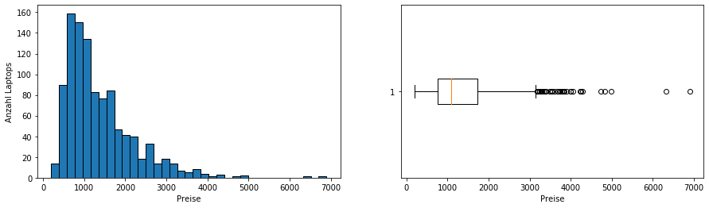

```python
plt.subplot(1,2,1)
plt.hist(df_neu.Preis, bins = 35, edgecolor="black")
plt.ylabel("Anzahl Laptops")
plt.xlabel("Preise")
plt.subplot(1,2,2)
plt.xlabel("Preise")
plt.gcf().set_size_inches(15, 4, forward=True)
plt.boxplot(df_neu.Preis, vert = False, showbox = True);
#plt.yticks(None)
plt.ylabel(None)
plt.savefig("hfgkt_preisspanne_ungekürzt");
```

Laptops über 4000 Euro werden aus der Analyse ausgeschlossen, der neue Datensatz erneut gespeichert:

```python
df_neu = df_neu[df_neu.Preis<=4000]
df_neu.to_json(r'analysierte merkmale.json')
df_neu.to_json(r'C:\Users\tobia\PycharmProjects\Alternate\analysierte merkmale.json')
len(df_neu)
```

```
1040
```

### Klassieren in Preisspannen

Zurück zu Deskriptive Statistik

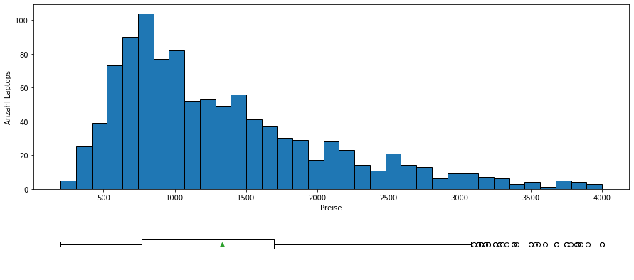

```python
fig, (ax1, ax2) =plt.subplots(2,1, figsize= (15,7),gridspec_kw={'height_ratios': [3, 1]})
ax1.hist(df_neu.Preis, bins = 35, edgecolor="black")
ax1.set_ylabel("Anzahl Laptops")
ax1.set_xlabel("Preise")
ax2.boxplot(df_neu.Preis, vert=False, showmeans= True)
ax2.axis("off")

plt.savefig("hfgkt_preisspanne_gekürzt");
```

75% Quantil des Preises:

```python
df_neu.Preis.quantile(q=0.75)
```

```
1699.0
```

Durchschnittspreis:

```python
df_neu.Preis.mean()
```

```
1334.2133846153847
```

Die Laptops werden in Preisklassen unterteilt:

```python
Unterteilung_Preis = np.linspace(0, 4000, 17).astype(int)
Klassenbreite = [(b-a)/250 for a, b in zip(Unterteilung_Preis.tolist()[:-1], Unterteilung_Preis.tolist()[1:])]
Index = [((b-a)/2+a)/250 for a, b in zip(Unterteilung_Preis.tolist()[:-1], Unterteilung_Preis.tolist()[1:])]
df_neu["Preisspanne"] = pd.cut(df_neu["Preis"], Unterteilung_Preis)
Kathegorien = df_neu["Preisspanne"].cat.categories
```

Graphische Darstellung der Preisklassen:

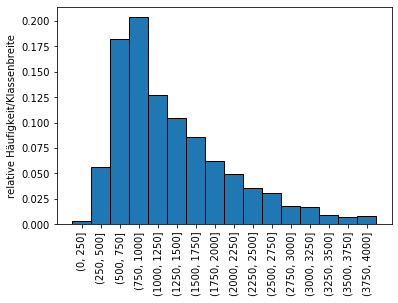

```python
gruppenhäufigkeit = df_neu.groupby("Preisspanne").size()
relative_gruppenhäufigkeit = (gruppenhäufigkeit/len(df_neu))/Klassenbreite
plt.bar(Index, relative_gruppenhäufigkeit, edgecolor="black", width=Klassenbreite)
plt.ylabel("relative Häufigkeit/Klassenbreite")
plt.xticks(Index, Kathegorien, rotation = 90);
```

### qualitative Merkmale

Zurück zu Deskriptive Statistik

die ersten zwei Ausprägungen des Datensatzes:

```python
df_neu.head(2)
```

| Laptop_ID | Preis | Kerne | Takt_Prozessor | Arbeitsspeicher | Typ_Arbeitsspeicher | Bild_Display | Speicher_Grafik | Laufwerk | Lautsprecher | Mikrofon_Sound | Tastatur_Beleuchtung | Betriebssystem | extern_Schnittstellen | URL | Fingerabdrucksensor | Touchscreen | Mobilfunk | NFC | HDD | HDD_Anzahl | SSD | SSD_Anzahl | Akku_Typ | Akku_Kapazität | Marke | Rabatt_Lehreinrichtung | PPI_Display | Pixelshader | Preisspanne |
| --- | --- | --- | --- | --- | --- | --- | --- | --- | --- | --- | --- | --- | --- | --- | --- | --- | --- | --- | --- | --- | --- | --- | --- | --- | --- | --- | --- | --- | --- |
| 2 | 299.0 | 2 | 2600 | 8 | DDR 4 | 15.6 | 0 | VORHANDEN | STANDARD LAUTSPRECHER | vorhanden | nicht vorhanden | OHNE BETRIEBSSYSTEM | 6 | https://www.alternate.de/HP/15-db1224ng-Notebook/html/product/1556331? | nicht vorhanden | nicht vorhanden | nicht vorhanden | nicht vorhanden | 0 | 0 | 256 | 1 | ION | 41.0 | HP | nicht vorhanden | 141 | 192.0 | (250, 500] |
| 4 | 899.0 | 6 | 2200 | 8 | DDR 4 | 15.6 | 6144 | nicht vorhanden | STANDARD LAUTSPRECHER | vorhanden | vorhanden | WINDOWS | 9 | https://www.alternate.de/OMEN-by-HP/15-dc0003ng-Notebook/html/product/1462417? | nicht vorhanden | nicht vorhanden | nicht vorhanden | nicht vorhanden | 1000 | 1 | 128 | 1 | ION | 70.0 | HP | nicht vorhanden | 141 | 1280.0 | (750, 1000] |

Die qualitativen Merkmale sind noch in ihrer ursprünglichen Form:

```python
df_neu[["Typ_Arbeitsspeicher", "Laufwerk", "Lautsprecher", "Tastatur_Beleuchtung", "Betriebssystem",
        "Fingerabdrucksensor", "Touchscreen"]].head(2)
```

| Laptop_ID | Typ_Arbeitsspeicher | Laufwerk | Lautsprecher | Tastatur_Beleuchtung | Betriebssystem | Fingerabdrucksensor | Touchscreen |
| --- | --- | --- | --- | --- | --- | --- | --- |
| 2 | DDR 4 | VORHANDEN | STANDARD LAUTSPRECHER | nicht vorhanden | OHNE BETRIEBSSYSTEM | nicht vorhanden | nicht vorhanden |
| 4 | DDR 4 | nicht vorhanden | STANDARD LAUTSPRECHER | vorhanden | WINDOWS | nicht vorhanden | nicht vorhanden |

Also müssen Dummy-Variablen erstellt werden, was mit dem Befehl _pandas.get*dummies()* möglich ist:

```python
binäre_variablen = pd.get_dummies(df_neu[["Typ_Arbeitsspeicher", "Laufwerk", "Lautsprecher", "Tastatur_Beleuchtung",
                     "Fingerabdrucksensor", "Touchscreen", "Mobilfunk", "NFC",
                     "Akku_Typ", "Marke", "Betriebssystem", "Mikrofon_Sound", "Rabatt_Lehreinrichtung"]])
```

Zur graphischen Darstellung wird der Datensatz der qualitativen Merkmale um den Preis und die Preisspanne erweitert:

```python
binäre_variablen["Preis"] = df_neu["Preis"]
binäre_variablen["Preisspanne"] = df_neu["Preisspanne"]
Merkmale = binäre_variablen.columns.tolist()
Merkmale = Merkmale[-1:] + Merkmale[:-1]
binäre_variablen = binäre_variablen[Merkmale]
```

```python
binäre_variablen.head(2)
```

| Laptop_ID | Preisspanne | Typ_Arbeitsspeicher_DDR 3 | Typ_Arbeitsspeicher_DDR 4 | Laufwerk_VORHANDEN | Laufwerk_nicht vorhanden | Lautsprecher_STANDARD LAUTSPRECHER | Lautsprecher_ÜBERDURCHSCHN LAUTSPRECHER | Tastatur_Beleuchtung_nicht vorhanden | Tastatur_Beleuchtung_vorhanden | Fingerabdrucksensor_nicht vorhanden | Fingerabdrucksensor_vorhanden | Touchscreen_nicht vorhanden | Touchscreen_vorhanden | Mobilfunk_nicht vorhanden | Mobilfunk_vorhanden | NFC_nicht vorhanden | NFC_vorhanden | Akku_Typ_ION | Akku_Typ_POLYMER | Marke_ASUS | Marke_Acer | Marke_Apple | Marke_Dell | Marke_HP | Marke_Lenovo | Betriebssystem_DOS | Betriebssystem_LINUX | Betriebssystem_MAC | Betriebssystem_OHNE BETRIEBSSYSTEM | … |
| --- | --- | --- | --- | --- | --- | --- | --- | --- | --- | --- | --- | --- | --- | --- | --- | --- | --- | --- | --- | --- | --- | --- | --- | --- | --- | --- | --- | --- | --- | --- |
| 2 | (250, 500] | 0 | 1 | 1 | 0 | 1 | 0 | 1 | 0 | 1 | 0 | 1 | 0 | 1 | 0 | 1 | 0 | 1 | 0 | 0 | 0 | 0 | 0 | 1 | 0 | 0 | 0 | 0 | 1 | … |
| 4 | (750, 1000] | 0 | 1 | 0 | 1 | 1 | 0 | 0 | 1 | 1 | 0 | 1 | 0 | 1 | 0 | 1 | 0 | 1 | 0 | 0 | 0 | 0 | 0 | 1 | 0 | 0 | 0 | 0 | 0 | … |

Häufig befinden sich Leerzeichen im Namen der durch _get*dummies* generierten Merkmale, welche ersetzt werden durch "_":

```python
for Merkmal in Merkmale:
    binäre_variablen.columns = binäre_variablen.columns.str.replace(" ", "_")
binäre_variablen.head(2)
```

| Laptop_ID | Preisspanne | Typ_Arbeitsspeicher_DDR_3 | Typ_Arbeitsspeicher_DDR_4 | Laufwerk_VORHANDEN | Laufwerk_nicht_vorhanden | Lautsprecher_STANDARD_LAUTSPRECHER | Lautsprecher_ÜBERDURCHSCHN_LAUTSPRECHER | Tastatur_Beleuchtung_nicht_vorhanden | Tastatur_Beleuchtung_vorhanden | Fingerabdrucksensor_nicht_vorhanden | Fingerabdrucksensor_vorhanden | Touchscreen_nicht_vorhanden | Touchscreen_vorhanden | Mobilfunk_nicht_vorhanden | Mobilfunk_vorhanden | NFC_nicht_vorhanden | NFC_vorhanden | Akku_Typ_ION | Akku_Typ_POLYMER | Marke_ASUS | Marke_Acer | Marke_Apple | Marke_Dell | Marke_HP | Marke_Lenovo | Betriebssystem_DOS | Betriebssystem_LINUX | Betriebssystem_MAC | Betriebssystem_OHNE_BETRIEBSSYSTEM | … |
| --- | --- | --- | --- | --- | --- | --- | --- | --- | --- | --- | --- | --- | --- | --- | --- | --- | --- | --- | --- | --- | --- | --- | --- | --- | --- | --- | --- | --- | --- | --- |
| 2 | (250, 500] | 0 | 1 | 1 | 0 | 1 | 0 | 1 | 0 | 1 | 0 | 1 | 0 | 1 | 0 | 1 | 0 | 1 | 0 | 0 | 0 | 0 | 0 | 1 | 0 | 0 | 0 | 0 | 1 | … |
| 4 | (750, 1000] | 0 | 1 | 0 | 1 | 1 | 0 | 0 | 1 | 1 | 0 | 1 | 0 | 1 | 0 | 1 | 0 | 1 | 0 | 0 | 0 | 0 | 0 | 1 | 0 | 0 | 0 | 0 | 0 | … |

### Qualitative Merkmale mit mehr als zwei Ausprägungen

Zurück zu Deskriptive Statistik

Im bearbeiteten Datensatz gibt es zwei Merkmale mit mehr als zwei Ausprägungen.

1. Marke
2. Betriebssystem

Standard-Graph für Marke und Betriebssystem:

```python
def gestapelt_balken(titel, zweite_gruppe, reihenfolge,farbe, klassieren=False, gegeben=False, ax=None):
    unterklasse = df_neu.groupby(["Preisspanne", zweite_gruppe]).size().to_frame("Anzahl")
    fnl = unterklasse.pivot_table("Anzahl", ["Preisspanne"], zweite_gruppe)
    fnl = fnl.fillna(0).rename_axis(None).rename_axis("Preisspanne", axis=1)
    fnl["Andere"] = 0
    if klassieren:
        for column in fnl:
            if fnl[column].sum()<43:
                fnl["Andere"] += fnl[column]
                del fnl[column]
    if gegeben:
        fnl = fnl[reihenfolge]
    graph =fnl.plot.bar(stacked= True, width=1, ax=ax, colormap= farbe, edgecolor= "black", legend= True, title=titel)
    ax.set_title(titel, fontsize=14)
    patches, labels = graph.get_legend_handles_labels()
    ax.legend(patches, labels, loc='best')
    ax.set_ylabel("Anzahl Laptops")
    ax.set_xlabel("Preisklasse")
```

Jeder Marke wird eine Farbe zugewiesen:

```python
cm = ["#96D65E", "#5B995A", "#F8F17F", "#F3A800", "#824026", "#431F07"]
#print(plt.rcParams['axes.prop_cycle'].by_key()['color'])
farben = colors.ListedColormap(cm)
df_neu.loc[df_neu.Marke == "ASUS", "Farbe"] = "#96D65E"
df_neu.loc[df_neu.Marke == "Acer", "Farbe"] = "#5B995A"
df_neu.loc[df_neu.Marke =="Apple", "Farbe"] = "#F8F17F"
df_neu.loc[df_neu.Marke == "Dell", "Farbe"] = "#F3A800"
df_neu.loc[df_neu.Marke == "HP", "Farbe"] = "#824026"
df_neu.loc[df_neu.Marke == "Lenovo", "Farbe"] = "#431F07"
```

Übersicht Betriebssystem:

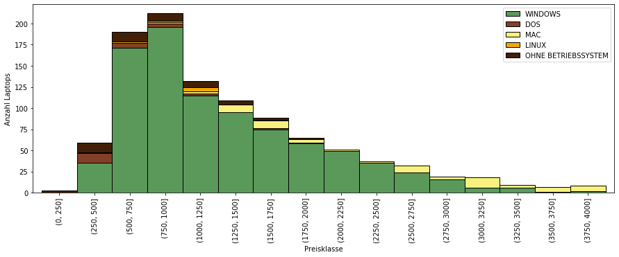

```python
fig, ax = plt.subplots(1,1, figsize=(15,5))
gestapelt_balken(None, "Betriebssystem",
                 ["WINDOWS", "DOS", "MAC", "LINUX", "OHNE BETRIEBSSYSTEM"],
                 colors.ListedColormap([cm[i] for i in (1,4,2,3,5)]), False, True, ax=ax)
plt.savefig("betriebssystem_in_preiskl", bbox_inches = "tight")
```

```python
for sstm in df_neu.Betriebssystem.unique().tolist():
    print("Durchschnittlicher Preis für das Betriebssystem", sstm, ":", df_neu[df_neu.Betriebssystem == sstm].Preis.mean())
```

```
Durchschnittlicher Preis für das Betriebssystem OHNE BETRIEBSSYSTEM : 859.3294117647059
Durchschnittlicher Preis für das Betriebssystem WINDOWS : 1295.1483257918553
Durchschnittlicher Preis für das Betriebssystem DOS : 699.5769230769231
Durchschnittlicher Preis für das Betriebssystem LINUX : 984.5
Durchschnittlicher Preis für das Betriebssystem MAC : 2475.521739130435
```

Übersicht Marke:

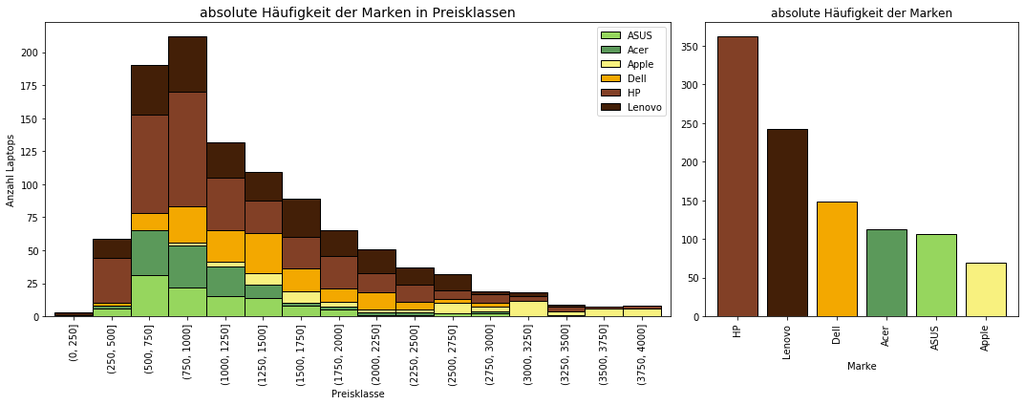

```python
fig, (ax1, ax2) = plt.subplots(1,2,figsize=(15,6),gridspec_kw={'width_ratios': [2, 1]})
gestapelt_balken("absolute Häufigkeit der Marken in Preisklassen", "Marke", [], farben, klassieren=True, ax=ax1)
df_neu.groupby(["Marke"])
bar = df_neu.groupby(["Marke"]).size().sort_values(ascending=False)
farbe = [x for _,x in sorted(zip(df_neu.groupby(["Marke"]).size(),mp.cm.get_cmap(farben)(np.linspace(0,1,6))))][::-1]
bar.plot.bar(ax=ax2, title="absolute Häufigkeit der Marken", width=0.8, edgecolor="black", color =farbe)
plt.tight_layout()
plt.savefig("marke_in_preiskl_mit_bar")
```

```python
for Marke in df_neu.Marke.unique().tolist():
    print("Durchschnittlicher Preis für die Marke", Marke, ":", df_neu[df_neu.Marke == Marke].Preis.mean())
```

```
Durchschnittlicher Preis für die Marke HP : 1222.4856077348068
Durchschnittlicher Preis für die Marke ASUS : 1088.018691588785
Durchschnittlicher Preis für die Marke Acer : 1035.2083035714286
Durchschnittlicher Preis für die Marke Lenovo : 1377.9247933884296
Durchschnittlicher Preis für die Marke Dell : 1408.1891891891892
Durchschnittlicher Preis für die Marke Apple : 2475.521739130435
```

### Qualtiative Merkmale mit zwei Ausprägungen

Zurück zu Deskriptive Statistik

Im Datenset gibt es 11 qualitative Merkmale mit zwei Ausprägungen:

1. Tastatur Beleuchtung
2. Fingerabdrucksensor
3. Typ-Arbeitsspeicher
4. Tochscreen
5. Lautsprecher
6. Laufwerk
7. Mobilfunk
8. NFC
9. Akku-Typ
10. Mikrofon-Sound
11. Rabatt-Lehreinrichtung

Es wurde ebenfalls eine Grafik erstellt, die Informationen für sämtliche qualitative Merkmale mit zwei Ausprägungen beinhaltet. Da sich allerdings bereits eine Reihe anderer Graphen in der Arbeit befanden und die Arbeit ansonsten mit Graphen überladen worden wäre, wurde diese Art von Graphen nicht in der Arbeit berücksichtigt. Exemplarisch sind untenstehend zwei solcher Graphen abgebildet:

```python
def standard_bar(Überschrift, ylim, y_variable1, y_variable2, zeilen=1, spalten=2, position=1, gegeben=False):
    y = binäre_variablen.groupby("Preisspanne")[y_variable1].mean()

    plot1 = plt.subplot(zeilen, spalten, position)
    plt.title(Überschrift)
    plt.ylabel("relative Häufigkeit")
    plt.xlabel("Preisklasse")
    plt.ylim(0,ylim)
    Graph = plt.bar(Index, y, edgecolor="black", width=Klassenbreite)
    plt.xticks(Index, Kathegorien, rotation = 90)
    if gegeben:
        plt.xticks([])
        plt.xlabel("")

    plot2 = plt.subplot(zeilen, spalten, position+1)
    Ausprägung = "".join(y_variable1.rsplit(y_variable2)).lstrip("_").replace("_", " ")
    y_nicht_sortiert = df_neu[df_neu[y_variable2]==Ausprägung].groupby("Marke").size()/df_neu.groupby("Marke").size().dropna()
    y = y_nicht_sortiert.sort_values(ascending=False)
    cm = []
    for Marke in y.index:
        cm.append(df_neu[df_neu.Marke == Marke].Farbe.unique().tolist()[0])
    farbe = colors.ListedColormap(cm)
    farbe = mp.cm.get_cmap(farbe)(np.linspace(0,1,len(cm)))
    y.plot(kind="barh", title=Überschrift+" (relative Häufigkeit bei Marken)", width=0.8, edgecolor="black", color=farbe)
    plt.ylabel("")
    plt.xlabel("relative Häufigkeit")
    plt.tight_layout()
```

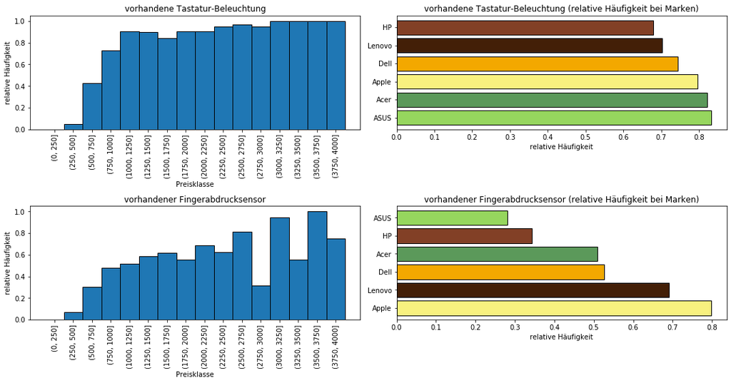

```python
plt.gcf().set_size_inches(15, 30, forward=True)
standard_bar("vorhandene Tastatur-Beleuchtung",1.05,"Tastatur_Beleuchtung_vorhanden", "Tastatur_Beleuchtung",8,2,1, False)
standard_bar("vorhandener Fingerabdrucksensor", 1.05, "Fingerabdrucksensor_vorhanden", "Fingerabdrucksensor",8,2,3, False)
```

Durchschnittliche Preise und Anzahl:

```python
for Merkmal in ["Typ_Arbeitsspeicher", "Laufwerk", "Lautsprecher", "Tastatur_Beleuchtung", "Fingerabdrucksensor", "Touchscreen", "Mobilfunk", "NFC", "Akku_Typ","Mikrofon_Sound", "Rabatt_Lehreinrichtung"]:
    for Ausprägung in df_neu[Merkmal].unique():
        print(Merkmal.ljust(22, "-"), Ausprägung.ljust(26, "-"), "Preis:", str(round(df_neu[df_neu[Merkmal] == Ausprägung].Preis.mean(), 2)).ljust(9, "-"), "Anzahl:", df_neu[df_neu[Merkmal] == Ausprägung].Preis.count())
    print()
```

```
Typ_Arbeitsspeicher--- DDR 4--------------------- Preis: 1306.36-- Anzahl: 915
Typ_Arbeitsspeicher--- DDR 3--------------------- Preis: 1538.1--- Anzahl: 125

Laufwerk-------------- VORHANDEN----------------- Preis: 673.75--- Anzahl: 112
Laufwerk-------------- nicht vorhanden----------- Preis: 1413.92-- Anzahl: 928

Lautsprecher---------- STANDARD LAUTSPRECHER----- Preis: 1304.13-- Anzahl: 984
Lautsprecher---------- ÜBERDURCHSCHN LAUTSPRECHER Preis: 1862.75-- Anzahl: 56

Tastatur_Beleuchtung-- nicht vorhanden----------- Preis: 822.82--- Anzahl: 278
Tastatur_Beleuchtung-- vorhanden----------------- Preis: 1520.78-- Anzahl: 762

Fingerabdrucksensor--- nicht vorhanden----------- Preis: 1132.18-- Anzahl: 529
Fingerabdrucksensor--- vorhanden----------------- Preis: 1543.36-- Anzahl: 511

Touchscreen----------- nicht vorhanden----------- Preis: 1307.43-- Anzahl: 843
Touchscreen----------- vorhanden----------------- Preis: 1448.84-- Anzahl: 197

Mobilfunk------------- nicht vorhanden----------- Preis: 1294.85-- Anzahl: 956
Mobilfunk------------- vorhanden----------------- Preis: 1782.21-- Anzahl: 84

NFC------------------- nicht vorhanden----------- Preis: 1309.31-- Anzahl: 1013
NFC------------------- vorhanden----------------- Preis: 2268.63-- Anzahl: 27

Akku_Typ-------------- ION----------------------- Preis: 1173.52-- Anzahl: 816
Akku_Typ-------------- POLYMER------------------- Preis: 1919.61-- Anzahl: 224

Mikrofon_Sound-------- vorhanden----------------- Preis: 1329.09-- Anzahl: 853
Mikrofon_Sound-------- nicht vorhanden----------- Preis: 1357.59-- Anzahl: 187

Rabatt_Lehreinrichtung nicht vorhanden----------- Preis: 1336.16-- Anzahl: 1005
Rabatt_Lehreinrichtung vorhanden----------------- Preis: 1278.43-- Anzahl: 35
```

### quantitative Merkmale

Zurück zu Deskriptive Statistik

Das Datenset beinhalten 11 quantitative Merkmale

1. Kerne
2. Takt_Prozessor
3. Arbeitsspeicher
4. Bild_Display
5. Speicher_Grafik
6. extern_Schnittstellen
7. HDD
8. SSD
9. Akku_Kapazität
10. PPI_Display
11. Pixelshader

Der untenstehende Graph bietet eine grobe Übersicht über den Zusammenhang zwischen den Preisen und Ausprägungen der Eigenschaften:

```python
def standard_scatter(position, titel, x_variable, y_variable= df_neu.Preis, ylabel= "Preis", x=5, y=3, gegeben=False):
    plt.subplot(x, y, position)
    if gegeben:
        plt.ylabel(ylabel)
    plt.xlabel(titel)
    Graph = plt.scatter(x_variable, y_variable, alpha= 0.5, edgecolors="black")
```

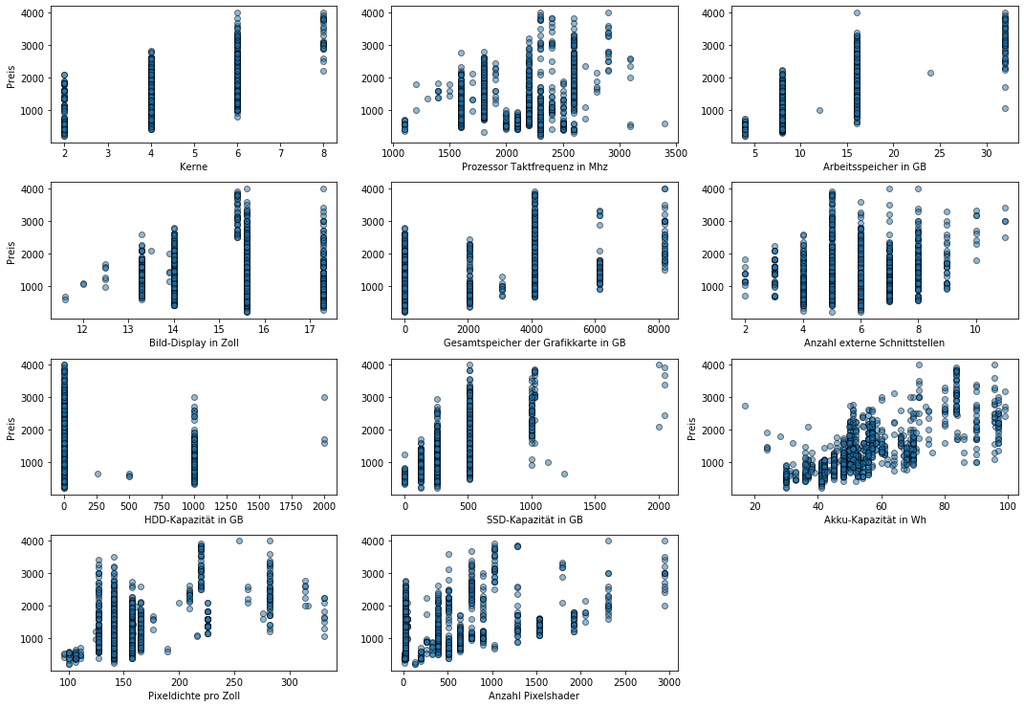

```python
plt.gcf().set_size_inches(15, 12.5, forward=True)
standard_scatter(1, "Kerne", df_neu.Kerne, gegeben=True)
standard_scatter(2, "Prozessor Taktfrequenz in Mhz", df_neu.Takt_Prozessor)
standard_scatter(3, "Arbeitsspeicher in GB", df_neu.Arbeitsspeicher)
standard_scatter(4, "Bild-Display in Zoll", df_neu["Bild_Display"], gegeben=True)
standard_scatter(5, "Gesamtspeicher der Grafikkarte in GB", df_neu["Speicher_Grafik"])
standard_scatter(6, "Anzahl externe Schnittstellen", df_neu["extern_Schnittstellen"])
standard_scatter(7, "HDD-Kapazität in GB", df_neu["HDD"], gegeben=True)
standard_scatter(8, "SSD-Kapazität in GB", df_neu["SSD"])
standard_scatter(9, "Akku-Kapazität in Wh", df_neu["Akku_Kapazität"], gegeben=True)
standard_scatter(10, "Pixeldichte pro Zoll", df_neu["PPI_Display"])
standard_scatter(11, "Anzahl Pixelshader", df_neu["Pixelshader"])
plt.tight_layout()
plt.savefig("grobe_übersicht_quantitativ")
```

**Häufigkeitesverteilung der quantiativen Merkmale:**

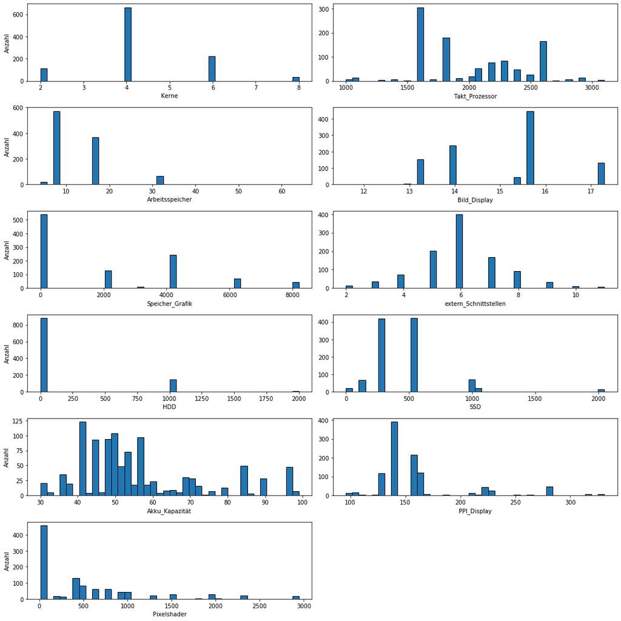

```python
i=0
quant_red = quantitative_variablen[["Kerne", "Takt_Prozessor", "Arbeitsspeicher", "Bild_Display", "Speicher_Grafik", "extern_Schnittstellen",
                "HDD", "SSD", "Akku_Kapazität", "PPI_Display", "Pixelshader"]]
for Merkmal in quant_red:
    i+=1
    plt.gcf().set_size_inches(15,15, forward=True)
    plt.subplot(6, 2, i)
    plt.xlabel(Merkmal)
    plt.hist(quantitative_variablen[Merkmal], edgecolor="black", bins=40)
    if i%2 != 0:
        plt.ylabel("Anzahl")
    plt.tight_layout()
```

### Übersicht nach Komponenten

Zurück zu Deskriptive Statistik

Die Hauptkomponenten der Laptops sind:

1. Speicherkarten
2. Grafikkarte
3. Prozessor
4. Arbeitsspeicher
5. Bildschirm
6. Akku

#### Speicherkarten

Zurück zu Übersicht nach Komponenten

**SSD**

```python
print("HDD-Anzahl bei Laptops mit zwei SSDs\n", df_neu[df_neu["SSD_Anzahl"]== 2]["HDD_Anzahl"].value_counts())
print("\nHDD-Anzahl bei Laptops mit einer SSD\n",df_neu[df_neu["SSD_Anzahl"] == 1]["HDD_Anzahl"].value_counts())
print("\SSD-Anzahl",df_neu["SSD_Anzahl"].value_counts())
```

```
HDD-Anzahl bei Laptops mit zwei SSDs
 0    8
1    1
Name: HDD_Anzahl, dtype: int64

HDD-Anzahl bei Laptops mit einer SSD
 0    832
1    170
Name: HDD_Anzahl, dtype: int64
\SSD-Anzahl 1    1002
0    29
2    9
Name: SSD_Anzahl, dtype: int64
```

```python
def standard_boxplot(regression, axes, label, endog_variable, exog_variablen, Titel="", Balkenbreite=10,
                     Bedingungen=(df_neu.Preis==df_neu.Preis), Klassieren=False, Klassen=False, rotieren=0, yvar = "Preis"):
# unabhängige Variablen werden als Instanz einer Liste gespeichert:
    if not isinstance(exog_variablen, list):
        exog_variablen = [exog_variablen[Bedingungen]]
    else: exog_variablen = [exog_variable[Bedingungen] for exog_variable in exog_variablen]
# Wenn Klassiert werden soll, werden die Abstände aus den Mittelwerten der Klasse berechnet:
    if Klassieren:
        Unterteilung = np.around(np.linspace(exog_variablen[0].min(), exog_variablen[0].max(), Klassen), 1)
        df_neu["Skalierung"] = pd.cut(exog_variablen[0][Bedingungen], Unterteilung)
        Kathegorien = df_neu["Skalierung"].cat.categories
# Mittelpunkte der Klassen:
        Skalierung = df_neu.groupby("Skalierung")[label].mean().tolist()
        plt.xticks(Skalierung, Kathegorien, rotation = 90);
# sind zwei exogene Variablen vorhanden, die untersucht werden sollen, also len(exog_variablen)== 2, wird der zweite Boxplot
# bei einer Distanz von 1.2 Mal der Balkenbreite positioniert:
    else:
        Skalierung = sorted(exog_variablen[0][Bedingungen].unique().tolist());
        if len(exog_variablen) ==2:
            Skalierung = sorted(Skalierung + [Index+1.2*Balkenbreite for Index in Skalierung])
    if regression:
# Für die einzelnen untersuchten Merkmale werden Regressionen durchgeführt:
        for exog_variable in exog_variablen:
            X, y= exog_variable[Bedingungen], endog_variable[Bedingungen];
# Ein quadratischer Term wird miteinbezogen:
            X = pd.concat([X, exog_variable[Bedingungen]**2], axis=1);
# Eine Kostante wird miteinbezogen:
            X = sm.add_constant(X.values);
            fit = sm.OLS(y, X).fit();
            print(fit.rsquared)
            achsenabschn, x1, x2 =str(round(fit.params[0])), str(round(fit.params[1],2)), str(round(fit.params[2],6))
# Die in den Darstellungen abgebildeten Label für die Regeressionskurven werden erstellt:
            graph_label=achsenabschn+"+"+x1+"*"+str(label)+"+"+x2+"*"+str(label)+"^2"
# Die Werte für die die Kurve eingezeichnet werden soll reicht von dem Mittelpunkkt der Klasse mit den kleinsten Werten zu
# dem Mittelpunkt der Klasse mit den größten Werten:
            x1werte = pd.Series(np.arange(Skalierung[0],Skalierung[-1], 0.1))
            regression_xwerte = pd.concat([x1werte, x1werte**2], axis=1)
            regression_xwerte = sm.add_constant(regression_xwerte.values)
            variable, prediction = regression_xwerte, fit.predict(regression_xwerte)
# Regressionskurve wird dargestellt:
            axes.plot(x1werte, prediction, label=graph_label);
            axes.legend();
#Boxplots werden dargestellt:
    if Klassieren: exog_variablen = df_neu.Skalierung[Bedingungen]
    df_neu[Bedingungen].boxplot(column=yvar, widths=Balkenbreite, by=exog_variablen, rot=rotieren,
                        positions=Skalierung, grid=False, ax=axes);
# Wenn die Residuen oder die geschätzen Werte die abhängigen Variablen sind, werden den Plots andere Eigenschaften zugewiesen,
# die Plots kamen allerdings nicht zur Anwendung:
    if "resid" in yvar:
        axes.axhline(0, color='black', linestyle="--")
    if "fit" in yvar:
        axes.plot([199, 4000], [199, 4000], color = 'black', linestyle="--")
# Graph wird beschriftet:
    axes.set_xlabel(label)
    axes.set_ylabel(yvar)
    axes.set_title(Titel)
    fig.suptitle("")
    fig.tight_layout()
```

Die oben erstellte Funktion zur Darstellung der Merkmale wird auf die SSD-Karten angewendet:

```
0.38328221230921855
```

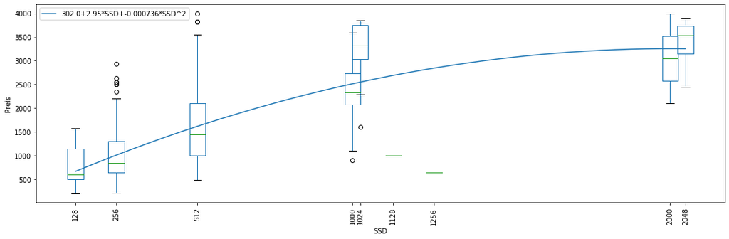

```python
fig, (ax1) = plt.subplots(1,1,figsize=(15,5))
standard_boxplot(True, ax1, "SSD", df_neu.Preis, df_neu.SSD, Bedingungen=(df_neu.HDD ==0), Balkenbreite=50, rotieren=90)
plt.savefig("SSD-Kapazität")
```

#### HDD

```python
print("HDD-Kapazität bei Laptops ohne SSD\n", df_neu[df_neu["SSD_Anzahl"]== 0]["HDD"].value_counts())
```

```
HDD-Kapazität bei Laptops ohne SSD
 1000    25
500     3
256     1
Name: HDD, dtype: int64
```

```python
print("HDD-Kapazität bei Laptops mit SSD \n", df_neu[df_neu.SSD >0].HDD.value_counts())
```

```
HDD-Kapazität bei Laptops mit SSD
 0       840
1000    168
2000    3
Name: HDD, dtype: int64
```

Die oben erstellte Funktion wird auf die HDD-Festplatten angewendet:

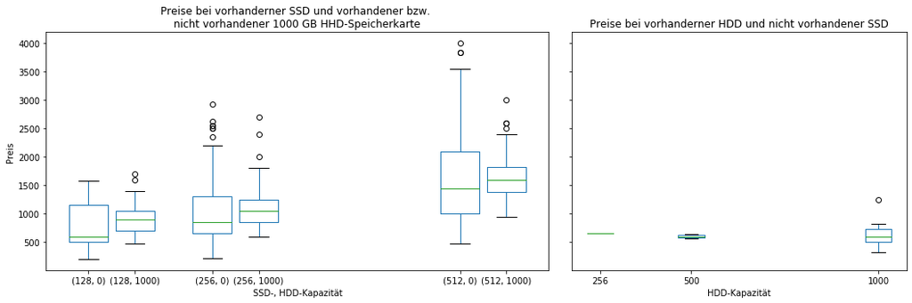

```python
fig ,(ax1, ax2) = plt.subplots(1,2, figsize=(15,5),gridspec_kw={'width_ratios': [1.5, 1]}, sharey=True)
standard_boxplot(False, ax1, "SSD-, HDD-Kapazität", df_neu.Preis, [df_neu.SSD, df_neu.HDD],
Titel="Preise bei vorhanderner SSD und vorhandener bzw. \nnicht vorhandener 1000 GB HHD-Speicherkarte", Balkenbreite=40,
Bedingungen= ((df_neu.HDD ==1000) | (df_neu.HDD ==0)) & (df_neu.SSD !=0)&
            (df_neu.SSD <1000))
standard_boxplot(False, ax2, "HDD-Kapazität", df_neu.Preis, df_neu.HDD,
Titel="Preise bei vorhanderner HDD und nicht vorhandener SSD", Balkenbreite=70,
Bedingungen= ((df_neu.HDD !=0) & (df_neu.SSD ==0)))
plt.ylabel("")
plt.savefig("HDD-Kapazität");
```

Auszug aus der Pivot-Tabelle, die die Häufigkeit von HDD und SSD-Kapazität darstellt, als zu zählendes Merkmal wurde der Preis gewählt, allerdings hätte auch jedes andere Merkmal gewählt werden können:

```python
pd.pivot_table(df_neu,values="Preis",index=["HDD", "SSD"],aggfunc="count")[0:10]
```

| HDD | SSD | Preis |
| --- | --- | --- |
| 0 | 128 | 27 |
|  | 256 | 385 |
|  | ... | ... |
|  | 2048 | 4 |
| 256 | 0 | 1 |

10 rows × 1 columns

#### Grafikkarte

Zurück zu Übersicht nach Komponenten

Es gibt zwei Merkmale, die die Grafikkarte beschreiben

1. Speicher
2. Pixelshader

Pixelshader und der Gesamtspeicher der Grafikkarte korrelieren stark miteinander:

```python
korr_grafik = df_neu[["Speicher_Grafik", "Pixelshader"]]
korr_grafik.corr()
```

|  | Speicher_Grafik | Pixelshader |
| --- | --- | --- |
| Speicher_Grafik | 1.000000 | 0.886274 |
| Pixelshader | 0.886274 | 1.000000 |

Der Grafikspeicher kann den Wert Null annehmen. Dabei handelt es sich dann um integrierte Grafikkarten

```python
print("Minimum Speicher:", df_neu["Speicher_Grafik"].min())
print("Minimum Pixelshader:", df_neu["Pixelshader"].min())
```

```
Minimum Speicher: 0
Minimum Pixelshader: 12.0
```

Häufigkeitsverteilung von Speicher und Pixelshader:

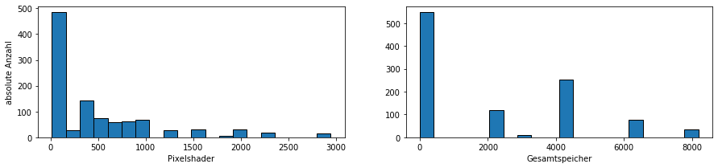

```python
plt.gcf().set_size_inches(15, 3, forward=True)
plt.subplot(1,2,1)
plt.ylabel("absolute Anzahl")
plt.xlabel("Pixelshader")
plt.hist(df_neu["Pixelshader"], bins = 20, edgecolor="black");
plt.subplot(1,2,2)
plt.xlabel("Gesamtspeicher")
plt.hist(df_neu["Speicher_Grafik"], bins = 20, edgecolor="black")
plt.savefig("hfkt_Grafikkarte");
```

Es zeigt sich, dass es teilweise unerwartete Abweichungen bei Pixelshader und Grafikspeicher bezüglich des Preises gibt. Die Abweichungen wurden nur knapp in der Arbeit erwähnt, wurden aber dennoch untersucht:

```
0.2271536983110869
0.21500707531185126
```

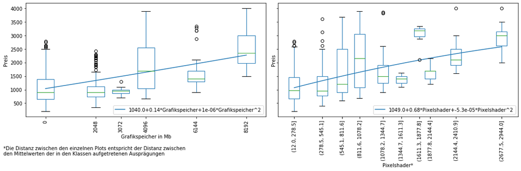

```python
fig, (ax1, ax2) = plt.subplots(1,2,figsize=(15,5), sharey=True)
standard_boxplot(True, ax1, "Grafikspeicher", df_neu.Preis, df_neu.Speicher_Grafik, rotieren=90,Balkenbreite=700)
ax1.set_xlabel("Grafikspeicher in Mb")
standard_boxplot(True, ax2, "Pixelshader", df_neu.Preis, df_neu.Pixelshader, rotieren=90, Balkenbreite=150,
                 Klassieren=True, Klassen=12)
ax2.set_xlabel("Pixelshader*")
plt.figtext(0.01, 0.1, "*Die Distanz zwischen den einzelnen Plots entspricht der Distanz zwischen\nden Mittelwerten \
der in den Klassen aufgetretenen Ausprägungen", horizontalalignment='left')
plt.savefig("Grafikspeicher_Pixelshader", bbox_inches = "tight");
```

durchschnittliche Preise für Laptops mit und ohne Touchscreen:

```python
print(df_neu[df_neu.Touchscreen == "nicht vorhanden"].Preis.mean())
print(df_neu[df_neu.Touchscreen == "vorhanden"].Preis.mean())
```

```
1307.4257651245553
1448.8426395939086
```

Untersucht man die Laptops mit einem 4096 GB Grafik-Speicher, die von der Norm abweichen, fallen folgende Eigenschaften auf:

Laptops mit 4096 GB Grafik-Speicher sind durchschnittlich etwa 14 mal häufiger Apple-Laptops als im Durchschnitt aller anderen Grafik-Speicher-Formate. Die Anzahl wie viele Observationen die anderen Speicher-Formate aufweisen wurde allerdings hier nicht berücksichtigt:

```python
tabelle0 = pd.concat([binäre_variablen, df_neu["Speicher_Grafik"]], axis=1)
tabelle1 = pd.pivot_table(tabelle0, index="Speicher_Grafik")
tabelle1 = pd.pivot_table(tabelle0[tabelle0.Speicher_Grafik != 4096], index="Speicher_Grafik").mean()
tabelle2 = pd.pivot_table(tabelle0[tabelle0.Speicher_Grafik == 4096], index="Speicher_Grafik")
ergebnis = ((tabelle1-tabelle2)/tabelle1).sort_values(by= 4096, axis=1, ascending=False)
ergebnis_spalten = abs((tabelle1-tabelle2)/tabelle1).sort_values(by= 4096, axis=1, ascending=False).columns
ergebnis = ergebnis[ergebnis_spalten]
ergebnis.iloc[:, : 4]
```

| Speicher_Grafik | Betriebssystem_MAC | Marke_Apple | Lautsprecher_ÜBERDURCHSCHN_LAUTSPRECHER | Fingerabdrucksensor_vorhanden |
| --- | --- | --- | --- | --- |
| 4096 | -13.969896 | -13.969896 | -3.082184 | -1.183678 |

wird berücksichtigt, wie häufig die einzelnen Ausprägungen des Grafik-Speichers auftreten ergibt sich folgendes Bild:

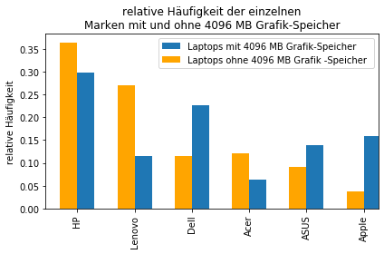

```python
Marken = df_neu.Marke.value_counts().index.tolist()
fig, ax1 = plt.subplots()
df_neu[df_neu["Speicher_Grafik"] == 4096]["Marke"].value_counts().divide(len(df_neu[df_neu["Speicher_Grafik"] ==\
4096])).reindex(index = Marken).plot(kind='bar', ax= ax1, label="Laptops mit 4096 MB Grafik-Speicher", width = 0.3, position=0)
df_neu[df_neu["Speicher_Grafik"] != 4096]["Marke"].value_counts().divide(len(df_neu[df_neu["Speicher_Grafik"] !=\
4096])).reindex(index = Marken).plot(kind='bar', ax= ax1, color="orange", label="Laptops ohne 4096 MB Grafik -Speicher ",
width=0.3, position=1)
ax1.legend(loc="upper right")
ax1.set_ylabel("relative Häufigkeit")
ax1.set_title("relative Häufigkeit der einzelnen\nMarken mit und ohne 4096 MB Grafik-Speicher")
fig.tight_layout()
plt.savefig("hfkt_4096_grafik_speicher");
```

Die überwiegende Anzahl an Apple Laptops besitzt einen 4096 MB fassenden Grafikspeicher:

```python
df_neu[df_neu.Marke == "Apple"]["Speicher_Grafik"].value_counts()
```

```
4096    40
0       29
Name: Speicher_Grafik, dtype: int64
```

Ohne Apple-Laptops ergibt sich somit folgendes Bild:

```
0.23579127362419605
0.21506769535765147
```

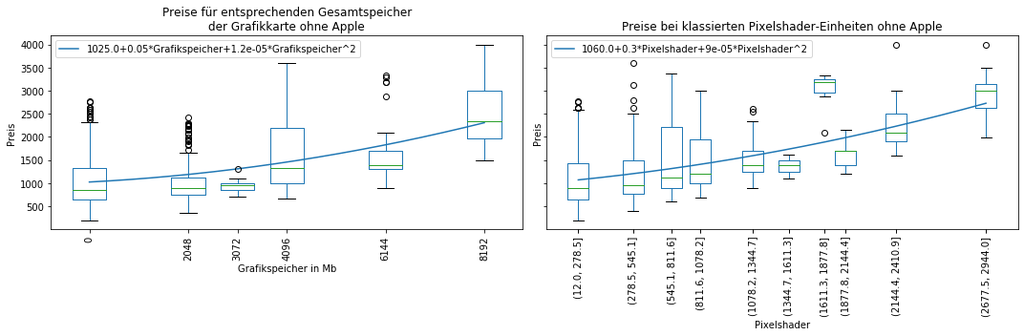

```python
fig, (ax1, ax2) = plt.subplots(1,2,figsize=(15,5), sharey=True)
standard_boxplot(True, ax1, "Grafikspeicher", df_neu.Preis, df_neu.Speicher_Grafik,Bedingungen=(df_neu.Marke!="Apple"),
Titel="Preise für entsprechenden Gesamtspeicher\nder Grafikkarte ohne Apple", Balkenbreite=700, rotieren=90)
ax1.set_xlabel("Grafikspeicher in Mb")
standard_boxplot(True, ax2, "Pixelshader", df_neu.Preis, df_neu.Pixelshader, Bedingungen=(df_neu.Marke!="Apple"),
Titel="Preise bei klassierten Pixelshader-Einheiten ohne Apple", Klassieren=True, Klassen=12, Balkenbreite=150, rotieren=90)

plt.savefig("Grafikspeicher_Pixelshader_ohne_Apple", bbox_inches = "tight");
```

#### Prozessor

Zurück zu Übersicht nach Komponenten

Merkmale des Prozessors:

1. Kerne
2. Prozessor Takt

```
0.13716936518288747
```

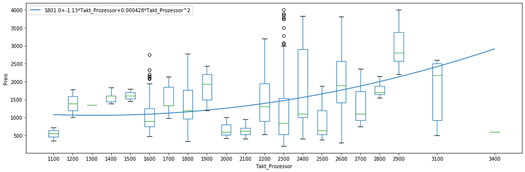

```python
fig, ax1 = plt.subplots(1,1,figsize=(15,5))
standard_boxplot(True, ax1, "Takt_Prozessor", df_neu.Preis, df_neu.Takt_Prozessor , Balkenbreite=50)
plt.savefig("Prozessor-Takt");
```

```python
def übers(x_variable, x_label, titel):
    Farben = mp.cm.get_cmap('viridis')(np.linspace(0,1,4))
    plt.viridis()
    fig, axScatter = plt.subplots(figsize=(9, 5.5));
    fig.suptitle(titel, fontsize=14);
    axScatter.scatter(x_variable, df_neu.Preis, alpha = 0.5, c=df_neu.Kerne);
    axScatter.grid(b=True);
    plt.ylabel("Preis")
    plt.xlabel(x_label)
    divider = make_axes_locatable(axScatter);
    axHisty = divider.append_axes("right", 2, pad=0.2, sharey=axScatter);
    axHisty.yaxis.set_tick_params(labelleft=False,)
    axHisty.hist([df_neu.Preis[df_neu.Kerne == Kerne] for Kerne  in sorted(df_neu["Kerne"].unique().tolist())],
                 orientation='horizontal', bins=35, alpha= 0.9, color=Farben, stacked="True");
    plt.legend(handles=[mpatches.Patch(color=Farben[i],
    label="{} Kerne".format(x)) for i,x in enumerate(sorted(df_neu["Kerne"].unique().tolist()))]);
    plt.xlabel("absolute Häufigkeit");
```

Die folgende Übersicht stellt den Zusammenhang zwischen Prozessor-Kernen, Taktfrequenz und dem Preis dar:

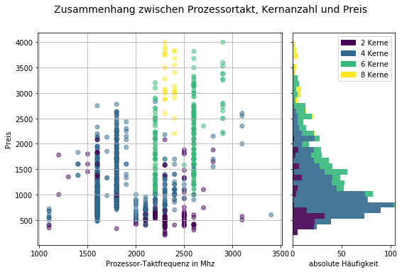

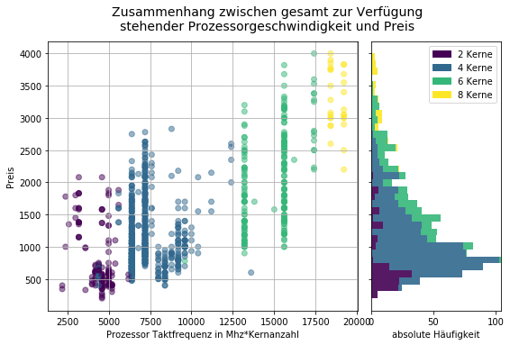

```python
übers(df_neu.Takt_Prozessor, "Prozessor-Taktfrequenz in Mhz", "Zusammenhang zwischen Prozessortakt, Kernanzahl und Preis");
übers(df_neu.Takt_Prozessor*df_neu.Kerne, "Prozessor Taktfrequenz in Mhz*Kernanzahl",
      "Zusammenhang zwischen gesamt zur Verfügung\nstehender Prozessorgeschwindigkeit und Preis" );
```

Da die obenstehdende Abbildung nur bedingt informativ ist, wurde eine weitere Abbildung erstellt, die die Größe der Punkte als absolute Häufigkeit darstellt:

```python
Klassieren(1000,3500,30, "Takt_Prozessor_Unterteilung", "Takt_Prozessor")
Klassieren(199,3999,15, "Preisspanne", "Preis")
scatter_prozessor = df_neu.groupby(["Takt_Prozessor_Unterteilung", "Preisspanne", "Kerne"])["Takt_Prozessor"].mean().to_frame("durchschn_Takt").reset_index()
scatter_preis = df_neu.groupby(["Takt_Prozessor_Unterteilung", "Preisspanne", "Kerne"])["Preis"].mean().to_frame("durchschn_Preis").reset_index()
scatter_anzahl = df_neu.groupby(["Takt_Prozessor_Unterteilung", "Preisspanne", "Kerne"]).size().to_frame("Anzahl").reset_index()
scatter_var = pd.concat([scatter_anzahl, scatter_preis, scatter_prozessor], axis=1)
scatter_var = scatter_var.T.drop_duplicates().T.apply(pd.to_numeric, errors='ignore')
del scatter_prozessor, scatter_preis, scatter_anzahl
```

```python
def Klassieren(kleinster_wert, größter_wert, klassen, name, klasse_zu_teilen):
    Unterteilung = np.linspace(kleinster_wert, größter_wert, klassen).astype(int)
    df_neu[name] = pd.cut(df_neu[klasse_zu_teilen], Unterteilung)
```

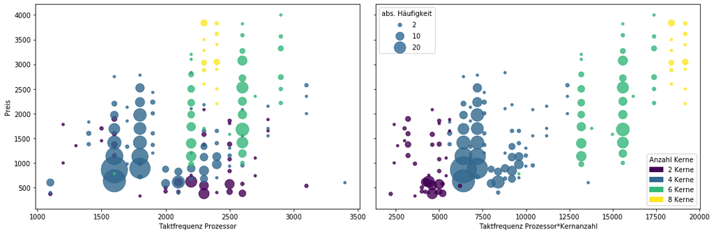

```python
fig, (ax1, ax2) = plt.subplots(1,2, figsize=(15,5), sharey= True)
ax1.scatter(scatter_var.durchschn_Takt, scatter_var.durchschn_Preis, s=scatter_var.Anzahl*15, c=scatter_var.Kerne, alpha=0.8)
ax1.set_xlabel("Taktfrequenz Prozessor")
ax1.set_ylabel("Preis");
scatter = ax2.scatter(scatter_var.durchschn_Takt*scatter_var.Kerne, scatter_var.durchschn_Preis, s=scatter_var.Anzahl*15,
            c=scatter_var.Kerne, alpha=0.8)
kw = dict(prop="sizes", num=[2, 10, 20], color="#306998", func=lambda s: s/15)
legende1 = ax2.legend(*scatter.legend_elements(**kw),loc="best", title="abs. Häufigkeit")
Farben = mp.cm.get_cmap('viridis')(np.linspace(0,1,4))
legende2 = ax2.legend(title= "Anzahl Kerne", loc="lower right", handles=[mpatches.Patch(color=Farben[i],
label="{} Kerne".format(x)) for i,x in enumerate(sorted(df_neu["Kerne"].unique().tolist()))]);
ax2.add_artist(legende1)
ax2.set_xlabel("Taktfrequenz Prozessor*Kernanzahl")
plt.tight_layout()
plt.savefig("Kerntakt_Kerne");
```

Wie auch in der Grafik, zeigt sich, dass Prozessoren mit zwei Kernen eine durchschnittlich höhere Taktfrequenz aufweisen, als Laptops mit vier Kernen:

```python
print(df_neu[df_neu.Kerne == 2].Takt_Prozessor.mean())
print(df_neu[df_neu.Kerne == 4].Takt_Prozessor.mean())
```

```
2202.127659574468
1808.623298033283
```

```
0.4714208695602562
```

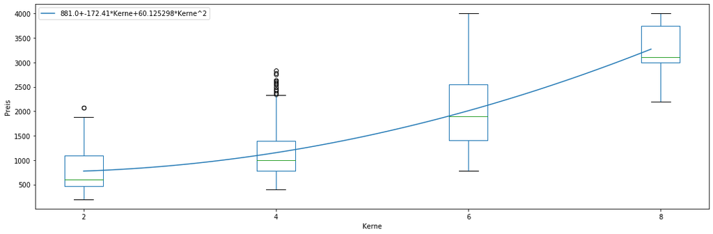

```python
fig, ax1 = plt.subplots(1,1,figsize=(15,5))
standard_boxplot(True, ax1, "Kerne", df_neu.Preis, df_neu.Kerne , Balkenbreite=0.4)
plt.tight_layout()
plt.savefig("Kerne");
```

#### Arbeitsspeicher

Zurück zu Übersicht nach Komponenten

Merkmale des Arbeitsspeichers:

1. Typ (DDR3/DDR4)
2. Speicher

Der Typ des Arbeitsspeichers und die Kapazität des Arbeitsspeichers korrelieren kaum miteinander:

```python
binäre_variablen.Typ_Arbeitsspeicher_DDR_4.corr(df_neu.Arbeitsspeicher)
```

```
0.04389714028870925
```

```
0.5832796326902863
```

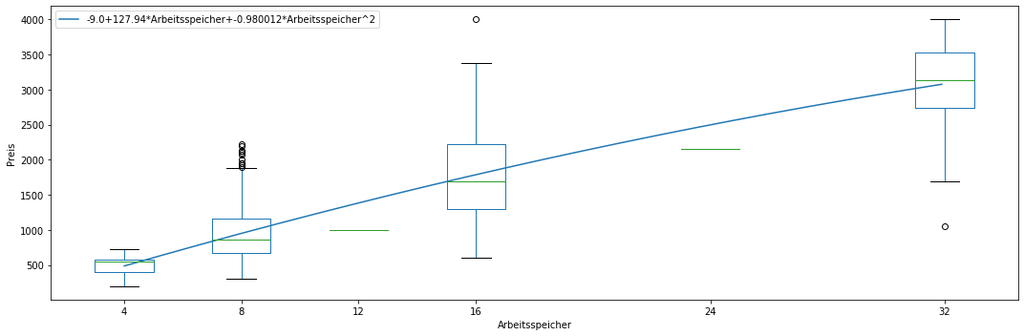

```python
fig,ax1 = plt.subplots(1,1, figsize=(15,5))
standard_boxplot(True, ax1, "Arbeitsspeicher", df_neu.Preis, [df_neu.Arbeitsspeicher], Balkenbreite=2)
plt.tight_layout()
plt.savefig("arbeitsspeicher");
```

Durchschnittliche Preise ausgewählter Laptops für bestimmte Kapazitäten an Arbeitsspeicher:

```python
print(df_neu[df_neu.Arbeitsspeicher == 4].Preis.median())
print(df_neu[df_neu.Arbeitsspeicher == 8].Preis.median())
print(df_neu[df_neu.Arbeitsspeicher == 16].Preis.median())
```

```
549.0
869.0
1699.0
```

#### Bildschirm

Zurück zu Übersicht nach Komponenten

Merkmale des Bildschirms:

1. Pixeldichte
2. Größe
3. Touchscreen

```
0.007398598463080663
```

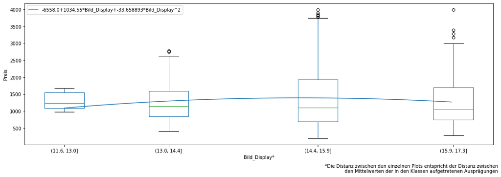

```python
fig, (ax1) = plt.subplots(1,1, sharey=True, figsize=(15,5))
standard_boxplot(True, ax1, "Bild_Display", df_neu.Preis, df_neu.Bild_Display, Klassieren=True, Klassen=5, Balkenbreite=0.5)

plt.figtext(1, -.05, "*Die Distanz zwischen den einzelnen Plots entspricht der Distanz zwischen\nden Mittelwerten \
der in den Klassen aufgetretenen Ausprägungen", horizontalalignment='right')
ax1.set_xlabel("Bild_Display*")
plt.tight_layout()
plt.savefig("display_größe", bbox_inches = "tight");
```

```python
print("durchschnittliche Bildschirm-Größe:",df_neu.Bild_Display.mean())
print("durchschnittlicher Preis für Laptops über durchschn. Bildschirm-Größe:",df_neu[df_neu.Bild_Display>=15].Preis.mean())
print("durchschnittlicher Preis für Laptops über durchschn. Bildschirm-Größe:",df_neu[df_neu.Bild_Display<15].Preis.mean())
```

```
durchschnittliche Bildschirm-Größe: 15.073557692307721
durchschnittlicher Preis für Laptops über durchschn. Bildschirm-Größe: 1381.8342211838008
durchschnittlicher Preis für Laptops über durchschn. Bildschirm-Größe: 1257.397864321608
```

```
0.2904569914830817
```

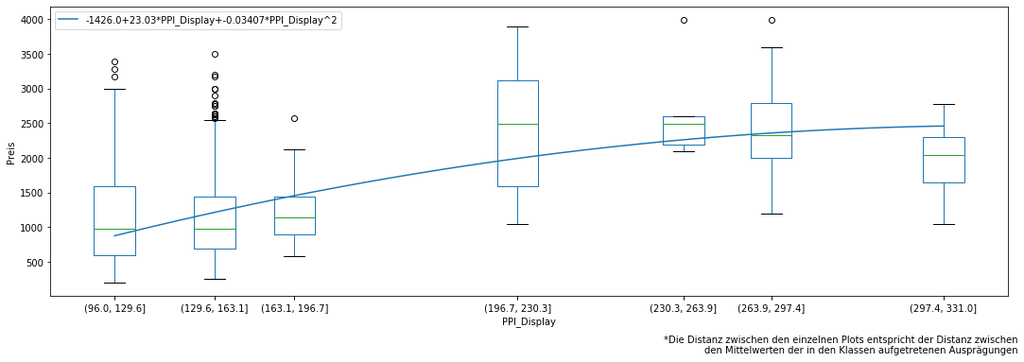

```python
fig, ax1 = plt.subplots(1,1,figsize=(15,5))
standard_boxplot(True, ax1, "PPI_Display", df_neu.Preis, df_neu.PPI_Display, Klassieren=True, Klassen=8, Balkenbreite=10)

plt.figtext(1, -.05, "*Die Distanz zwischen den einzelnen Plots entspricht der Distanz zwischen\nden Mittelwerten \
der in den Klassen aufgetretenen Ausprägungen", horizontalalignment='right')
plt.tight_layout()
plt.savefig("pixeldichte", bbox_inches = "tight");
```

#### Akku

Zurück zu Übersicht nach Komponenten

Merkmale des Akkus:

1. Speichertyp
2. Akku-Kapazität

für den Akku wird eine eigene Funktion erstellt:

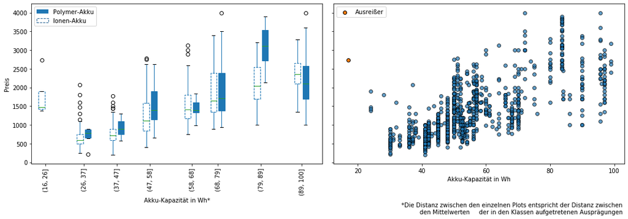

```python
def Akku():
    Klassieren(16, 100, 9, "Akku_Unterteilung", "Akku_Kapazität")
    skalierung = df_neu.groupby(["Akku_Unterteilung"])["Akku_Kapazität"].mean().tolist()
    skalierung = [Mittelwert/skalierung[0] for Mittelwert in skalierung]
    fig, (ax1, ax2) = plt.subplots(1,2, figsize=(15,5), sharey= True)
    boxprops = dict(linestyle='--')
    bp1 = df_neu[df_neu.Akku_Typ=="ION"].boxplot(column="Preis", by=["Akku_Unterteilung", "Akku_Typ"],ax=ax1,
    positions=[x*4 for x in skalierung], boxprops=boxprops, rot= 90, widths=(0.3), grid=False);
    bp2 = df_neu[df_neu.Akku_Typ=="POLYMER"].boxplot(column="Preis", by=["Akku_Unterteilung"],ax=ax1,
    patch_artist=True,positions=[x*4+0.4 for x in skalierung], rot= 90, widths=(0.3), grid=False, manage_ticks=False);
    Ionen_patch = mpatches.Patch(label="Polymer-Akku")
    poly_patch = mpatches.Patch(label="Ionen-Akku", linestyle="--", facecolor="white", edgecolor="#306998")
    ax1.legend(handles=[Ionen_patch, poly_patch])
    ax1.set_xticks(ticks=[x*4+0.2 for x in skalierung])
    ax1.set_xlabel("Akku-Kapazität in Wh*")
    ax1.set_ylabel("Preis")
    ax1.set_title("")
    fig.suptitle("");
    plt.figtext(0.98, -0.02, "*Die Distanz zwischen den einzelnen Plots entspricht der Distanz zwischen\nden Mittelwerten \
    der in den Klassen aufgetretenen Ausprägungen", horizontalalignment='right')
    plt.tight_layout()
    ax2.scatter(df_neu[~df_neu.index.isin([650])].Akku_Kapazität, df_neu[~df_neu.index.isin([650])].Preis,
                edgecolor="black", alpha=0.7)
    ax2.scatter(df_neu.loc[ 650 , "Akku_Kapazität"], df_neu.loc[ 650 , "Preis"], edgecolor="black",
                label="Ausreißer")
    ax2.legend()
    ax2.set_xlabel("Akku-Kapazität in Wh")
Akku()
plt.savefig("akku", bbox_inches = "tight");
```

### Löschen des Ausreißers:

Zurück zu Deskriptive Statistik

```python
df_neu.loc[ 650 , "Akku_Kapazität"]
```

```
17.0
```

Die Anzahl an Observationen reduziert sich also auf 1039:

```python
df_neu = df_neu[~df_neu.index.isin([650])]
binäre_variablen = binäre_variablen[~binäre_variablen.index.isin([650])]
len(df_neu)
```

```
1039
```

Löschen jeweils einer Dummy-Variable:

```python
binäre_variablen = binäre_variablen.drop(["Preis", "Preisspanne", "Typ_Arbeitsspeicher_DDR_3", "Laufwerk_nicht_vorhanden",
                        "Lautsprecher_STANDARD_LAUTSPRECHER", "Tastatur_Beleuchtung_nicht_vorhanden",
                      "Fingerabdrucksensor_nicht_vorhanden", "Touchscreen_nicht_vorhanden",
                      "Mobilfunk_nicht_vorhanden", "NFC_nicht_vorhanden", "Betriebssystem_WINDOWS", "Betriebssystem_MAC",
                      "Akku_Typ_POLYMER", "Marke_HP",
                        "Mikrofon_Sound_nicht_vorhanden", "Rabatt_Lehreinrichtung_nicht_vorhanden"], axis=1)
```

Erstellen quantitativer Merkmale:

```python
quantitative_variablen = df_neu.drop(["Typ_Arbeitsspeicher", "Laufwerk", "Lautsprecher", "Tastatur_Beleuchtung",
                      "Fingerabdrucksensor", "Touchscreen", "Mobilfunk", "NFC", "Preisspanne",
                      "Akku_Typ", "Betriebssystem", "Mikrofon_Sound", "Rabatt_Lehreinrichtung",
                    "HDD_Anzahl", "SSD_Anzahl", "Marke", "Farbe", "Skalierung",
                    "Takt_Prozessor_Unterteilung", "Akku_Unterteilung"], axis=1)
```

**Zusammenfügen quantitativer und qualtitativer Merkmale:**

```python
x = pd.concat([quantitative_variablen, binäre_variablen], axis="columns")
x.to_csv(r'C:\Users\tobia\Desktop\Uni\Marburg\Bachelorarbeit\Alternate\fertiges_datenset.csv')
x = x.drop(["URL"], axis=1)
quantitative_variablen = quantitative_variablen.drop(["URL", "Preis"], axis=1)
```

```python
x
```

| Laptop_ID | Preis | Kerne | Takt_Prozessor | Arbeitsspeicher | Bild_Display | Speicher_Grafik | extern_Schnittstellen | HDD | SSD | Akku_Kapazität | PPI_Display | Pixelshader | Typ_Arbeitsspeicher_DDR_4 | Laufwerk_VORHANDEN | Lautsprecher_ÜBERDURCHSCHN_LAUTSPRECHER | Tastatur_Beleuchtung_vorhanden | Fingerabdrucksensor_vorhanden | Touchscreen_vorhanden | Mobilfunk_vorhanden | NFC_vorhanden | Akku_Typ_ION | Marke_ASUS | Marke_Acer | Marke_Apple | Marke_Dell | Marke_Lenovo | Betriebssystem_DOS | Betriebssystem_LINUX | Betriebssystem_OHNE_BETRIEBSSYSTEM | … |
| --- | --- | --- | --- | --- | --- | --- | --- | --- | --- | --- | --- | --- | --- | --- | --- | --- | --- | --- | --- | --- | --- | --- | --- | --- | --- | --- | --- | --- | --- | --- |
| 2 | 299.0 | 2 | 2600 | 8 | 15.6 | 0 | 6 | 0 | 256 | 41.0 | 141 | 192.0 | 1 | 1 | 0 | 0 | 0 | 0 | 0 | 0 | 1 | 0 | 0 | 0 | 0 | 0 | 0 | 0 | 1 | … |
| 4 | 899.0 | 6 | 2200 | 8 | 15.6 | 6144 | 9 | 1000 | 128 | 70.0 | 141 | 1280.0 | 1 | 0 | 0 | 1 | 0 | 0 | 0 | 0 | 1 | 0 | 0 | 0 | 0 | 0 | 0 | 0 | 0 | … |
| ... | ... | ... | ... | ... | ... | ... | ... | ... | ... | ... | ... | ... | ... | ... | ... | ... | ... | ... | ... | ... | ... | ... | ... | ... | ... | ... | ... | ... | ... | … |
| 1747 | 949.0 | 4 | 2300 | 8 | 15.6 | 4096 | 7 | 1000 | 128 | 48.0 | 141 | 640.0 | 1 | 0 | 0 | 1 | 0 | 0 | 0 | 0 | 1 | 0 | 1 | 0 | 0 | 0 | 0 | 0 | 0 | … |
| 1748 | 1299.0 | 4 | 2300 | 16 | 15.6 | 6144 | 6 | 0 | 512 | 48.0 | 141 | 1920.0 | 1 | 0 | 0 | 1 | 0 | 0 | 0 | 0 | 1 | 1 | 0 | 0 | 0 | 0 | 0 | 0 | 0 | … |

1039 rows × 31 columns

## Induktive Statistik

Zurück zur Gliederung

1. Generelle Kollinearität
2. Erstellen Transformierter Werte
3. Modelle (Modellübersicht)
4. Residuen-Plots
5. Kreuzvalidierung
6. Modellsauswahl und Darstellung
7. Weitere in der Arbeit nicht berücksichtigte Modelle

Laden des oben erstellen, fertigen Datensatzes:

```python
x = pd.read_csv(r'C:\Users\tobia\Desktop\Uni\Marburg\Bachelorarbeit\Alternate\fertiges_datenset.csv')
x.set_index("Laptop_ID", inplace=True)
x = x.drop(["URL"], axis=1)
```

Die ersten zwei Observationen:

```python
x.head(2)
```

| Laptop_ID | Preis | Kerne | Takt_Prozessor | Arbeitsspeicher | Bild_Display | Speicher_Grafik | extern_Schnittstellen | HDD | SSD | Akku_Kapazität | PPI_Display | Pixelshader | Typ_Arbeitsspeicher_DDR_4 | Laufwerk_VORHANDEN | Lautsprecher_ÜBERDURCHSCHN_LAUTSPRECHER | Tastatur_Beleuchtung_vorhanden | Fingerabdrucksensor_vorhanden | Touchscreen_vorhanden | Mobilfunk_vorhanden | NFC_vorhanden | Akku_Typ_ION | Marke_ASUS | Marke_Acer | Marke_Apple | Marke_Dell | Marke_Lenovo | Betriebssystem_DOS | Betriebssystem_LINUX | Betriebssystem_OHNE_BETRIEBSSYSTEM | … |
| --- | --- | --- | --- | --- | --- | --- | --- | --- | --- | --- | --- | --- | --- | --- | --- | --- | --- | --- | --- | --- | --- | --- | --- | --- | --- | --- | --- | --- | --- | --- |
| 2 | 299.0 | 2 | 2600 | 8 | 15.6 | 0 | 6 | 0 | 256 | 41.0 | 141 | 192.0 | 1 | 1 | 0 | 0 | 0 | 0 | 0 | 0 | 1 | 0 | 0 | 0 | 0 | 0 | 0 | 0 | 1 | … |
| 4 | 899.0 | 6 | 2200 | 8 | 15.6 | 6144 | 9 | 1000 | 128 | 70.0 | 141 | 1280.0 | 1 | 0 | 0 | 1 | 0 | 0 | 0 | 0 | 1 | 0 | 0 | 0 | 0 | 0 | 0 | 0 | 0 | … |

Der Preis gehört nicht zu den Prädiktoren und wird als separater Datensatz behandelt, zudem werden logarithmische Werte des Preises erstellt:

```python
y = pd.DataFrame()
y["Preis"] = x.pop("Preis")
y["Log_Preis"] = np.log(y.Preis)
```

### Überprüfung möglicher Multikollinearität - generell:

Zurück zu Induktive Statistik

Die drei am stärksten miteinander korrelierenden Merkmale:

```python
c = x.corr()
c =c.mask(np.tril(np.ones(c.shape)).astype(np.bool)).abs()
corr = c.unstack()
corr = pd.DataFrame(corr.sort_values(kind="quicksort")).reset_index()
corr1 = corr[corr.level_0 != corr.level_1].sort_values(by=[0], ascending=False).reset_index().drop("index", axis=1).dropna()
corr1.head(3)
```

|  | level_0 | level_1 | 0 |
| --- | --- | --- | --- |
| 0 | Pixelshader | Speicher_Grafik | 0.886291 |
| 1 | Speicher_Grafik | Kerne | 0.670456 |
| 2 | Akku_Kapazität | Kerne | 0.660291 |

```python
def vif(var):
    from statsmodels.stats.outliers_influence import variance_inflation_factor
    vif = pd.DataFrame()
    vif["VIF"] = [variance_inflation_factor(var.values, i) for i in range(var.shape[1])]
    vif["Merkmale"] = var.columns
    vif = vif[vif.Merkmale != "Konstante"]
    return(vif.sort_values(by=["VIF"], ascending=False).reset_index(drop=True))
```

```python
vif(x)
```

|  | VIF | Merkmale |
| --- | --- | --- |
| 0 | 122.188786 | Bild_Display |
| 1 | 53.908087 | Takt_Prozessor |
| ... | ... | ... |
| 28 | 1.137903 | Betriebssystem_DOS |
| 29 | 1.061592 | Betriebssystem_LINUX |

30 rows × 2 columns

### Transformierte Werte

Zurück zu Induktive Statistik

```python
x["Konstante"] = 1
```

```python
quantitativ = x[['Kerne', 'Takt_Prozessor',
           'Arbeitsspeicher',
           'Bild_Display',
           'Speicher_Grafik',
           'extern_Schnittstellen',
           'HDD', 'SSD',
           'Akku_Kapazität',
           'PPI_Display',
           'Pixelshader']]
```

```python
qualitativ = x[['Laufwerk_VORHANDEN','Tastatur_Beleuchtung_vorhanden', 'Fingerabdrucksensor_vorhanden',
           'Touchscreen_vorhanden', 'Mobilfunk_vorhanden', 'NFC_vorhanden', 'Mikrofon_Sound_vorhanden',
           'Rabatt_Lehreinrichtung_vorhanden','Akku_Typ_ION',
           'Marke_ASUS', 'Marke_Acer', 'Marke_Apple', 'Marke_Dell','Marke_Lenovo',
           'Betriebssystem_DOS', 'Betriebssystem_LINUX','Betriebssystem_OHNE_BETRIEBSSYSTEM',
           'Lautsprecher_ÜBERDURCHSCHN_LAUTSPRECHER', 'Typ_Arbeitsspeicher_DDR_4', "Konstante"]]
```

```python
def x_var_erstellen(quant, qual):
    return(pd.concat([quant, qual], axis="columns"))
```

#### Funktionen um Merkmale gegebenfalls standardisieren und zentrieren zu können:

```python
def standardisieren(var):
    varn= (var-var.mean())/var.std()
    return(varn)
def zentrieren(var):
    varn =(var-var.mean())
    return(varn)
```

#### Erstellen quadratischer Werte:

```python
x["Kerne_quad"] = x.Kerne**2
x["Takt_Prozessor_quad"] = x.Takt_Prozessor**2
x["Arbeitsspeicher_quad"] = x.Arbeitsspeicher**2
x["Bild_Display_quad"] = x.Bild_Display**2
x["Speicher_Grafik_quad"] = x.Speicher_Grafik**2
x["extern_Schnittstellen_quad"] = x.extern_Schnittstellen**2
x["HDD_quad"] = x.HDD**2
x["SSD_quad"] = x.SSD**2
x["Akku_Kapazität_quad"] = x.Akku_Kapazität**2
x["PPI_Display_quad"] =x.PPI_Display**2
x["Pixelshader_quad"] =x.Pixelshader**2
```

#### Erstellen von Logarithmen:

```python
x["log_Kerne"] =np.log(x.Kerne)
x["log_Takt_Prozessor"] =np.log(x.Takt_Prozessor)
x["log_Arbeitsspeicher"] = np.log(x.Arbeitsspeicher)
x["log_Bild_Display"] =np.log(x.Bild_Display)
x["log_Speicher_Grafik"] = np.log(x.Speicher_Grafik+1)
x["log_extern_Schnittstellen"] = np.log(x.extern_Schnittstellen)
x["log_HDD"] = np.log(x.HDD+1)
x["log_SSD"] =np.log(x.SSD+1)
x["log_Akku_Kapazität"] =np.log(x.Akku_Kapazität)
x["log_PPI_Display"] =np.log(x.PPI_Display)
x["log_Pixelshader"] =np.log(x.Pixelshader)
```

#### Erstellen zentrierter Werte:

```python
x["Kerne_z"] = x.Kerne-x.Kerne.mean()
x["Kerne_z_quad"] = x.Kerne_z**2
x["Takt_Prozessor_z"] = x.Takt_Prozessor-x.Takt_Prozessor.mean()
x["Takt_Prozessor_z_quad"] = x.Takt_Prozessor_z**2
x["Arbeitsspeicher_z"] = x.Arbeitsspeicher-x.Arbeitsspeicher.mean()
x["Arbeitsspeicher_z_quad"] = x.Arbeitsspeicher_z**2
x["Bild_Display_z"] = x.Bild_Display-x.Bild_Display.mean()
x["Bild_Display_z_quad"] = x.Bild_Display_z**2
x["Speicher_Grafik_z"] = x.Speicher_Grafik-x.Speicher_Grafik.mean()
x["Speicher_Grafik_z_quad"] = x.Speicher_Grafik_z**2
x["extern_Schnittstellen"] = x.extern_Schnittstellen
x["HDD_z"] = x.HDD-x.HDD.mean()
x["HDD_z_quad"] = x.HDD_z**2
x["SSD_z"] = x.SSD-x.SSD.mean()
x["SSD_z_quad"] = x.SSD_z**2
x["Akku_Kapazität_z"] = x.Akku_Kapazität-x.Akku_Kapazität.mean()
x["Akku_Kapazität_z_quad"] = x.Akku_Kapazität_z**2
x["PPI_Display_z"] = x.PPI_Display-x.PPI_Display.mean()
x["PPI_Display_z_quad"] = x.PPI_Display_z**2
x["Pixelshader_z"] = x.Pixelshader-x.Pixelshader.mean()
x["Pixelshader_z_quad"] = x.Pixelshader_z**2
```

#### Datensatz wird erneut gespeichert:

```python
x["Preis"] = y["Preis"]
x["Log_Preis"] = y["Log_Preis"]
x.to_csv(r'C:\Users\tobia\Desktop\Uni\Marburg\Bachelorarbeit\Alternate\fertiges_datenset_transform.csv')
x = x.drop(["Preis", "Log_Preis"], axis=1)
```

### Modellübersicht

Zurück zu Induktive Statistik

Die Vorgehensweise ist identisch für die drei Modelle. Es wird ein nicht reduziertes Modell erstellt, überprüft, ob Heteroskedastizität vorliegt und mögliche Multikollinearität überprüft. Da für Modell2 und Modell3 bereits Vergleichswerte vorhanden sind, werden die reduzierten und zentrierten Modelle Modell2 und Modell3 anhand des Bestimmtheitsmaßes bezügliche des Preises mit Modell1 verglichen. Die Resdiuen-Plots werden für die drei Modelle dargestellt, für jedes Modell eine fünf-fache Kreuzvalidierung durchgeführt und ein Modell ausgewählt, welches den Zusammenhang zwischen Prädiktoren und Zielgröße vermutlich am Besten beschreiben kann, wofür dann eine Gesamtübersicht erstellt wird.

1. Modell1
   - nicht zentriert und nicht reduziert
     - Regression
     - Breusch-Pagan
     - VIF
   - zentriert und nicht reduziert
     - VIF
   - zentriert und reduziert
2. Modell2
   - zentriert und nicht reduziert
     - Breusch-Pagan
     - Vergleich Modell1 und Modell2
   - zentriert und reduziert
3. Modell3
   - zentriert und nicht reduziert
     - Breusch-Pagan
     - VIF
   - zentriert und reduziert
     - Vergleich Modell1, Modell2 und Modell3

### Modell1

#### nicht zentriert und nicht reduziert

Zurück zu Modellübersicht

#### quantitative erklärende Variablen Modell1 und Modell2:

```python
x_quant = x[['Kerne', "Kerne_quad", 'Takt_Prozessor', "Takt_Prozessor_quad",
           'Arbeitsspeicher', "Arbeitsspeicher_quad",
           'Bild_Display', "Bild_Display_quad",
           'Speicher_Grafik', "Speicher_Grafik_quad",
           'extern_Schnittstellen',
           'HDD', "HDD_quad", 'SSD', 'SSD_quad',
           'Akku_Kapazität', "Akku_Kapazität_quad",
           'PPI_Display', "PPI_Display_quad",
           'Pixelshader', "Pixelshader_quad"]]
```

#### Zusammenfügen quantitativer und qualitativer Merkmale:

```python
x_neu1 = x_var_erstellen(x_quant, qualitativ)
```

Es erscheint hier eine Warnung, dass die Regressionsfunktion keinen vollen Rang hat. Deshalb wurden sämtliche Regressionen auch in Stata durchgeführt um zu überprüfen, ob auch hier eine Warnung erscheint oder Variablen ausgelassen wurden. Allerdings waren die Ergebnisse identisch

```python
model = sm.OLS(y.Preis, x_neu1)
mod_lin0 = model.fit(cov_type="HC0")
x["fit_mod_lin0"] = mod_lin0.fittedvalues
x["resid_mod_lin0"] = mod_lin0.resid
mod_lin0.summary()
```

```
C:\Users\tobia\Anaconda3\lib\site-packages\statsmodels\base\model.py:1752: ValueWarning: covariance of constraints does not have full rank. The number of constraints is 40, but rank is 36
  'rank is %d' % (J, J_), ValueWarning)
```

OLS Regression Results

| Dep. Variable: | Preis | R-squared: | 0.885 |
| --- | --- | --- | --- |
| Model: | OLS | Adj. R-squared: | 0.881 |
| Method: | Least Squares | F-statistic: | 306.7 |
| Date: | Sun, 20 Oct 2019 | Prob (F-statistic): | 0.00 |
| Time: | 18:10:00 | Log-Likelihood: | -7225.4 |
| No. Observations: | 1039 | AIC: | 1.453e+04 |
| Df Residuals: | 998 | BIC: | 1.474e+04 |
| Df Model: | 40 |  |  |
| Covariance Type: | HC0 |  |  |

|  | coef | std err | z | P>\|z\| | [0.025 | 0.975] |
| --- | --- | --- | --- | --- | --- | --- |
| Kerne | -13.4993 | 38.246 | -0.353 | 0.724 | -88.459 | 61.461 |
| Kerne_quad | 12.5020 | 4.079 | 3.065 | 0.002 | 4.508 | 20.496 |
| Takt_Prozessor | -0.4064 | 0.237 | -1.717 | 0.086 | -0.870 | 0.058 |
| Takt_Prozessor_quad | 0.0001 | 5.68e-05 | 2.382 | 0.017 | 2.4e-05 | 0.000 |
| Arbeitsspeicher | 31.7303 | 6.892 | 4.604 | 0.000 | 18.221 | 45.239 |
| Arbeitsspeicher_quad | -0.0681 | 0.183 | -0.372 | 0.710 | -0.426 | 0.290 |
| Bild_Display | -322.2233 | 148.314 | -2.173 | 0.030 | -612.914 | -31.533 |
| Bild_Display_quad | 11.0136 | 4.880 | 2.257 | 0.024 | 1.449 | 20.578 |
| Speicher_Grafik | 0.0790 | 0.019 | 4.200 | 0.000 | 0.042 | 0.116 |
| Speicher_Grafik_quad | -1.194e-05 | 3.9e-06 | -3.064 | 0.002 | -1.96e-05 | -4.3e-06 |
| extern_Schnittstellen | 13.6340 | 8.723 | 1.563 | 0.118 | -3.463 | 30.731 |
| HDD | 0.1424 | 0.055 | 2.611 | 0.009 | 0.035 | 0.249 |
| HDD_quad | -0.0002 | 3.34e-05 | -5.538 | 0.000 | -0.000 | -0.000 |
| SSD | 0.2886 | 0.097 | 2.972 | 0.003 | 0.098 | 0.479 |
| SSD_quad | 3.098e-05 | 4.68e-05 | 0.662 | 0.508 | -6.07e-05 | 0.000 |
| Akku_Kapazität | 5.8603 | 4.918 | 1.192 | 0.233 | -3.779 | 15.499 |
| Akku_Kapazität_quad | 0.0493 | 0.039 | 1.265 | 0.206 | -0.027 | 0.126 |
| PPI_Display | 4.6292 | 2.163 | 2.140 | 0.032 | 0.390 | 8.868 |
| PPI_Display_quad | -0.0063 | 0.005 | -1.308 | 0.191 | -0.016 | 0.003 |
| Pixelshader | -0.3556 | 0.073 | -4.902 | 0.000 | -0.498 | -0.213 |
| Pixelshader_quad | 0.0002 | 3.25e-05 | 6.785 | 0.000 | 0.000 | 0.000 |
| Laufwerk_VORHANDEN | 14.8041 | 33.541 | 0.441 | 0.659 | -50.934 | 80.542 |
| Tastatur_Beleuchtung_vorhanden | 137.2391 | 22.965 | 5.976 | 0.000 | 92.228 | 182.250 |
| Fingerabdrucksensor_vorhanden | 25.8538 | 21.315 | 1.213 | 0.225 | -15.923 | 67.630 |
| Touchscreen_vorhanden | 82.2398 | 27.135 | 3.031 | 0.002 | 29.057 | 135.423 |
| Mobilfunk_vorhanden | 334.1124 | 37.750 | 8.851 | 0.000 | 260.123 | 408.102 |
| NFC_vorhanden | 244.0871 | 55.699 | 4.382 | 0.000 | 134.919 | 353.255 |
| Mikrofon_Sound_vorhanden | 24.5174 | 26.379 | 0.929 | 0.353 | -27.184 | 76.219 |
| Rabatt_Lehreinrichtung_vorhanden | 31.9003 | 57.805 | 0.552 | 0.581 | -81.395 | 145.196 |
| Akku_Typ_ION | -48.1620 | 31.674 | -1.521 | 0.128 | -110.243 | 13.919 |
| Marke_ASUS | -22.4712 | 30.641 | -0.733 | 0.463 | -82.527 | 37.584 |
| Marke_Acer | -29.5293 | 27.186 | -1.086 | 0.277 | -82.814 | 23.755 |
| Marke_Apple | 446.6866 | 60.108 | 7.431 | 0.000 | 328.878 | 564.496 |
| Marke_Dell | -23.8031 | 32.137 | -0.741 | 0.459 | -86.791 | 39.185 |
| Marke_Lenovo | 157.3070 | 27.165 | 5.791 | 0.000 | 104.064 | 210.550 |
| Betriebssystem_DOS | -226.4823 | 36.245 | -6.249 | 0.000 | -297.520 | -155.444 |
| Betriebssystem_LINUX | -31.3285 | 63.970 | -0.490 | 0.624 | -156.708 | 94.051 |
| Betriebssystem_OHNE_BETRIEBSSYSTEM | -265.5741 | 36.641 | -7.248 | 0.000 | -337.390 | -193.758 |
| Lautsprecher_ÜBERDURCHSCHN_LAUTSPRECHER | 134.1329 | 47.923 | 2.799 | 0.005 | 40.205 | 228.061 |
| Typ_Arbeitsspeicher_DDR_4 | -137.4838 | 40.639 | -3.383 | 0.001 | -217.135 | -57.832 |
| Konstante | 2041.9514 | 1156.233 | 1.766 | 0.077 | -224.224 | 4308.127 |

| Omnibus: | 67.402 | Durbin-Watson: | 1.749 |
| --- | --- | --- | --- |
| Prob(Omnibus): | 0.000 | Jarque-Bera (JB): | 89.573 |
| Skew: | 0.563 | Prob(JB): | 3.54e-20 |
| Kurtosis: | 3.894 | Cond. No. | 2.80e+09 |

Warnings:  
[1] Standard Errors are heteroscedasticity robust (HC0)  
[2] The condition number is large, 2.8e+09. This might indicate that there are  
strong multicollinearity or other numerical problems.

#### Breusch-Pagan Modell1

Der Breusch-Pagan Test wird mittels den quadrierten Werten der Resiuden als Zielgröße durchgeführt. Der in der Arbeit abgebildete P-Wert der F-Statistik ist in der untenstehenden Abbildung mit **Prob (F-statistic)** gekennzeichnet.

```python
x["residquad0"] = mod_lin0.resid**2
X_test = x[["Kerne", "Takt_Prozessor", "Arbeitsspeicher", "HDD", "SSD", "Akku_Kapazität", "PPI_Display","Bild_Display",
            "Speicher_Grafik", "Pixelshader", "extern_Schnittstellen"]]
model = sm.OLS(x["residquad0"], sm.add_constant(X_test))
homoskedastizität = model.fit()
homoskedastizität.summary()
```

OLS Regression Results

| Dep. Variable: | residquad0 | R-squared: | 0.067 |
| --- | --- | --- | --- |
| Model: | OLS | Adj. R-squared: | 0.057 |
| Method: | Least Squares | F-statistic: | 6.745 |
| Date: | Sun, 20 Oct 2019 | Prob (F-statistic): | 5.20e-11 |
| Time: | 18:10:00 | Log-Likelihood: | -13492. |
| No. Observations: | 1039 | AIC: | 2.701e+04 |
| Df Residuals: | 1027 | BIC: | 2.707e+04 |
| Df Model: | 11 |  |  |
| Covariance Type: | nonrobust |  |  |

|  | coef | std err | t | P>\|t\| | [0.025 | 0.975] |
| --- | --- | --- | --- | --- | --- | --- |
| const | 1.468e+05 | 5.85e+04 | 2.507 | 0.012 | 3.19e+04 | 2.62e+05 |
| Kerne | -9850.2844 | 4238.671 | -2.324 | 0.020 | -1.82e+04 | -1532.839 |
| Takt_Prozessor | -4.3560 | 11.542 | -0.377 | 0.706 | -27.005 | 18.293 |
| Arbeitsspeicher | 1006.7544 | 807.164 | 1.247 | 0.213 | -577.125 | 2590.634 |
| HDD | -17.7264 | 9.803 | -1.808 | 0.071 | -36.963 | 1.510 |
| SSD | -9.8656 | 17.725 | -0.557 | 0.578 | -44.648 | 24.917 |
| Akku_Kapazität | 1220.2572 | 328.854 | 3.711 | 0.000 | 574.955 | 1865.560 |
| PPI_Display | 55.3150 | 105.977 | 0.522 | 0.602 | -152.641 | 263.271 |
| Bild_Display | -1.05e+04 | 3572.456 | -2.940 | 0.003 | -1.75e+04 | -3493.918 |
| Speicher_Grafik | 1.2094 | 3.377 | 0.358 | 0.720 | -5.417 | 7.836 |
| Pixelshader | 24.8270 | 12.750 | 1.947 | 0.052 | -0.193 | 49.847 |
| extern_Schnittstellen | 5347.9573 | 2879.427 | 1.857 | 0.064 | -302.275 | 1.1e+04 |

| Omnibus: | 798.863 | Durbin-Watson: | 1.952 |
| --- | --- | --- | --- |
| Prob(Omnibus): | 0.000 | Jarque-Bera (JB): | 16345.896 |
| Skew: | 3.398 | Prob(JB): | 0.00 |
| Kurtosis: | 21.204 | Cond. No. | 6.41e+04 |

Warnings:  
[1] Standard Errors assume that the covariance matrix of the errors is correctly specified.  
[2] The condition number is large, 6.41e+04. This might indicate that there are  
strong multicollinearity or other numerical problems.

#### Varianz-Inflations-Faktor

Die Werte ersten und zweiten Grades korrelieren erwartungsgemäß stark untereinander

```python
vif(x_neu1)
```

|  | VIF | Merkmale |
| --- | --- | --- |
| 0 | 610.312254 | Bild_Display |
| 1 | 603.397703 | Bild_Display_quad |
| ... | ... | ... |
| 38 | 1.119246 | Betriebssystem_DOS |
| 39 | 1.067588 | Betriebssystem_LINUX |

40 rows × 2 columns

### Modell1

#### zentriert und nicht reduziert

Zurück zu Modellübersicht

```python
x_quant_z = x[['Kerne_z', "Kerne_z_quad", 'Takt_Prozessor_z', "Takt_Prozessor_z_quad",
           'Arbeitsspeicher_z', "Arbeitsspeicher_z_quad",
           'Bild_Display_z', "Bild_Display_z_quad",
           'Speicher_Grafik_z', "Speicher_Grafik_z_quad",
           'extern_Schnittstellen',
           'HDD_z', "HDD_z_quad", 'SSD_z', 'SSD_z_quad',
           'Akku_Kapazität_z', "Akku_Kapazität_z_quad",
           'PPI_Display_z', "PPI_Display_z_quad",
           'Pixelshader_z', "Pixelshader_z_quad"]]
```

```python
x_zentriert1 = x_var_erstellen(x_quant_z, qualitativ)
```

In der Arbeit auf Seite 34:

```python
model = sm.OLS(y.Preis, x_zentriert1)
mod_lin0_z = model.fit(cov_type="HC0")
x["fit_mod_lin0_z"] = mod_lin0_z.fittedvalues
x["resid_mod_lin0_z"] = mod_lin0_z.resid
print(mod_lin0_z.aic)
mod_lin0_z.summary()
```

```
14532.86452621716
```

OLS Regression Results

| Dep. Variable: | Preis | R-squared: | 0.885 |
| --- | --- | --- | --- |
| Model: | OLS | Adj. R-squared: | 0.881 |
| Method: | Least Squares | F-statistic: | 313.4 |
| Date: | Sun, 20 Oct 2019 | Prob (F-statistic): | 0.00 |
| Time: | 18:10:00 | Log-Likelihood: | -7225.4 |
| No. Observations: | 1039 | AIC: | 1.453e+04 |
| Df Residuals: | 998 | BIC: | 1.474e+04 |
| Df Model: | 40 |  |  |
| Covariance Type: | HC0 |  |  |

|  | coef | std err | z | P>\|z\| | [0.025 | 0.975] |
| --- | --- | --- | --- | --- | --- | --- |
| Kerne_z | 92.4853 | 11.355 | 8.145 | 0.000 | 70.231 | 114.740 |
| Kerne_z_quad | 12.5020 | 4.079 | 3.065 | 0.002 | 4.508 | 20.496 |
| Takt_Prozessor_z | 0.1376 | 0.037 | 3.675 | 0.000 | 0.064 | 0.211 |
| Takt_Prozessor_z_quad | 0.0001 | 5.68e-05 | 2.382 | 0.017 | 2.4e-05 | 0.000 |
| Arbeitsspeicher_z | 30.1168 | 3.194 | 9.429 | 0.000 | 23.856 | 36.377 |
| Arbeitsspeicher_z_quad | -0.0681 | 0.183 | -0.372 | 0.710 | -0.426 | 0.290 |
| Bild_Display_z | 9.7935 | 12.669 | 0.773 | 0.440 | -15.038 | 34.625 |
| Bild_Display_z_quad | 11.0136 | 4.880 | 2.257 | 0.024 | 1.449 | 20.578 |
| Speicher_Grafik_z | 0.0316 | 0.008 | 3.748 | 0.000 | 0.015 | 0.048 |
| Speicher_Grafik_z_quad | -1.194e-05 | 3.9e-06 | -3.064 | 0.002 | -1.96e-05 | -4.3e-06 |
| extern_Schnittstellen | 13.6340 | 8.723 | 1.563 | 0.118 | -3.463 | 30.731 |
| HDD_z | 0.0708 | 0.043 | 1.659 | 0.097 | -0.013 | 0.155 |
| HDD_z_quad | -0.0002 | 3.34e-05 | -5.538 | 0.000 | -0.000 | -0.000 |
| SSD_z | 0.3130 | 0.067 | 4.702 | 0.000 | 0.183 | 0.443 |
| SSD_z_quad | 3.098e-05 | 4.68e-05 | 0.662 | 0.508 | -6.07e-05 | 0.000 |
| Akku_Kapazität_z | 11.2837 | 1.117 | 10.101 | 0.000 | 9.094 | 13.473 |
| Akku_Kapazität_z_quad | 0.0493 | 0.039 | 1.265 | 0.206 | -0.027 | 0.126 |
| PPI_Display_z | 2.6020 | 0.683 | 3.811 | 0.000 | 1.264 | 3.940 |
| PPI_Display_z_quad | -0.0063 | 0.005 | -1.308 | 0.191 | -0.016 | 0.003 |
| Pixelshader_z | -0.1494 | 0.054 | -2.775 | 0.006 | -0.255 | -0.044 |
| Pixelshader_z_quad | 0.0002 | 3.25e-05 | 6.785 | 0.000 | 0.000 | 0.000 |
| Laufwerk_VORHANDEN | 14.8041 | 33.541 | 0.441 | 0.659 | -50.934 | 80.542 |
| Tastatur_Beleuchtung_vorhanden | 137.2391 | 22.965 | 5.976 | 0.000 | 92.228 | 182.250 |
| Fingerabdrucksensor_vorhanden | 25.8538 | 21.315 | 1.213 | 0.225 | -15.923 | 67.630 |
| Touchscreen_vorhanden | 82.2398 | 27.135 | 3.031 | 0.002 | 29.057 | 135.423 |
| Mobilfunk_vorhanden | 334.1124 | 37.750 | 8.851 | 0.000 | 260.123 | 408.102 |
| NFC_vorhanden | 244.0871 | 55.699 | 4.382 | 0.000 | 134.919 | 353.255 |
| Mikrofon_Sound_vorhanden | 24.5174 | 26.379 | 0.929 | 0.353 | -27.184 | 76.219 |
| Rabatt_Lehreinrichtung_vorhanden | 31.9003 | 57.805 | 0.552 | 0.581 | -81.395 | 145.196 |
| Akku_Typ_ION | -48.1620 | 31.674 | -1.521 | 0.128 | -110.243 | 13.919 |
| Marke_ASUS | -22.4712 | 30.641 | -0.733 | 0.463 | -82.527 | 37.584 |
| Marke_Acer | -29.5293 | 27.186 | -1.086 | 0.277 | -82.814 | 23.755 |
| Marke_Apple | 446.6866 | 60.108 | 7.431 | 0.000 | 328.878 | 564.496 |
| Marke_Dell | -23.8031 | 32.137 | -0.741 | 0.459 | -86.791 | 39.185 |
| Marke_Lenovo | 157.3070 | 27.165 | 5.791 | 0.000 | 104.064 | 210.550 |
| Betriebssystem_DOS | -226.4823 | 36.245 | -6.249 | 0.000 | -297.520 | -155.444 |
| Betriebssystem_LINUX | -31.3285 | 63.970 | -0.490 | 0.624 | -156.708 | 94.051 |
| Betriebssystem_OHNE_BETRIEBSSYSTEM | -265.5741 | 36.641 | -7.248 | 0.000 | -337.390 | -193.758 |
| Lautsprecher_ÜBERDURCHSCHN_LAUTSPRECHER | 134.1329 | 47.923 | 2.799 | 0.005 | 40.205 | 228.061 |
| Typ_Arbeitsspeicher_DDR_4 | -137.4838 | 40.639 | -3.383 | 0.001 | -217.135 | -57.832 |
| Konstante | 1134.1852 | 80.908 | 14.018 | 0.000 | 975.609 | 1292.762 |

| Omnibus: | 67.402 | Durbin-Watson: | 1.749 |
| --- | --- | --- | --- |
| Prob(Omnibus): | 0.000 | Jarque-Bera (JB): | 89.573 |
| Skew: | 0.563 | Prob(JB): | 3.54e-20 |
| Kurtosis: | 3.894 | Cond. No. | 1.02e+08 |

Warnings:  
[1] Standard Errors are heteroscedasticity robust (HC0)  
[2] The condition number is large, 1.02e+08. This might indicate that there are  
strong multicollinearity or other numerical problems.

VIF (in der Arbeit auf Seite 33)

```python
vif(x_zentriert1)
```

|  | VIF | Merkmale |
| --- | --- | --- |
| 0 | 16.768947 | Pixelshader_z |
| 1 | 11.533474 | PPI_Display_z |
| ... | ... | ... |
| 38 | 1.119246 | Betriebssystem_DOS |
| 39 | 1.067588 | Betriebssystem_LINUX |

40 rows × 2 columns

### Modell1

#### zentriert und reduziert

Zurück zu Modellübersicht

```python
mod_lin0_z.wald_test("Arbeitsspeicher_z_quad= Bild_Display_z = extern_Schnittstellen = SSD_z_quad = Akku_Kapazität_z_quad = PPI_Display_z_quad =  Laufwerk_VORHANDEN = Fingerabdrucksensor_vorhanden = Mikrofon_Sound_vorhanden = Rabatt_Lehreinrichtung_vorhanden = Akku_Typ_ION = Marke_ASUS = Marke_Acer = Marke_Dell= Betriebssystem_LINUX= 0", use_f=True)
```

```
<class 'statsmodels.stats.contrast.ContrastResults'>
<F test: F=array([[0.95380624]]), p=0.503074329708254, df_denom=998, df_num=15>
```

In der Arbeit auf Seite 35:

```python
x_zentriert2= x_zentriert1.drop(["Arbeitsspeicher_z_quad", "Bild_Display_z", "extern_Schnittstellen", "SSD_z_quad", "Akku_Kapazität_z_quad", "PPI_Display_z_quad",  "Laufwerk_VORHANDEN", "Fingerabdrucksensor_vorhanden", "Mikrofon_Sound_vorhanden", "Rabatt_Lehreinrichtung_vorhanden", "Akku_Typ_ION","Marke_ASUS", "Marke_Acer", "Marke_Dell", "Betriebssystem_LINUX"], axis=1)
model = sm.OLS(y.Preis, x_zentriert2)
mod_lin1_z = model.fit(cov_type="HC0")
x["fit_mod_lin1_z"] = mod_lin1_z.fittedvalues
x["resid_mod_lin1_z"] = mod_lin1_z.resid
print(mod_lin1_z.aic)
mod_lin1_z.summary()
```

```
14520.353195317091
```

OLS Regression Results

| Dep. Variable: | Preis | R-squared: | 0.883 |
| --- | --- | --- | --- |
| Model: | OLS | Adj. R-squared: | 0.881 |
| Method: | Least Squares | F-statistic: | 485.2 |
| Date: | Sun, 20 Oct 2019 | Prob (F-statistic): | 0.00 |
| Time: | 18:10:01 | Log-Likelihood: | -7234.2 |
| No. Observations: | 1039 | AIC: | 1.452e+04 |
| Df Residuals: | 1013 | BIC: | 1.465e+04 |
| Df Model: | 25 |  |  |
| Covariance Type: | HC0 |  |  |

|  | coef | std err | z | P>\|z\| | [0.025 | 0.975] |
| --- | --- | --- | --- | --- | --- | --- |
| Kerne_z | 94.1942 | 11.042 | 8.531 | 0.000 | 72.553 | 115.836 |
| Kerne_z_quad | 12.7691 | 3.862 | 3.306 | 0.001 | 5.200 | 20.339 |
| Takt_Prozessor_z | 0.1401 | 0.036 | 3.865 | 0.000 | 0.069 | 0.211 |
| Takt_Prozessor_z_quad | 0.0001 | 5.67e-05 | 2.398 | 0.016 | 2.48e-05 | 0.000 |
| Arbeitsspeicher_z | 30.0927 | 2.291 | 13.137 | 0.000 | 25.603 | 34.582 |
| Bild_Display_z_quad | 9.7033 | 4.822 | 2.012 | 0.044 | 0.253 | 19.154 |
| Speicher_Grafik_z | 0.0370 | 0.008 | 4.718 | 0.000 | 0.022 | 0.052 |
| Speicher_Grafik_z_quad | -1.288e-05 | 3.84e-06 | -3.353 | 0.001 | -2.04e-05 | -5.35e-06 |
| HDD_z | 0.0929 | 0.035 | 2.619 | 0.009 | 0.023 | 0.162 |
| HDD_z_quad | -0.0002 | 2.86e-05 | -7.216 | 0.000 | -0.000 | -0.000 |
| SSD_z | 0.3312 | 0.045 | 7.388 | 0.000 | 0.243 | 0.419 |
| Akku_Kapazität_z | 12.9188 | 0.948 | 13.622 | 0.000 | 11.060 | 14.778 |
| PPI_Display_z | 1.8087 | 0.349 | 5.188 | 0.000 | 1.125 | 2.492 |
| Pixelshader_z | -0.1842 | 0.052 | -3.524 | 0.000 | -0.287 | -0.082 |
| Pixelshader_z_quad | 0.0002 | 3.17e-05 | 7.461 | 0.000 | 0.000 | 0.000 |
| Tastatur_Beleuchtung_vorhanden | 135.4728 | 18.227 | 7.432 | 0.000 | 99.748 | 171.197 |
| Touchscreen_vorhanden | 78.7942 | 26.422 | 2.982 | 0.003 | 27.009 | 130.580 |
| Mobilfunk_vorhanden | 340.9167 | 35.845 | 9.511 | 0.000 | 270.661 | 411.172 |
| NFC_vorhanden | 274.4997 | 50.380 | 5.449 | 0.000 | 175.757 | 373.243 |
| Marke_Apple | 510.8667 | 41.246 | 12.386 | 0.000 | 430.027 | 591.707 |
| Marke_Lenovo | 188.2366 | 23.047 | 8.168 | 0.000 | 143.066 | 233.407 |
| Betriebssystem_DOS | -219.9611 | 33.469 | -6.572 | 0.000 | -285.559 | -154.363 |
| Betriebssystem_OHNE_BETRIEBSSYSTEM | -242.6585 | 30.994 | -7.829 | 0.000 | -303.405 | -181.912 |
| Lautsprecher_ÜBERDURCHSCHN_LAUTSPRECHER | 135.0046 | 45.851 | 2.944 | 0.003 | 45.138 | 224.871 |
| Typ_Arbeitsspeicher_DDR_4 | -108.8859 | 36.541 | -2.980 | 0.003 | -180.505 | -37.267 |
| Konstante | 1171.1419 | 46.300 | 25.295 | 0.000 | 1080.396 | 1261.888 |

| Omnibus: | 89.877 | Durbin-Watson: | 1.708 |
| --- | --- | --- | --- |
| Prob(Omnibus): | 0.000 | Jarque-Bera (JB): | 132.470 |
| Skew: | 0.655 | Prob(JB): | 1.72e-29 |
| Kurtosis: | 4.160 | Cond. No. | 7.80e+07 |

Warnings:  
[1] Standard Errors are heteroscedasticity robust (HC0)  
[2] The condition number is large, 7.8e+07. This might indicate that there are  
strong multicollinearity or other numerical problems.

### Modell2

#### zentriert und nicht reduziert

Zurück zu Modellübersicht

(In der Arbeit auf Seite 37) Es werden dieselben Prädiktoren wie in Modell1 gewählt, die bereits zentriert sind, da sich gezeigt hat, dass bei unzentrierten Werten Multikollinearität vorliegt

```python
model = sm.OLS(y.Log_Preis, x_zentriert1)
mod_log0_z = model.fit(cov_type="HC0")
x["resid_mod_log0_z"] =mod_log0_z.resid
x["fit_mod_log0_z"] = mod_log0_z.fittedvalues
mod_log0_z.summary()
```

OLS Regression Results

| Dep. Variable: | Log_Preis | R-squared: | 0.875 |
| --- | --- | --- | --- |
| Model: | OLS | Adj. R-squared: | 0.870 |
| Method: | Least Squares | F-statistic: | 367.6 |
| Date: | Sun, 20 Oct 2019 | Prob (F-statistic): | 0.00 |
| Time: | 18:10:01 | Log-Likelihood: | 237.45 |
| No. Observations: | 1039 | AIC: | -392.9 |
| Df Residuals: | 998 | BIC: | -190.1 |
| Df Model: | 40 |  |  |
| Covariance Type: | HC0 |  |  |

|  | coef | std err | z | P>\|z\| | [0.025 | 0.975] |
| --- | --- | --- | --- | --- | --- | --- |
| Kerne_z | 0.0647 | 0.009 | 7.439 | 0.000 | 0.048 | 0.082 |
| Kerne_z_quad | -0.0066 | 0.003 | -2.189 | 0.029 | -0.012 | -0.001 |
| Takt_Prozessor_z | 9.407e-05 | 3.12e-05 | 3.011 | 0.003 | 3.28e-05 | 0.000 |
| Takt_Prozessor_z_quad | -2.215e-08 | 4.49e-08 | -0.493 | 0.622 | -1.1e-07 | 6.59e-08 |
| Arbeitsspeicher_z | 0.0262 | 0.002 | 11.079 | 0.000 | 0.022 | 0.031 |
| Arbeitsspeicher_z_quad | -0.0008 | 0.000 | -7.232 | 0.000 | -0.001 | -0.001 |
| Bild_Display_z | 0.0064 | 0.009 | 0.681 | 0.496 | -0.012 | 0.025 |
| Bild_Display_z_quad | 0.0215 | 0.004 | 5.479 | 0.000 | 0.014 | 0.029 |
| Speicher_Grafik_z | 4.989e-05 | 6.57e-06 | 7.595 | 0.000 | 3.7e-05 | 6.28e-05 |
| Speicher_Grafik_z_quad | -6.368e-09 | 2.34e-09 | -2.725 | 0.006 | -1.09e-08 | -1.79e-09 |
| extern_Schnittstellen | 0.0069 | 0.007 | 1.040 | 0.298 | -0.006 | 0.020 |
| HDD_z | 6.813e-05 | 3.16e-05 | 2.154 | 0.031 | 6.15e-06 | 0.000 |
| HDD_z_quad | -1.127e-07 | 2.52e-08 | -4.480 | 0.000 | -1.62e-07 | -6.34e-08 |
| SSD_z | 0.0003 | 4.69e-05 | 5.438 | 0.000 | 0.000 | 0.000 |
| SSD_z_quad | -9.963e-08 | 3.02e-08 | -3.304 | 0.001 | -1.59e-07 | -4.05e-08 |
| Akku_Kapazität_z | 0.0099 | 0.001 | 9.500 | 0.000 | 0.008 | 0.012 |
| Akku_Kapazität_z_quad | -6.773e-05 | 3.11e-05 | -2.180 | 0.029 | -0.000 | -6.84e-06 |
| PPI_Display_z | 0.0028 | 0.000 | 6.507 | 0.000 | 0.002 | 0.004 |
| PPI_Display_z_quad | -1.342e-05 | 3.29e-06 | -4.085 | 0.000 | -1.99e-05 | -6.98e-06 |
| Pixelshader_z | -0.0002 | 4.04e-05 | -4.263 | 0.000 | -0.000 | -9.3e-05 |
| Pixelshader_z_quad | 1.403e-07 | 1.91e-08 | 7.341 | 0.000 | 1.03e-07 | 1.78e-07 |
| Laufwerk_VORHANDEN | -0.0802 | 0.025 | -3.204 | 0.001 | -0.129 | -0.031 |
| Tastatur_Beleuchtung_vorhanden | 0.1178 | 0.019 | 6.311 | 0.000 | 0.081 | 0.154 |
| Fingerabdrucksensor_vorhanden | 0.0247 | 0.017 | 1.481 | 0.139 | -0.008 | 0.057 |
| Touchscreen_vorhanden | 0.0554 | 0.021 | 2.636 | 0.008 | 0.014 | 0.097 |
| Mobilfunk_vorhanden | 0.2727 | 0.027 | 9.943 | 0.000 | 0.219 | 0.326 |
| NFC_vorhanden | 0.0588 | 0.042 | 1.418 | 0.156 | -0.023 | 0.140 |
| Mikrofon_Sound_vorhanden | 0.0019 | 0.019 | 0.101 | 0.919 | -0.034 | 0.038 |
| Rabatt_Lehreinrichtung_vorhanden | 0.0458 | 0.037 | 1.227 | 0.220 | -0.027 | 0.119 |
| Akku_Typ_ION | -0.0415 | 0.022 | -1.896 | 0.058 | -0.084 | 0.001 |
| Marke_ASUS | -0.0512 | 0.025 | -2.069 | 0.039 | -0.100 | -0.003 |
| Marke_Acer | -0.0068 | 0.023 | -0.293 | 0.770 | -0.052 | 0.039 |
| Marke_Apple | 0.2481 | 0.042 | 5.947 | 0.000 | 0.166 | 0.330 |
| Marke_Dell | 0.0342 | 0.024 | 1.447 | 0.148 | -0.012 | 0.080 |
| Marke_Lenovo | 0.1092 | 0.020 | 5.358 | 0.000 | 0.069 | 0.149 |
| Betriebssystem_DOS | -0.2932 | 0.031 | -9.455 | 0.000 | -0.354 | -0.232 |
| Betriebssystem_LINUX | -0.0658 | 0.048 | -1.374 | 0.170 | -0.160 | 0.028 |
| Betriebssystem_OHNE_BETRIEBSSYSTEM | -0.2575 | 0.032 | -8.014 | 0.000 | -0.320 | -0.195 |
| Lautsprecher_ÜBERDURCHSCHN_LAUTSPRECHER | 0.0590 | 0.036 | 1.630 | 0.103 | -0.012 | 0.130 |
| Typ_Arbeitsspeicher_DDR_4 | -0.1494 | 0.033 | -4.548 | 0.000 | -0.214 | -0.085 |
| Konstante | 7.0832 | 0.063 | 113.277 | 0.000 | 6.961 | 7.206 |

| Omnibus: | 36.128 | Durbin-Watson: | 1.693 |
| --- | --- | --- | --- |
| Prob(Omnibus): | 0.000 | Jarque-Bera (JB): | 42.802 |
| Skew: | 0.397 | Prob(JB): | 5.08e-10 |
| Kurtosis: | 3.598 | Cond. No. | 1.02e+08 |

Warnings:  
[1] Standard Errors are heteroscedasticity robust (HC0)  
[2] The condition number is large, 1.02e+08. This might indicate that there are  
strong multicollinearity or other numerical problems.

#### Breusch-Pagan Modell2

```python
x["logresidquad0"]=x.resid_mod_log0_z**2
X_test = x[["Kerne", "Takt_Prozessor", "Arbeitsspeicher", "HDD", "SSD", "Akku_Kapazität", "PPI_Display","Bild_Display",
            "Speicher_Grafik", "Pixelshader", "extern_Schnittstellen"]]
X_test = standardisieren(X_test)
model = sm.OLS(x["logresidquad0"], sm.add_constant(X_test))
homoskedastizität = model.fit()
homoskedastizität.summary()
```

OLS Regression Results

| Dep. Variable: | logresidquad0 | R-squared: | 0.054 |
| --- | --- | --- | --- |
| Model: | OLS | Adj. R-squared: | 0.043 |
| Method: | Least Squares | F-statistic: | 5.277 |
| Date: | Sun, 20 Oct 2019 | Prob (F-statistic): | 3.75e-08 |
| Time: | 18:10:01 | Log-Likelihood: | 1481.7 |
| No. Observations: | 1039 | AIC: | -2939. |
| Df Residuals: | 1027 | BIC: | -2880. |
| Df Model: | 11 |  |  |
| Covariance Type: | nonrobust |  |  |

|  | coef | std err | t | P>\|t\| | [0.025 | 0.975] |
| --- | --- | --- | --- | --- | --- | --- |
| const | 0.0371 | 0.002 | 20.434 | 0.000 | 0.034 | 0.041 |
| Kerne | -0.0087 | 0.003 | -2.851 | 0.004 | -0.015 | -0.003 |
| Takt_Prozessor | -0.0006 | 0.003 | -0.240 | 0.810 | -0.006 | 0.004 |
| Arbeitsspeicher | -0.0023 | 0.003 | -0.858 | 0.391 | -0.008 | 0.003 |
| HDD | -0.0054 | 0.002 | -2.487 | 0.013 | -0.010 | -0.001 |
| SSD | -0.0035 | 0.003 | -1.396 | 0.163 | -0.008 | 0.001 |
| Akku_Kapazität | 0.0033 | 0.003 | 1.134 | 0.257 | -0.002 | 0.009 |
| PPI_Display | -0.0028 | 0.003 | -1.129 | 0.259 | -0.008 | 0.002 |
| Bild_Display | -0.0119 | 0.003 | -4.764 | 0.000 | -0.017 | -0.007 |
| Speicher_Grafik | 0.0041 | 0.004 | 0.915 | 0.360 | -0.005 | 0.013 |
| Pixelshader | 0.0037 | 0.004 | 0.860 | 0.390 | -0.005 | 0.012 |
| extern_Schnittstellen | 0.0046 | 0.002 | 2.017 | 0.044 | 0.000 | 0.009 |

| Omnibus: | 667.066 | Durbin-Watson: | 1.966 |
| --- | --- | --- | --- |
| Prob(Omnibus): | 0.000 | Jarque-Bera (JB): | 6897.292 |
| Skew: | 2.882 | Prob(JB): | 0.00 |
| Kurtosis: | 14.229 | Cond. No. | 6.83 |

Warnings:  
[1] Standard Errors assume that the covariance matrix of the errors is correctly specified.

#### Vergleich Modell 1 und Modell 2

```python
Bestimmtheitsmaß_Preis_m2 = y.Preis.corr(np.exp(x.fit_mod_log0_z))**2
print("Bestimmtheitsmaß:", Bestimmtheitsmaß_Preis_m2)
print("adj. Bestimmtheitsmaß:",1-(1-Bestimmtheitsmaß_Preis_m2)*(1039-1)/(1039-mod_log0_z.df_model-1))
```

```
Bestimmtheitsmaß: 0.8791271684947216
adj. Bestimmtheitsmaß: 0.8742825660295802
```

### Modell2

#### zentriert und reduziert

Zurück zu Modellübersicht

(In der Arbeit auf Seite 38)

```python
mod_log0_z.wald_test("Takt_Prozessor_z_quad=Bild_Display_z=extern_Schnittstellen= Fingerabdrucksensor_vorhanden = Mikrofon_Sound_vorhanden = Rabatt_Lehreinrichtung_vorhanden= Marke_Acer = Marke_Dell = Betriebssystem_LINUX  = 0", use_f=True)
```

```
<class 'statsmodels.stats.contrast.ContrastResults'>
<F test: F=array([[0.89941477]]), p=0.5250713970053864, df_denom=998, df_num=9>
```

```python
x_zentriert3 = x_zentriert1.drop(["Takt_Prozessor_z_quad","Bild_Display_z","extern_Schnittstellen", "Fingerabdrucksensor_vorhanden", "Mikrofon_Sound_vorhanden", "Rabatt_Lehreinrichtung_vorhanden", "Marke_Acer", "Marke_Dell", "Betriebssystem_LINUX"], axis=1)

model = sm.OLS(y.Log_Preis, x_zentriert3)
mod_log1_z = model.fit(cov_type="HC0")
x["resid_mod_log1_z"] =mod_log1_z.resid
x["fit_mod_log1_z"] = mod_log1_z.fittedvalues
mod_log1_z.summary()
```

OLS Regression Results

| Dep. Variable: | Log_Preis | R-squared: | 0.874 |
| --- | --- | --- | --- |
| Model: | OLS | Adj. R-squared: | 0.870 |
| Method: | Least Squares | F-statistic: | 455.7 |
| Date: | Sun, 20 Oct 2019 | Prob (F-statistic): | 0.00 |
| Time: | 18:10:01 | Log-Likelihood: | 232.97 |
| No. Observations: | 1039 | AIC: | -401.9 |
| Df Residuals: | 1007 | BIC: | -243.7 |
| Df Model: | 31 |  |  |
| Covariance Type: | HC0 |  |  |

|  | coef | std err | z | P>\|z\| | [0.025 | 0.975] |
| --- | --- | --- | --- | --- | --- | --- |
| Kerne_z | 0.0657 | 0.009 | 7.633 | 0.000 | 0.049 | 0.083 |
| Kerne_z_quad | -0.0066 | 0.003 | -2.292 | 0.022 | -0.012 | -0.001 |
| Takt_Prozessor_z | 8.489e-05 | 2.78e-05 | 3.050 | 0.002 | 3.03e-05 | 0.000 |
| Arbeitsspeicher_z | 0.0263 | 0.002 | 11.359 | 0.000 | 0.022 | 0.031 |
| Arbeitsspeicher_z_quad | -0.0008 | 0.000 | -7.517 | 0.000 | -0.001 | -0.001 |
| Bild_Display_z_quad | 0.0214 | 0.004 | 5.256 | 0.000 | 0.013 | 0.029 |
| Speicher_Grafik_z | 5.07e-05 | 6.45e-06 | 7.862 | 0.000 | 3.81e-05 | 6.33e-05 |
| Speicher_Grafik_z_quad | -6.692e-09 | 2.33e-09 | -2.867 | 0.004 | -1.13e-08 | -2.12e-09 |
| HDD_z | 7.847e-05 | 3.13e-05 | 2.504 | 0.012 | 1.7e-05 | 0.000 |
| HDD_z_quad | -1.222e-07 | 2.39e-08 | -5.116 | 0.000 | -1.69e-07 | -7.54e-08 |
| SSD_z | 0.0003 | 4.71e-05 | 5.605 | 0.000 | 0.000 | 0.000 |
| SSD_z_quad | -1.055e-07 | 3.06e-08 | -3.447 | 0.001 | -1.66e-07 | -4.55e-08 |
| Akku_Kapazität_z | 0.0105 | 0.001 | 10.560 | 0.000 | 0.009 | 0.012 |
| Akku_Kapazität_z_quad | -6.285e-05 | 2.98e-05 | -2.112 | 0.035 | -0.000 | -4.52e-06 |
| PPI_Display_z | 0.0027 | 0.000 | 7.323 | 0.000 | 0.002 | 0.003 |
| PPI_Display_z_quad | -1.301e-05 | 2.9e-06 | -4.482 | 0.000 | -1.87e-05 | -7.32e-06 |
| Pixelshader_z | -0.0002 | 3.91e-05 | -4.534 | 0.000 | -0.000 | -0.000 |
| Pixelshader_z_quad | 1.435e-07 | 1.88e-08 | 7.620 | 0.000 | 1.07e-07 | 1.8e-07 |
| Laufwerk_VORHANDEN | -0.0793 | 0.024 | -3.295 | 0.001 | -0.126 | -0.032 |
| Tastatur_Beleuchtung_vorhanden | 0.1239 | 0.018 | 6.947 | 0.000 | 0.089 | 0.159 |
| Touchscreen_vorhanden | 0.0533 | 0.020 | 2.653 | 0.008 | 0.014 | 0.093 |
| Mobilfunk_vorhanden | 0.2782 | 0.027 | 10.407 | 0.000 | 0.226 | 0.331 |
| NFC_vorhanden | 0.0749 | 0.039 | 1.899 | 0.058 | -0.002 | 0.152 |
| Akku_Typ_ION | -0.0433 | 0.021 | -2.023 | 0.043 | -0.085 | -0.001 |
| Marke_ASUS | -0.0643 | 0.021 | -3.108 | 0.002 | -0.105 | -0.024 |
| Marke_Apple | 0.2287 | 0.036 | 6.348 | 0.000 | 0.158 | 0.299 |
| Marke_Lenovo | 0.1070 | 0.018 | 5.930 | 0.000 | 0.072 | 0.142 |
| Betriebssystem_DOS | -0.2912 | 0.029 | -10.109 | 0.000 | -0.348 | -0.235 |
| Betriebssystem_OHNE_BETRIEBSSYSTEM | -0.2461 | 0.030 | -8.173 | 0.000 | -0.305 | -0.187 |
| Lautsprecher_ÜBERDURCHSCHN_LAUTSPRECHER | 0.0431 | 0.035 | 1.237 | 0.216 | -0.025 | 0.111 |
| Typ_Arbeitsspeicher_DDR_4 | -0.1395 | 0.030 | -4.630 | 0.000 | -0.199 | -0.080 |
| Konstante | 7.1310 | 0.042 | 171.126 | 0.000 | 7.049 | 7.213 |

| Omnibus: | 33.975 | Durbin-Watson: | 1.694 |
| --- | --- | --- | --- |
| Prob(Omnibus): | 0.000 | Jarque-Bera (JB): | 39.268 |
| Skew: | 0.391 | Prob(JB): | 2.97e-09 |
| Kurtosis: | 3.544 | Cond. No. | 8.39e+07 |

Warnings:  
[1] Standard Errors are heteroscedasticity robust (HC0)  
[2] The condition number is large, 8.39e+07. This might indicate that there are  
strong multicollinearity or other numerical problems.

### Modell3

#### zentriert und nicht reduziert

Zurück zu Modellübersicht

(In der Arbeit auf Seite 39) Die Werte für HDD wurden zentriert, da hier ein quadratischer Term miteinbezogen wurde

```python
x_neu2 = x[['log_Kerne', 'log_Takt_Prozessor', 'log_Arbeitsspeicher', "log_Bild_Display",
       'Speicher_Grafik', 'extern_Schnittstellen', "HDD_z", "HDD_z_quad",'log_SSD',
       'log_Akku_Kapazität', 'log_PPI_Display', 'log_Pixelshader']]
x_neu2 = x_var_erstellen(x_neu2, qualitativ)

model = sm.OLS(y.Log_Preis, x_neu2)
mod_logn0_z = model.fit(cov_type="HC0")
x["resid_mod_logn0_z"] =mod_logn0_z.resid
x["fit_mod_logn0_z"] = mod_logn0_z.fittedvalues
mod_logn0_z.summary()
```

OLS Regression Results

| Dep. Variable: | Log_Preis | R-squared: | 0.864 |
| --- | --- | --- | --- |
| Model: | OLS | Adj. R-squared: | 0.860 |
| Method: | Least Squares | F-statistic: | 333.2 |
| Date: | Sun, 20 Oct 2019 | Prob (F-statistic): | 0.00 |
| Time: | 18:10:01 | Log-Likelihood: | 193.60 |
| No. Observations: | 1039 | AIC: | -323.2 |
| Df Residuals: | 1007 | BIC: | -164.9 |
| Df Model: | 31 |  |  |
| Covariance Type: | HC0 |  |  |

|  | coef | std err | z | P>\|z\| | [0.025 | 0.975] |
| --- | --- | --- | --- | --- | --- | --- |
| log_Kerne | 0.2271 | 0.033 | 6.929 | 0.000 | 0.163 | 0.291 |
| log_Takt_Prozessor | 0.1468 | 0.052 | 2.815 | 0.005 | 0.045 | 0.249 |
| log_Arbeitsspeicher | 0.3245 | 0.022 | 15.052 | 0.000 | 0.282 | 0.367 |
| log_Bild_Display | 0.0187 | 0.123 | 0.152 | 0.879 | -0.222 | 0.259 |
| Speicher_Grafik | 6.085e-05 | 6.07e-06 | 10.021 | 0.000 | 4.89e-05 | 7.28e-05 |
| extern_Schnittstellen | 0.0109 | 0.007 | 1.587 | 0.112 | -0.003 | 0.024 |
| HDD_z | -6.847e-06 | 3.59e-05 | -0.191 | 0.849 | -7.72e-05 | 6.35e-05 |
| HDD_z_quad | -2.963e-08 | 3.61e-08 | -0.820 | 0.412 | -1e-07 | 4.12e-08 |
| log_SSD | 0.0258 | 0.007 | 3.619 | 0.000 | 0.012 | 0.040 |
| log_Akku_Kapazität | 0.4989 | 0.049 | 10.186 | 0.000 | 0.403 | 0.595 |
| log_PPI_Display | 0.2849 | 0.042 | 6.778 | 0.000 | 0.203 | 0.367 |
| log_Pixelshader | -0.0447 | 0.008 | -5.438 | 0.000 | -0.061 | -0.029 |
| Laufwerk_VORHANDEN | -0.0644 | 0.027 | -2.396 | 0.017 | -0.117 | -0.012 |
| Tastatur_Beleuchtung_vorhanden | 0.1142 | 0.018 | 6.426 | 0.000 | 0.079 | 0.149 |
| Fingerabdrucksensor_vorhanden | 0.0264 | 0.017 | 1.566 | 0.117 | -0.007 | 0.059 |
| Touchscreen_vorhanden | 0.0651 | 0.021 | 3.120 | 0.002 | 0.024 | 0.106 |
| Mobilfunk_vorhanden | 0.2804 | 0.028 | 10.000 | 0.000 | 0.225 | 0.335 |
| NFC_vorhanden | 0.0235 | 0.040 | 0.583 | 0.560 | -0.056 | 0.103 |
| Mikrofon_Sound_vorhanden | -0.0069 | 0.019 | -0.368 | 0.713 | -0.044 | 0.030 |
| Rabatt_Lehreinrichtung_vorhanden | 0.0474 | 0.041 | 1.163 | 0.245 | -0.032 | 0.127 |
| Akku_Typ_ION | -0.0485 | 0.022 | -2.180 | 0.029 | -0.092 | -0.005 |
| Marke_ASUS | -0.0591 | 0.027 | -2.213 | 0.027 | -0.111 | -0.007 |
| Marke_Acer | 0.0162 | 0.024 | 0.682 | 0.495 | -0.030 | 0.063 |
| Marke_Apple | 0.2615 | 0.036 | 7.265 | 0.000 | 0.191 | 0.332 |
| Marke_Dell | 0.0305 | 0.024 | 1.260 | 0.208 | -0.017 | 0.078 |
| Marke_Lenovo | 0.1225 | 0.021 | 5.973 | 0.000 | 0.082 | 0.163 |
| Betriebssystem_DOS | -0.2747 | 0.035 | -7.920 | 0.000 | -0.343 | -0.207 |
| Betriebssystem_LINUX | -0.1217 | 0.050 | -2.422 | 0.015 | -0.220 | -0.023 |
| Betriebssystem_OHNE_BETRIEBSSYSTEM | -0.2511 | 0.034 | -7.347 | 0.000 | -0.318 | -0.184 |
| Lautsprecher_ÜBERDURCHSCHN_LAUTSPRECHER | 0.0706 | 0.036 | 1.977 | 0.048 | 0.001 | 0.141 |
| Typ_Arbeitsspeicher_DDR_4 | -0.1888 | 0.030 | -6.383 | 0.000 | -0.247 | -0.131 |
| Konstante | 1.3276 | 0.515 | 2.580 | 0.010 | 0.319 | 2.336 |

| Omnibus: | 29.417 | Durbin-Watson: | 1.721 |
| --- | --- | --- | --- |
| Prob(Omnibus): | 0.000 | Jarque-Bera (JB): | 32.055 |
| Skew: | 0.383 | Prob(JB): | 1.09e-07 |
| Kurtosis: | 3.393 | Cond. No. | 2.82e+07 |

Warnings:  
[1] Standard Errors are heteroscedasticity robust (HC0)  
[2] The condition number is large, 2.82e+07. This might indicate that there are  
strong multicollinearity or other numerical problems.

#### Breusch-Pagan Modell3

```python
x["logresid1quad"] = x.resid_mod_logn0_z**2
X_test = x[['log_Kerne', 'log_Takt_Prozessor', 'log_Arbeitsspeicher', "log_Bild_Display",
       'Speicher_Grafik', 'extern_Schnittstellen', "HDD_z", "HDD_z_quad",'log_SSD',
       'log_Akku_Kapazität', 'log_PPI_Display', "log_Pixelshader"]]
model = sm.OLS(x["logresid1quad"], sm.add_constant(X_test))
homoskedastizität = model.fit()
homoskedastizität.summary()
```

OLS Regression Results

| Dep. Variable: | logresid1quad | R-squared: | 0.054 |
| --- | --- | --- | --- |
| Model: | OLS | Adj. R-squared: | 0.043 |
| Method: | Least Squares | F-statistic: | 4.927 |
| Date: | Sun, 20 Oct 2019 | Prob (F-statistic): | 5.75e-08 |
| Time: | 18:10:01 | Log-Likelihood: | 1437.2 |
| No. Observations: | 1039 | AIC: | -2848. |
| Df Residuals: | 1026 | BIC: | -2784. |
| Df Model: | 12 |  |  |
| Covariance Type: | nonrobust |  |  |

|  | coef | std err | t | P>\|t\| | [0.025 | 0.975] |
| --- | --- | --- | --- | --- | --- | --- |
| const | 0.6259 | 0.142 | 4.397 | 0.000 | 0.347 | 0.905 |
| log_Kerne | -0.0366 | 0.009 | -4.037 | 0.000 | -0.054 | -0.019 |
| log_Takt_Prozessor | -0.0149 | 0.014 | -1.069 | 0.286 | -0.042 | 0.012 |
| log_Arbeitsspeicher | -0.0073 | 0.006 | -1.193 | 0.233 | -0.019 | 0.005 |
| log_Bild_Display | -0.1488 | 0.032 | -4.607 | 0.000 | -0.212 | -0.085 |
| Speicher_Grafik | 4.544e-06 | 1.72e-06 | 2.636 | 0.009 | 1.16e-06 | 7.93e-06 |
| extern_Schnittstellen | 0.0046 | 0.002 | 2.752 | 0.006 | 0.001 | 0.008 |
| HDD_z | -1.566e-05 | 1.46e-05 | -1.075 | 0.282 | -4.42e-05 | 1.29e-05 |
| HDD_z_quad | 1.392e-09 | 1.86e-08 | 0.075 | 0.940 | -3.51e-08 | 3.79e-08 |
| log_SSD | -0.0020 | 0.002 | -0.886 | 0.376 | -0.007 | 0.002 |
| log_Akku_Kapazität | 0.0031 | 0.011 | 0.293 | 0.769 | -0.018 | 0.024 |
| log_PPI_Display | -0.0093 | 0.012 | -0.790 | 0.430 | -0.033 | 0.014 |
| log_Pixelshader | 0.0018 | 0.002 | 0.782 | 0.434 | -0.003 | 0.006 |

| Omnibus: | 653.208 | Durbin-Watson: | 1.953 |
| --- | --- | --- | --- |
| Prob(Omnibus): | 0.000 | Jarque-Bera (JB): | 6726.205 |
| Skew: | 2.800 | Prob(JB): | 0.00 |
| Kurtosis: | 14.136 | Cond. No. | 2.53e+07 |

Warnings:  
[1] Standard Errors assume that the covariance matrix of the errors is correctly specified.  
[2] The condition number is large, 2.53e+07. This might indicate that there are  
strong multicollinearity or other numerical problems.

#### Varianz-Inflations-Faktor

In Modell3 liegt keine besonders starke Multikollinearität vor (In der Arbeit auf Seite 32)

```python
vif(x_neu2)
```

|  | VIF | Merkmale |
| --- | --- | --- |
| 0 | 9.866593 | HDD_z |
| 1 | 8.264706 | HDD_z_quad |
| ... | ... | ... |
| 29 | 1.108941 | Betriebssystem_DOS |
| 30 | 1.049231 | Betriebssystem_LINUX |

31 rows × 2 columns

#### Vergleich Modell1, Modell2 und Modell3

```python
Bestimmtheitsmaß_Preis_log = y.Preis.corr(np.exp(x.fit_mod_logn0_z))**2
print("Bestimmtheitsmaß:",Bestimmtheitsmaß_Preis_log)
print("adj.Bestimmtheitsmaß:",1-(1-Bestimmtheitsmaß_Preis_log)*(1039-1)/(1039-mod_logn0_z.df_model-1))
```

```
Bestimmtheitsmaß: 0.8631416774355989
adj.Bestimmtheitsmaß: 0.8589285612494058
```

### Modell3

#### zentriert und reduziert

Zurück zu Modellübersicht

```python
mod_logn0_z.wald_test("log_Bild_Display = extern_Schnittstellen=HDD_z = HDD_z_quad=Fingerabdrucksensor_vorhanden = NFC_vorhanden = Marke_Acer =Marke_Dell = Mikrofon_Sound_vorhanden =  Rabatt_Lehreinrichtung_vorhanden = 0", use_f=True)
```

```
<class 'statsmodels.stats.contrast.ContrastResults'>
<F test: F=array([[1.35842544]]), p=0.1946781596982428, df_denom=1.01e+03, df_num=10>
```

```python
x_neu3 = x_neu2.drop(["log_Bild_Display", "extern_Schnittstellen", "HDD_z", "HDD_z_quad", "Fingerabdrucksensor_vorhanden", "NFC_vorhanden", "Marke_Acer", "Marke_Dell", "Mikrofon_Sound_vorhanden",  "Rabatt_Lehreinrichtung_vorhanden"], axis=1)
model = sm.OLS(y.Log_Preis, x_neu3)
mod_logn1_z = model.fit(cov_type="HC0")
x["resid_mod_logn1_z"] =mod_logn1_z.resid
x["fit_mod_logn1_z"] = mod_logn1_z.fittedvalues
mod_logn1_z.summary()
```

OLS Regression Results

| Dep. Variable: | Log_Preis | R-squared: | 0.863 |
| --- | --- | --- | --- |
| Model: | OLS | Adj. R-squared: | 0.860 |
| Method: | Least Squares | F-statistic: | 468.3 |
| Date: | Sun, 20 Oct 2019 | Prob (F-statistic): | 0.00 |
| Time: | 18:10:01 | Log-Likelihood: | 187.87 |
| No. Observations: | 1039 | AIC: | -331.7 |
| Df Residuals: | 1017 | BIC: | -222.9 |
| Df Model: | 21 |  |  |
| Covariance Type: | HC0 |  |  |

|  | coef | std err | z | P>\|z\| | [0.025 | 0.975] |
| --- | --- | --- | --- | --- | --- | --- |
| log_Kerne | 0.2346 | 0.033 | 7.145 | 0.000 | 0.170 | 0.299 |
| log_Takt_Prozessor | 0.1438 | 0.050 | 2.873 | 0.004 | 0.046 | 0.242 |
| log_Arbeitsspeicher | 0.3205 | 0.021 | 15.433 | 0.000 | 0.280 | 0.361 |
| Speicher_Grafik | 6.025e-05 | 5.79e-06 | 10.404 | 0.000 | 4.89e-05 | 7.16e-05 |
| log_SSD | 0.0300 | 0.006 | 4.758 | 0.000 | 0.018 | 0.042 |
| log_Akku_Kapazität | 0.5427 | 0.044 | 12.361 | 0.000 | 0.457 | 0.629 |
| log_PPI_Display | 0.2863 | 0.037 | 7.644 | 0.000 | 0.213 | 0.360 |
| log_Pixelshader | -0.0481 | 0.008 | -5.842 | 0.000 | -0.064 | -0.032 |
| Laufwerk_VORHANDEN | -0.0636 | 0.025 | -2.509 | 0.012 | -0.113 | -0.014 |
| Tastatur_Beleuchtung_vorhanden | 0.1231 | 0.017 | 7.351 | 0.000 | 0.090 | 0.156 |
| Touchscreen_vorhanden | 0.0600 | 0.020 | 2.990 | 0.003 | 0.021 | 0.099 |
| Mobilfunk_vorhanden | 0.2913 | 0.026 | 11.282 | 0.000 | 0.241 | 0.342 |
| Akku_Typ_ION | -0.0509 | 0.021 | -2.371 | 0.018 | -0.093 | -0.009 |
| Marke_ASUS | -0.0758 | 0.021 | -3.545 | 0.000 | -0.118 | -0.034 |
| Marke_Apple | 0.2289 | 0.028 | 8.309 | 0.000 | 0.175 | 0.283 |
| Marke_Lenovo | 0.1193 | 0.018 | 6.712 | 0.000 | 0.084 | 0.154 |
| Betriebssystem_DOS | -0.2751 | 0.033 | -8.392 | 0.000 | -0.339 | -0.211 |
| Betriebssystem_LINUX | -0.1160 | 0.050 | -2.330 | 0.020 | -0.214 | -0.018 |
| Betriebssystem_OHNE_BETRIEBSSYSTEM | -0.2380 | 0.032 | -7.373 | 0.000 | -0.301 | -0.175 |
| Lautsprecher_ÜBERDURCHSCHN_LAUTSPRECHER | 0.0599 | 0.032 | 1.855 | 0.064 | -0.003 | 0.123 |
| Typ_Arbeitsspeicher_DDR_4 | -0.1816 | 0.026 | -7.078 | 0.000 | -0.232 | -0.131 |
| Konstante | 1.2824 | 0.389 | 3.296 | 0.001 | 0.520 | 2.045 |

| Omnibus: | 30.163 | Durbin-Watson: | 1.712 |
| --- | --- | --- | --- |
| Prob(Omnibus): | 0.000 | Jarque-Bera (JB): | 32.846 |
| Skew: | 0.390 | Prob(JB): | 7.37e-08 |
| Kurtosis: | 3.388 | Cond. No. | 1.88e+05 |

Warnings:  
[1] Standard Errors are heteroscedasticity robust (HC0)  
[2] The condition number is large, 1.88e+05. This might indicate that there are  
strong multicollinearity or other numerical problems.

### Residuen Plot Modelle 1-3 nicht reduziert

Zurück zu Induktive Statistik

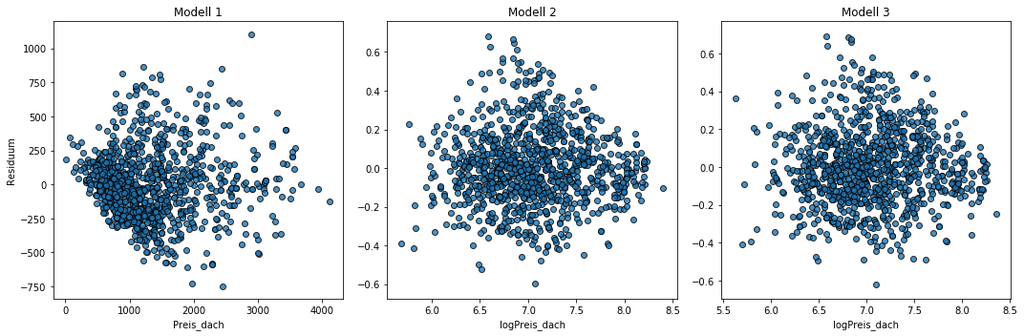

```python
fig, (ax1, ax2, ax3) = plt.subplots(1,3, figsize=(15,5))
ax1.scatter(x.fit_mod_lin0_z, x.resid_mod_lin0_z, edgecolor="black", alpha=0.8,label="Preis")
ax2.scatter(x.fit_mod_log0_z, x.resid_mod_log0_z, edgecolor="black", alpha=0.8, label="logPreis")
ax3.scatter(x.fit_mod_logn0_z, x.resid_mod_logn0_z, edgecolor="black", alpha=0.8, label="logPreis")
ax1.set_ylabel("Residuum")
ax1.set_xlabel("Preis_dach")
ax1.set_title("Modell 1")
ax2.set_xlabel("logPreis_dach")
ax2.set_xlabel("logPreis_dach")
ax2.set_title("Modell 2")
ax3.set_xlabel("logPreis_dach")
ax3.set_title("Modell 3")
plt.tight_layout()
plt.savefig("residuen_ols_log_ols");
```

### Residuen Plot Modelle 1-3 reduziert

Zurück zu Induktive Statistik

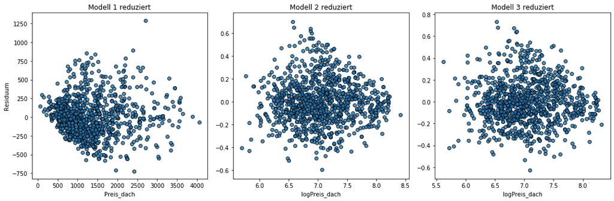

```python
fig, (ax1, ax2, ax3) = plt.subplots(1,3, figsize=(15,5))
ax1.scatter(x.fit_mod_lin1_z, x.resid_mod_lin1_z, edgecolor="black", alpha=0.8,label="Preis")
ax2.scatter(x.fit_mod_log1_z, x.resid_mod_log1_z, edgecolor="black", alpha=0.8, label="logPreis")
ax3.scatter(x.fit_mod_logn1_z, x.resid_mod_logn1_z, edgecolor="black", alpha=0.8, label="logPreis")
ax1.set_ylabel("Residuum")
ax1.set_xlabel("Preis_dach")
ax1.set_title("Modell 1 reduziert")
ax2.set_xlabel("logPreis_dach")
ax2.set_xlabel("logPreis_dach")
ax2.set_title("Modell 2 reduziert")
ax3.set_xlabel("logPreis_dach")
ax3.set_title("Modell 3 reduziert")
plt.tight_layout()
plt.savefig("residuen_ols_log_ols_red");
```

### Kreuzvalidierung

Zurück zu Induktive Statistik

Es wird eine Funktion erstellt, mit deren Hilfe die Bestimmtheitsmaße aus den logarithmierten und linearen Modellen verglichen werden können. Für die logarithmierten Preise wird also die Approximation aus Wooldrige (2012, S.214) verwendet

```python
def kreuzval(unabh, abh, ja_nein):
    from sklearn.metrics import r2_score
    from sklearn.model_selection import KFold
    daten = unabh.copy().reset_index(drop=True).values
    Preis = abh.copy().reset_index(drop=True).values
    Preis_lin = y.Preis.copy().reset_index(drop=True).values
# Datensatz wird in fünf Teile unterteilt, shuffle= ja_nein bietet die Option,
# dass die Werte zufällig in Gruppen unterteilt werden:
    kf = KFold(n_splits=5, shuffle=ja_nein)
    r_sq_preis, gesamt_rsqu, gesamt_adj_rsqu = [],[], []
    i=1
# Die abhängigen und unabhängigen Merkmale werden nach Indizes unterteilt
    for train_index, test_index in kf.split(daten):
        X_train, X_test = daten[train_index], daten[test_index]
        y_train, y_test = Preis[train_index], Preis[test_index]
        y_train_lin, y_test_lin = Preis_lin[train_index], Preis_lin[test_index]
# Regression wird durchgeführt
        reg = LinearRegression().fit(X_train, y_train)
        test, train = pd.DataFrame(), pd.DataFrame()
# Test-Daten werden geschätzt (ersten 208 Observationen)
        test["schätzungen_test"], train["schätzungen_train"] = reg.predict(X_test),reg.predict(X_train)
        test["y_test"], train["y_train"] = y_test, y_train
        test["y_test_lin"], train["y_train_lin"] = y_test_lin, y_train_lin
# Bestimmtheitsmaß ergibt sich aus quadriertem Korrelationskoeffizienten
        in_sample = train["schätzungen_train"].corr(train["y_train"])**2
        out_of_sample = test["schätzungen_test"].corr(test["y_test"])**2
# Hier ist der Teil der sich auf Wooldrige S.214 bezieht
        if abh.equals(y.Log_Preis):
            in_sample = train["y_train_lin"].corr(np.exp(train["schätzungen_train"]))**2
            out_of_sample = test["y_test_lin"].corr(np.exp(test["schätzungen_test"]))**2
        adj_in_sample = 1-(1-in_sample)*(len(daten)-1)/(len(daten)-(len(unabh.columns))-1)
        adj_out_of_sample = 1-(1-out_of_sample)*(len(daten)-1)/(len(daten)-(len(unabh.columns))-1)
        r_sq_preis.append(["R2-train,{} Regression:".format(i), in_sample,"R2-test,{} Regression:".format(i),out_of_sample])
        gesamt_rsqu.append(out_of_sample)
        gesamt_adj_rsqu.append(adj_out_of_sample)
        i+=1
    for Regression in r_sq_preis:
        print(Regression)
    print("\nDurchschnitt Bestimmtheitsmaß Test-Datensätze:", sum(gesamt_rsqu) / len(gesamt_rsqu))
    print("\nDurchschnitt adj. Bestimmtheitsmaß Test-Datensätze:", sum(gesamt_adj_rsqu) / len(gesamt_adj_rsqu))
```

Der Datensatz wurde in fünf Gruppen unterteilt. Für die Gruppen ergeben sich also 208 Observationen, für die letzte Gruppe 207. Es wird anhand von Modell1 und Modell2 überprüft, ob die oben erstellte Funktion den Werten einer Regression in einem anderen Python-Modul entsprechen

**Die folgenden Schritte dienen lediglich dazu, zu überprüfen, ob die obenstehende Funktion *kreuzval* richtig erstellt wurde. Angewendet wird die Funktion darunter**

**Überprüfung Modell1**

```python
kreuzval(x_zentriert1, y.Preis, False)
```

```
['R2-train,1 Regression:', 0.8969433643691942, 'R2-test,1 Regression:', 0.8106956559369656]
['R2-train,2 Regression:', 0.8908369972930695, 'R2-test,2 Regression:', 0.8561903991321893]
['R2-train,3 Regression:', 0.891639149375759, 'R2-test,3 Regression:', 0.8574012796270066]
['R2-train,4 Regression:', 0.8857818551784511, 'R2-test,4 Regression:', 0.8759368104109732]
['R2-train,5 Regression:', 0.8698654430437649, 'R2-test,5 Regression:', 0.9257673794859109]

Durchschnitt Bestimmtheitsmaß Test-Datensätze: 0.8651983049186092

Durchschnitt adj. Bestimmtheitsmaß Test-Datensätze: 0.859654804920277
```

Die erste Regression "['R2-train,1 Regression:', 0.8969433643691942, 'R2-test,1 Regression:', 0.8106956559369656]" wird abgeglichen mithilfe eines anderen Python-Moduls, welches bisher Anwendung gefunden hat. Es werden also die Ergebnisse von Statsmodels mit denen von Scikit verglichen:

```python
def überprüfung():
    model = sm.OLS(y.Preis.tail(831), x_zentriert1.tail(831))
    mod = model.fit()
    print("R2-train,1 Regression:", mod.rsquared)
    print("R2-test,1 Regression:",y.Preis.head(208).corr(mod.predict(x_zentriert1.head(208)))**2)
überprüfung()
```

```
R2-train,1 Regression: 0.8969433643691942
R2-test,1 Regression: 0.8106956559046014
```

Die Regressionen beider Module liefern also dasselbe Ergebnis

**Überprüfung Modell2**

```python
kreuzval(x_zentriert1, y.Log_Preis, False)
```

```
['R2-train,1 Regression:', 0.8883469556847965, 'R2-test,1 Regression:', 0.815091409334155]
['R2-train,2 Regression:', 0.8842523156347785, 'R2-test,2 Regression:', 0.8354759195081171]
['R2-train,3 Regression:', 0.886029230025885, 'R2-test,3 Regression:', 0.8511846718444118]
['R2-train,4 Regression:', 0.8787533202027488, 'R2-test,4 Regression:', 0.8778489287144409]
['R2-train,5 Regression:', 0.8652112488264458, 'R2-test,5 Regression:', 0.9195239750215249]

Durchschnitt Bestimmtheitsmaß Test-Datensätze: 0.85982498088453

Durchschnitt adj. Bestimmtheitsmaß Test-Datensätze: 0.8540605116932216
```

Die erste Regression ['R2-train,1 Regression:', 0.8883469556847965, 'R2-test,1 Regression:', 0.815091409334155] wird wieder abgeglichen

```python
def andere_überprüfung():
    model = sm.OLS(y.Log_Preis.tail(831), x_zentriert1.tail(831))
    mod = model.fit()
    temp = pd.DataFrame()
    temp["fit"]= np.exp(mod.predict(x_zentriert1)).head(208)
    print("R2-train,1 Regression:", y.Preis.tail(831).corr(np.exp(mod.fittedvalues))**2)
    print("R2-test,1 Regression", y.Preis.head(208).corr(temp.fit)**2)
andere_überprüfung()
```

```
R2-train,1 Regression: 0.8883469557314146
R2-test,1 Regression 0.8150914093093111
```

Es ergeben sich für sowohl Lin-Lin (oder Modell1) als auch Log-Lin (Modell2) dieselben Werte , weshalb kann angenommen werden, dass die Funktion richtig erstellt wurde. **Da sich der Datensatz allerdings immer noch in der selben Reihenfolge befindet, in der er von Alternate.de runtergeladen wurde, und dort vermutlich die Daten nicht in zufälliger Reihenfolge angeboten werden, werden die Klassen der Kreuzvalidierung zufällig gewählt. Was auffällig ist: Die Preise der Laptops, die auf den hinteren Seiten aufgeführt werden, lassen sich besser erklären**

Die Ergebnisse der oben genannte Funktion, die unten abgebildet sind befinden sich in der Arbeit auf Seite 27, allerdings sind die Ergebnisse anders, da die Klassen der Kreuzvalidierung zufällig gewählt werden

#### Modell1

**zentriertes und nicht gekürztes Modell1**

```python
kreuzval(x_zentriert1,y.Preis, True)
```

```
['R2-train,1 Regression:', 0.8896484105114979, 'R2-test,1 Regression:', 0.8628156179207908]
['R2-train,2 Regression:', 0.8844745586266287, 'R2-test,2 Regression:', 0.8818976301072396]
['R2-train,3 Regression:', 0.8823863308995948, 'R2-test,3 Regression:', 0.8907751915939155]
['R2-train,4 Regression:', 0.8928962337739647, 'R2-test,4 Regression:', 0.8464704953405596]
['R2-train,5 Regression:', 0.8833985656141589, 'R2-test,5 Regression:', 0.8892361910449947]

Durchschnitt Bestimmtheitsmaß Test-Datensätze: 0.8742390252015001

Durchschnitt adj. Bestimmtheitsmaß Test-Datensätze: 0.8690673100894253
```

#### zentriertes und gekürztes Modell1:

```python
kreuzval(x_zentriert2,y.Preis, True)
```

```
['R2-train,1 Regression:', 0.8811983111117142, 'R2-test,1 Regression:', 0.8904158819881294]
['R2-train,2 Regression:', 0.887175517257734, 'R2-test,2 Regression:', 0.8643937092601707]
['R2-train,3 Regression:', 0.884252948120156, 'R2-test,3 Regression:', 0.8751826842871829]
['R2-train,4 Regression:', 0.8809576132911684, 'R2-test,4 Regression:', 0.8947677453270528]
['R2-train,5 Regression:', 0.8877796675373032, 'R2-test,5 Regression:', 0.8613655395145804]

Durchschnitt Bestimmtheitsmaß Test-Datensätze: 0.8772251120754232

Durchschnitt adj. Bestimmtheitsmaß Test-Datensätze: 0.8740708165358588
```

#### Modell2

#### zentriertes und nicht gekürztes Modell2

```python
kreuzval(x_zentriert1,y.Log_Preis, True)
```

```
['R2-train,1 Regression:', 0.8753562439177369, 'R2-test,1 Regression:', 0.8830340118446075]
['R2-train,2 Regression:', 0.8813073566607543, 'R2-test,2 Regression:', 0.8632605456810831]
['R2-train,3 Regression:', 0.8852125740023745, 'R2-test,3 Regression:', 0.8508758346152868]
['R2-train,4 Regression:', 0.8828510475270008, 'R2-test,4 Regression:', 0.8643632639286921]
['R2-train,5 Regression:', 0.8760413596675257, 'R2-test,5 Regression:', 0.8774602059362812]

Durchschnitt Bestimmtheitsmaß Test-Datensätze: 0.8677987724011903

Durchschnitt adj. Bestimmtheitsmaß Test-Datensätze: 0.8623622123896043
```

#### zentriertes und gekürztes Modell2:

```python
kreuzval(x_zentriert3,y.Log_Preis, True)
```

```
['R2-train,1 Regression:', 0.8799449568515673, 'R2-test,1 Regression:', 0.8742506518066501]
['R2-train,2 Regression:', 0.8760229601457507, 'R2-test,2 Regression:', 0.895028821487362]
['R2-train,3 Regression:', 0.8828470437854512, 'R2-test,3 Regression:', 0.8654184871799119]
['R2-train,4 Regression:', 0.8798796974815367, 'R2-test,4 Regression:', 0.8666743255016278]
['R2-train,5 Regression:', 0.8849410582764706, 'R2-test,5 Regression:', 0.8573491020544027]

Durchschnitt Bestimmtheitsmaß Test-Datensätze: 0.8717442776059908

Durchschnitt adj. Bestimmtheitsmaß Test-Datensätze: 0.8676645727187063
```

#### Modell3

#### zentriertes und nicht gekürztes Modell3

```python
kreuzval(x_neu2,y.Log_Preis, True)
```

```
['R2-train,1 Regression:', 0.8641113464002071, 'R2-test,1 Regression:', 0.8530326808976857]
['R2-train,2 Regression:', 0.8698124224683011, 'R2-test,2 Regression:', 0.8347622607904829]
['R2-train,3 Regression:', 0.8595201035682958, 'R2-test,3 Regression:', 0.8792538930569677]
['R2-train,4 Regression:', 0.8658635504044163, 'R2-test,4 Regression:', 0.8525283636075279]
['R2-train,5 Regression:', 0.8613818217955702, 'R2-test,5 Regression:', 0.8540013090463068]

Durchschnitt Bestimmtheitsmaß Test-Datensätze: 0.8547157014797943

Durchschnitt adj. Bestimmtheitsmaß Test-Datensätze: 0.8500943321431673
```

#### zentriertes und gekürztes Modell3

```python
kreuzval(x_neu3,y.Log_Preis, True)
```

```
['R2-train,1 Regression:', 0.8576793783113561, 'R2-test,1 Regression:', 0.8822499671302843]
['R2-train,2 Regression:', 0.8668818347531115, 'R2-test,2 Regression:', 0.8447802307614317]
['R2-train,3 Regression:', 0.8606649167489482, 'R2-test,3 Regression:', 0.8732670032883489]
['R2-train,4 Regression:', 0.8662140419469013, 'R2-test,4 Regression:', 0.846197137420691]
['R2-train,5 Regression:', 0.8656822642240113, 'R2-test,5 Regression:', 0.8506122997688251]

Durchschnitt Bestimmtheitsmaß Test-Datensätze: 0.8594213276739161

Durchschnitt adj. Bestimmtheitsmaß Test-Datensätze: 0.8563773013046507
```

### Modellauswahl und Darstellung

#### Erstellen einer Gesamtübersicht für Modell1

Zurück zu Induktive Statistik

Nach den Bestimmtheitsmaßen der Kreuzvalidierungen bezüglich des Preises zu schließen, kann Modell1 den Zusammenhang der Merkmale und dem Preis am besten erklären.

In den folgenden Schritten wird ein Schaubild zur Darstellung der Ergebnisse erstellt. Das Resulat der folgenden Schritte wurde **hier** in der Funktion *Übersicht* zusammengefasst.

```python
xl = pd.DataFrame()
xl["fit_mod_lin0_z"] = x.fit_mod_lin1_z
xl["Preis"] = y.Preis
```

```python
x
```

| Laptop_ID | Kerne | Takt_Prozessor | Arbeitsspeicher | Bild_Display | Speicher_Grafik | extern_Schnittstellen | HDD | SSD | Akku_Kapazität | PPI_Display | Pixelshader | Typ_Arbeitsspeicher_DDR_4 | Laufwerk_VORHANDEN | Lautsprecher_ÜBERDURCHSCHN_LAUTSPRECHER | Tastatur_Beleuchtung_vorhanden | Fingerabdrucksensor_vorhanden | Touchscreen_vorhanden | Mobilfunk_vorhanden | NFC_vorhanden | Akku_Typ_ION | Marke_ASUS | Marke_Acer | Marke_Apple | Marke_Dell | Marke_Lenovo | Betriebssystem_DOS | Betriebssystem_LINUX | Betriebssystem_OHNE_BETRIEBSSYSTEM | Mikrofon_Sound_vorhanden | … |
| --- | --- | --- | --- | --- | --- | --- | --- | --- | --- | --- | --- | --- | --- | --- | --- | --- | --- | --- | --- | --- | --- | --- | --- | --- | --- | --- | --- | --- | --- | --- |
| 2 | 2 | 2600 | 8 | 15.6 | 0 | 6 | 0 | 256 | 41.0 | 141 | 192.0 | 1 | 1 | 0 | 0 | 0 | 0 | 0 | 0 | 1 | 0 | 0 | 0 | 0 | 0 | 0 | 0 | 1 | 1 | … |
| 4 | 6 | 2200 | 8 | 15.6 | 6144 | 9 | 1000 | 128 | 70.0 | 141 | 1280.0 | 1 | 0 | 0 | 1 | 0 | 0 | 0 | 0 | 1 | 0 | 0 | 0 | 0 | 0 | 0 | 0 | 0 | 1 | … |
| ... | ... | ... | ... | ... | ... | ... | ... | ... | ... | ... | ... | ... | ... | ... | ... | ... | ... | ... | ... | ... | ... | ... | ... | ... | ... | ... | ... | ... | ... | … |
| 1747 | 4 | 2300 | 8 | 15.6 | 4096 | 7 | 1000 | 128 | 48.0 | 141 | 640.0 | 1 | 0 | 0 | 1 | 0 | 0 | 0 | 0 | 1 | 0 | 1 | 0 | 0 | 0 | 0 | 0 | 0 | 1 | … |
| 1748 | 4 | 2300 | 16 | 15.6 | 6144 | 6 | 0 | 512 | 48.0 | 141 | 1920.0 | 1 | 0 | 0 | 1 | 0 | 0 | 0 | 0 | 1 | 1 | 0 | 0 | 0 | 0 | 0 | 0 | 0 | 1 | … |

1039 rows × 90 columns

```python
modell_parameter = mod_lin1_z.params.to_frame(name="beta").reset_index().rename_axis(None).rename(columns={"index": "Merkmal"})
modell_parameter
```

|  | Merkmal | beta |
| --- | --- | --- |
| 0 | Kerne_z | 94.194187 |
| 1 | Kerne_z_quad | 12.769128 |
| ... | ... | ... |
| 24 | Typ_Arbeitsspeicher_DDR_4 | -108.885931 |
| 25 | Konstante | 1171.141911 |

26 rows × 2 columns

```python
for Merkmal in list(modell_parameter.Merkmal):
    xl["{}_geschätzt".format(Merkmal)]= x[Merkmal].apply(lambda x: x*modell_parameter[modell_parameter.Merkmal == Merkmal].beta)
```

Die Merkmalsausprägungen werden mit den zugehörigen Paramtern multipliziert, um den Anteil der Schätzungen zu bekommen

Für das Merkmal _Kerne*z* des ersten Merkmalsträgers ergibt sich: **94,19*-2,239 = -210,89**

Für das Merkmal _Kerne_quad*z* des ersten Merkmalsträgers ergibt sichergibt sich: **12,77*5,012=64,00**

Für den ersten Merkmalsträger reduziert also die geringe Anzahl an Kernen den Preis um **-210,89 + 64,00 = -146,9**

**Die ersten zwei Merkmalsträger aus dem ursprünglichen Datensatz:**

```python
x.head(2)
```

| Laptop_ID | Kerne | Takt_Prozessor | Arbeitsspeicher | Bild_Display | Speicher_Grafik | extern_Schnittstellen | HDD | SSD | Akku_Kapazität | PPI_Display | Pixelshader | Typ_Arbeitsspeicher_DDR_4 | Laufwerk_VORHANDEN | Lautsprecher_ÜBERDURCHSCHN_LAUTSPRECHER | Tastatur_Beleuchtung_vorhanden | Fingerabdrucksensor_vorhanden | Touchscreen_vorhanden | Mobilfunk_vorhanden | NFC_vorhanden | Akku_Typ_ION | Marke_ASUS | Marke_Acer | Marke_Apple | Marke_Dell | Marke_Lenovo | Betriebssystem_DOS | Betriebssystem_LINUX | Betriebssystem_OHNE_BETRIEBSSYSTEM | Mikrofon_Sound_vorhanden | … |
| --- | --- | --- | --- | --- | --- | --- | --- | --- | --- | --- | --- | --- | --- | --- | --- | --- | --- | --- | --- | --- | --- | --- | --- | --- | --- | --- | --- | --- | --- | --- |
| 2 | 2 | 2600 | 8 | 15.6 | 0 | 6 | 0 | 256 | 41.0 | 141 | 192.0 | 1 | 1 | 0 | 0 | 0 | 0 | 0 | 0 | 1 | 0 | 0 | 0 | 0 | 0 | 0 | 0 | 1 | 1 | … |
| 4 | 6 | 2200 | 8 | 15.6 | 6144 | 9 | 1000 | 128 | 70.0 | 141 | 1280.0 | 1 | 0 | 0 | 1 | 0 | 0 | 0 | 0 | 1 | 0 | 0 | 0 | 0 | 0 | 0 | 0 | 0 | 1 | … |

**In dieser Tabelle sind die Einzelwerte aus der eben genannten Rechnung eingetragen:**

```python
xl.head(2)
```

| Laptop_ID | fit_mod_lin0_z | Preis | Kerne_z_geschätzt | Kerne_z_quad_geschätzt | Takt_Prozessor_z_geschätzt | Takt_Prozessor_z_quad_geschätzt | Arbeitsspeicher_z_geschätzt | Bild_Display_z_quad_geschätzt | Speicher_Grafik_z_geschätzt | Speicher_Grafik_z_quad_geschätzt | HDD_z_geschätzt | HDD_z_quad_geschätzt | SSD_z_geschätzt | Akku_Kapazität_z_geschätzt | PPI_Display_z_geschätzt | Pixelshader_z_geschätzt | Pixelshader_z_quad_geschätzt | Tastatur_Beleuchtung_vorhanden_geschätzt | Touchscreen_vorhanden_geschätzt | Mobilfunk_vorhanden_geschätzt | NFC_vorhanden_geschätzt | Marke_Apple_geschätzt | Marke_Lenovo_geschätzt | Betriebssystem_DOS_geschätzt | Betriebssystem_OHNE_BETRIEBSSYSTEM_geschätzt | Lautsprecher_ÜBERDURCHSCHN_LAUTSPRECHER_geschätzt | Typ_Arbeitsspeicher_DDR_4_geschätzt | Konstante_geschätzt |
| --- | --- | --- | --- | --- | --- | --- | --- | --- | --- | --- | --- | --- | --- | --- | --- | --- | --- | --- | --- | --- | --- | --- | --- | --- | --- | --- | --- | --- |
| 2 | 345.804516 | 299.0 | -210.871682 | 63.995521 | 82.450236 | 47.110689 | -115.852365 | 2.694378 | -73.433371 | -50.866449 | -17.948840 | -7.698403 | -45.618445 | -180.911802 | -35.692567 | 50.850248 | 17.999922 | 0.000000 | 0.0 | 0.0 | 0.0 | 0.0 | 0.0 | -0.0 | -242.658534 | 0.0 | -108.885931 | 1171.141911 |
| 4 | 1269.259661 | 899.0 | 165.905064 | 39.612508 | 26.404573 | 4.831633 | -115.852365 | 2.694378 | 153.641844 | -222.670928 | 74.944247 | -134.216056 | -88.008664 | 193.733626 | -35.692567 | -149.609892 | 155.813507 | 135.472772 | 0.0 | 0.0 | 0.0 | 0.0 | 0.0 | -0.0 | -0.000000 | 0.0 | -108.885931 | 1171.141911 |

**die Werte aus erstem und zweiten Grad der Merkmale werden zusammengefasst**

```python
for Merkmal in list(xl.columns):
# es werden nur quadratische Merkmale betrachtet
    if "_quad" in Merkmal:
# die Merkmale werden jeweils bei _quad geteilt. Für Kerne_z_quad_geschätzt ergibt sich: "Kerne_z" und "_geschätzt"
        Merkmal_neu = Merkmal.split("_quad")[0]
        try:
            xl[Merkmal_neu] = xl["{}_geschätzt".format(Merkmal_neu)]+xl[Merkmal]
            del xl[Merkmal], xl["{}_geschätzt".format(Merkmal_neu)]
        except KeyError:
            continue
```

**In dieser Tabelle sind die Summen der Werte aus den Termen ersten und zweiten Grades eingetragen (-146,9 für Kerne)**

```python
xl.head(2)
```

| Laptop_ID | fit_mod_lin0_z | Preis | Arbeitsspeicher_z_geschätzt | Bild_Display_z_quad_geschätzt | SSD_z_geschätzt | Akku_Kapazität_z_geschätzt | PPI_Display_z_geschätzt | Tastatur_Beleuchtung_vorhanden_geschätzt | Touchscreen_vorhanden_geschätzt | Mobilfunk_vorhanden_geschätzt | NFC_vorhanden_geschätzt | Marke_Apple_geschätzt | Marke_Lenovo_geschätzt | Betriebssystem_DOS_geschätzt | Betriebssystem_OHNE_BETRIEBSSYSTEM_geschätzt | Lautsprecher_ÜBERDURCHSCHN_LAUTSPRECHER_geschätzt | Typ_Arbeitsspeicher_DDR_4_geschätzt | Konstante_geschätzt | Kerne_z | Takt_Prozessor_z | Speicher_Grafik_z | HDD_z | Pixelshader_z |
| --- | --- | --- | --- | --- | --- | --- | --- | --- | --- | --- | --- | --- | --- | --- | --- | --- | --- | --- | --- | --- | --- | --- | --- |
| 2 | 345.804516 | 299.0 | -115.852365 | 2.694378 | -45.618445 | -180.911802 | -35.692567 | 0.000000 | 0.0 | 0.0 | 0.0 | 0.0 | 0.0 | -0.0 | -242.658534 | 0.0 | -108.885931 | 1171.141911 | -146.876161 | 129.560925 | -124.299820 | -25.647243 | 68.850170 |
| 4 | 1269.259661 | 899.0 | -115.852365 | 2.694378 | -88.008664 | 193.733626 | -35.692567 | 135.472772 | 0.0 | 0.0 | 0.0 | 0.0 | 0.0 | -0.0 | -0.000000 | 0.0 | -108.885931 | 1171.141911 | 205.517572 | 31.236207 | -69.029083 | -59.271809 | 6.203615 |

**Zur Veranschlaulichung wird eine Klasse für die zwei billigsten Laptops erstellt. Die beiden billigsten Laptops haben folgende Werte:**

```python
x["Preis"] = y.Preis
x[x.Preis<220]
```

| Laptop_ID | Kerne | Takt_Prozessor | Arbeitsspeicher | Bild_Display | Speicher_Grafik | extern_Schnittstellen | HDD | SSD | Akku_Kapazität | PPI_Display | Pixelshader | Typ_Arbeitsspeicher_DDR_4 | Laufwerk_VORHANDEN | Lautsprecher_ÜBERDURCHSCHN_LAUTSPRECHER | Tastatur_Beleuchtung_vorhanden | Fingerabdrucksensor_vorhanden | Touchscreen_vorhanden | Mobilfunk_vorhanden | NFC_vorhanden | Akku_Typ_ION | Marke_ASUS | Marke_Acer | Marke_Apple | Marke_Dell | Marke_Lenovo | Betriebssystem_DOS | Betriebssystem_LINUX | Betriebssystem_OHNE_BETRIEBSSYSTEM | Mikrofon_Sound_vorhanden | … |
| --- | --- | --- | --- | --- | --- | --- | --- | --- | --- | --- | --- | --- | --- | --- | --- | --- | --- | --- | --- | --- | --- | --- | --- | --- | --- | --- | --- | --- | --- | --- |
| 5 | 2 | 2300 | 4 | 15.6 | 0 | 6 | 0 | 128 | 41.0 | 100 | 128.0 | 1 | 1 | 0 | 0 | 0 | 0 | 0 | 0 | 1 | 0 | 0 | 0 | 0 | 0 | 0 | 0 | 1 | 1 | … |
| 598 | 2 | 2300 | 4 | 15.6 | 0 | 5 | 0 | 256 | 30.0 | 100 | 128.0 | 1 | 0 | 0 | 0 | 0 | 0 | 0 | 0 | 0 | 0 | 0 | 0 | 0 | 1 | 0 | 0 | 1 | 1 | … |

**Die beiden Laptops haben folgende geschätze Werte:**

```python
xl[xl.Preis<220]
```

| Laptop_ID | fit_mod_lin0_z | Preis | Arbeitsspeicher_z_geschätzt | Bild_Display_z_quad_geschätzt | SSD_z_geschätzt | Akku_Kapazität_z_geschätzt | PPI_Display_z_geschätzt | Tastatur_Beleuchtung_vorhanden_geschätzt | Touchscreen_vorhanden_geschätzt | Mobilfunk_vorhanden_geschätzt | NFC_vorhanden_geschätzt | Marke_Apple_geschätzt | Marke_Lenovo_geschätzt | Betriebssystem_DOS_geschätzt | Betriebssystem_OHNE_BETRIEBSSYSTEM_geschätzt | Lautsprecher_ÜBERDURCHSCHN_LAUTSPRECHER_geschätzt | Typ_Arbeitsspeicher_DDR_4_geschätzt | Konstante_geschätzt | Kerne_z | Takt_Prozessor_z | Speicher_Grafik_z | HDD_z | Pixelshader_z |
| --- | --- | --- | --- | --- | --- | --- | --- | --- | --- | --- | --- | --- | --- | --- | --- | --- | --- | --- | --- | --- | --- | --- | --- |
| 5 | 52.171737 | 199.0 | -236.222972 | 2.694378 | -88.008664 | -180.911802 | -109.847251 | 0.0 | 0.0 | 0.0 | 0.0 | 0.0 | 0.000000 | -0.0 | -242.658534 | 0.0 | -108.885931 | 1171.141911 | -146.876161 | 51.735876 | -124.29982 | -25.647243 | 89.957951 |
| 598 | 140.691662 | 219.9 | -236.222972 | 2.694378 | -45.618445 | -323.018689 | -109.847251 | 0.0 | 0.0 | 0.0 | 0.0 | 0.0 | 188.236592 | -0.0 | -242.658534 | 0.0 | -108.885931 | 1171.141911 | -146.876161 | 51.735876 | -124.29982 | -25.647243 | 89.957951 |

```python
xl["Preis"] = y.Preis
preisklassen = [0,220,750,1500,2250,4000]
xl["Preisspanne"] = pd.cut(xl["Preis"], preisklassen)
gruppiert = xl.groupby("Preisspanne").sum()
gruppiert = gruppiert.replace(np.nan,0)
gruppiert
```

| Preisspanne | fit_mod_lin0_z | Preis | Arbeitsspeicher_z_geschätzt | Bild_Display_z_quad_geschätzt | SSD_z_geschätzt | Akku_Kapazität_z_geschätzt | PPI_Display_z_geschätzt | Tastatur_Beleuchtung_vorhanden_geschätzt | Touchscreen_vorhanden_geschätzt | Mobilfunk_vorhanden_geschätzt | NFC_vorhanden_geschätzt | Marke_Apple_geschätzt | Marke_Lenovo_geschätzt | Betriebssystem_DOS_geschätzt | Betriebssystem_OHNE_BETRIEBSSYSTEM_geschätzt | Lautsprecher_ÜBERDURCHSCHN_LAUTSPRECHER_geschätzt | Typ_Arbeitsspeicher_DDR_4_geschätzt | Konstante_geschätzt | Kerne_z | Takt_Prozessor_z | Speicher_Grafik_z | HDD_z | Pixelshader_z |
| --- | --- | --- | --- | --- | --- | --- | --- | --- | --- | --- | --- | --- | --- | --- | --- | --- | --- | --- | --- | --- | --- | --- | --- |
| (0, 220] | 192.863399 | 418.90 | -472.445943 | 5.388756 | -133.627109 | -503.930492 | -219.694502 | 0.000000 | 0.000000 | 0.000000 | 0.000000 | 0.000000 | 188.236592 | 0.000000 | -485.317068 | 0.000000 | -217.771862 | 2342.283822 | -293.752322 | 103.471751 | -248.599640 | -51.294485 | 179.915901 |
| (220, 750] | 163221.058488 | 148371.54 | -31250.132702 | 3268.864427 | -12514.705031 | -42531.795418 | -9632.132813 | 11379.712852 | 2206.237121 | 340.916731 | 0.000000 | 0.000000 | 9976.539396 | -3959.299417 | -5581.146281 | 270.009157 | -26785.939070 | 292785.477792 | -17700.746635 | 4138.874821 | -25713.631585 | -7991.781934 | 22515.737076 |
| (750, 1500] | 517685.093578 | 489023.38 | -19860.686730 | 8254.775489 | -7929.543906 | -19031.992744 | -6673.315817 | 50395.871203 | 7170.270642 | 9204.751738 | 274.499743 | 7152.134212 | 16941.293315 | -1319.766472 | -5095.829213 | 2430.082413 | -42574.399090 | 530527.285760 | 1255.647263 | 812.966711 | -28819.568287 | -15485.026066 | 30055.643416 |
| (1500, 2250] | 353902.859695 | 378148.10 | 11879.964884 | 3480.693006 | 6684.968698 | 22329.261696 | 5506.358280 | 24385.098969 | 4018.503327 | 13295.752510 | 3568.496657 | 7663.000942 | 12423.615097 | -439.922157 | -1213.292670 | 2835.096148 | -17312.863057 | 240084.091790 | 9628.608993 | 6036.377575 | -16315.056877 | -6855.861163 | 22219.967047 |
| (2250, 4000] | 349851.044735 | 368891.00 | 39703.300490 | 1262.447984 | 13892.907347 | 39738.456958 | 11018.784853 | 16934.096506 | 2048.648755 | 5795.584427 | 3568.496657 | 20434.669178 | 6023.570956 | 0.000000 | 0.000000 | 2025.068677 | -12630.768017 | 151077.306541 | 29951.718650 | 12162.227392 | -6053.939342 | -4057.145661 | 16955.612381 |

**Die Merkmalsausprägungen lassen sich untergliedern in solche, die den Preis erhöhen (anteil_positiv) und solche, die den Preis verringern (anteil_negativ), der Preis, der zum Klassieren verwendet wurde, muss vorher noch gelöscht werden:**

```python
gruppiert = gruppiert.drop("Preis", axis=1)
gruppiert["anteil_positiv"] = gruppiert.where(gruppiert > 0).sum(axis=1)
gruppiert["anteil_negativ"] = gruppiert.where(gruppiert<0).sum(axis=1)
gruppiert
```

| Preisspanne | fit_mod_lin0_z | Arbeitsspeicher_z_geschätzt | Bild_Display_z_quad_geschätzt | SSD_z_geschätzt | Akku_Kapazität_z_geschätzt | PPI_Display_z_geschätzt | Tastatur_Beleuchtung_vorhanden_geschätzt | Touchscreen_vorhanden_geschätzt | Mobilfunk_vorhanden_geschätzt | NFC_vorhanden_geschätzt | Marke_Apple_geschätzt | Marke_Lenovo_geschätzt | Betriebssystem_DOS_geschätzt | Betriebssystem_OHNE_BETRIEBSSYSTEM_geschätzt | Lautsprecher_ÜBERDURCHSCHN_LAUTSPRECHER_geschätzt | Typ_Arbeitsspeicher_DDR_4_geschätzt | Konstante_geschätzt | Kerne_z | Takt_Prozessor_z | Speicher_Grafik_z | HDD_z | Pixelshader_z | anteil_positiv | anteil_negativ |
| --- | --- | --- | --- | --- | --- | --- | --- | --- | --- | --- | --- | --- | --- | --- | --- | --- | --- | --- | --- | --- | --- | --- | --- | --- |
| (0, 220] | 192.863399 | -472.445943 | 5.388756 | -133.627109 | -503.930492 | -219.694502 | 0.000000 | 0.000000 | 0.000000 | 0.000000 | 0.000000 | 188.236592 | 0.000000 | -485.317068 | 0.000000 | -217.771862 | 2342.283822 | -293.752322 | 103.471751 | -248.599640 | -51.294485 | 179.915901 | 3.012160e+03 | -2626.433424 |
| (220, 750] | 163221.058488 | -31250.132702 | 3268.864427 | -12514.705031 | -42531.795418 | -9632.132813 | 11379.712852 | 2206.237121 | 340.916731 | 0.000000 | 0.000000 | 9976.539396 | -3959.299417 | -5581.146281 | 270.009157 | -26785.939070 | 292785.477792 | -17700.746635 | 4138.874821 | -25713.631585 | -7991.781934 | 22515.737076 | 5.101034e+05 | -183661.310886 |
| (750, 1500] | 517685.093578 | -19860.686730 | 8254.775489 | -7929.543906 | -19031.992744 | -6673.315817 | 50395.871203 | 7170.270642 | 9204.751738 | 274.499743 | 7152.134212 | 16941.293315 | -1319.766472 | -5095.829213 | 2430.082413 | -42574.399090 | 530527.285760 | 1255.647263 | 812.966711 | -28819.568287 | -15485.026066 | 30055.643416 | 1.182160e+06 | -146790.128327 |
| (1500, 2250] | 353902.859695 | 11879.964884 | 3480.693006 | 6684.968698 | 22329.261696 | 5506.358280 | 24385.098969 | 4018.503327 | 13295.752510 | 3568.496657 | 7663.000942 | 12423.615097 | -439.922157 | -1213.292670 | 2835.096148 | -17312.863057 | 240084.091790 | 9628.608993 | 6036.377575 | -16315.056877 | -6855.861163 | 22219.967047 | 7.499427e+05 | -42136.995925 |
| (2250, 4000] | 349851.044735 | 39703.300490 | 1262.447984 | 13892.907347 | 39738.456958 | 11018.784853 | 16934.096506 | 2048.648755 | 5795.584427 | 3568.496657 | 20434.669178 | 6023.570956 | 0.000000 | 0.000000 | 2025.068677 | -12630.768017 | 151077.306541 | 29951.718650 | 12162.227392 | -6053.939342 | -4057.145661 | 16955.612381 | 7.224439e+05 | -22741.853019 |

**Der preisliche Einfluss der einzelnen Komponenten wird durch den gesamten Einfluss geteilt:**

```python
gruppiert = gruppiert.div(gruppiert.anteil_positiv+gruppiert.anteil_negativ.abs(), axis=0)
gruppiert
```

| Preisspanne | fit_mod_lin0_z | Arbeitsspeicher_z_geschätzt | Bild_Display_z_quad_geschätzt | SSD_z_geschätzt | Akku_Kapazität_z_geschätzt | PPI_Display_z_geschätzt | Tastatur_Beleuchtung_vorhanden_geschätzt | Touchscreen_vorhanden_geschätzt | Mobilfunk_vorhanden_geschätzt | NFC_vorhanden_geschätzt | Marke_Apple_geschätzt | Marke_Lenovo_geschätzt | Betriebssystem_DOS_geschätzt | Betriebssystem_OHNE_BETRIEBSSYSTEM_geschätzt | Lautsprecher_ÜBERDURCHSCHN_LAUTSPRECHER_geschätzt | Typ_Arbeitsspeicher_DDR_4_geschätzt | Konstante_geschätzt | Kerne_z | Takt_Prozessor_z | Speicher_Grafik_z | HDD_z | Pixelshader_z | anteil_positiv | anteil_negativ |
| --- | --- | --- | --- | --- | --- | --- | --- | --- | --- | --- | --- | --- | --- | --- | --- | --- | --- | --- | --- | --- | --- | --- | --- | --- |
| (0, 220] | 0.034204 | -0.083788 | 0.000956 | -0.023699 | -0.089372 | -0.038963 | 0.000000 | 0.000000 | 0.000000 | 0.000000 | 0.000000 | 0.033384 | 0.000000 | -0.086071 | 0.000000 | -0.038622 | 0.415402 | -0.052097 | 0.018351 | -0.044089 | -0.009097 | 0.031908 | 0.534204 | -0.465796 |
| (220, 750] | 0.235269 | -0.045044 | 0.004712 | -0.018039 | -0.061306 | -0.013884 | 0.016403 | 0.003180 | 0.000491 | 0.000000 | 0.000000 | 0.014380 | -0.005707 | -0.008045 | 0.000389 | -0.038610 | 0.422024 | -0.025514 | 0.005966 | -0.037064 | -0.011519 | 0.032454 | 0.735269 | -0.264731 |
| (750, 1500] | 0.389544 | -0.014945 | 0.006211 | -0.005967 | -0.014321 | -0.005021 | 0.037922 | 0.005395 | 0.006926 | 0.000207 | 0.005382 | 0.012748 | -0.000993 | -0.003834 | 0.001829 | -0.032036 | 0.399208 | 0.000945 | 0.000612 | -0.021686 | -0.011652 | 0.022616 | 0.889544 | -0.110456 |
| (1500, 2250] | 0.446802 | 0.014998 | 0.004394 | 0.008440 | 0.028191 | 0.006952 | 0.030786 | 0.005073 | 0.016786 | 0.004505 | 0.009675 | 0.015685 | -0.000555 | -0.001532 | 0.003579 | -0.021857 | 0.303106 | 0.012156 | 0.007621 | -0.020598 | -0.008656 | 0.028053 | 0.946802 | -0.053198 |
| (2250, 4000] | 0.469482 | 0.053280 | 0.001694 | 0.018644 | 0.053327 | 0.014787 | 0.022725 | 0.002749 | 0.007777 | 0.004789 | 0.027422 | 0.008083 | 0.000000 | 0.000000 | 0.002718 | -0.016950 | 0.202738 | 0.040194 | 0.016321 | -0.008124 | -0.005444 | 0.022754 | 0.969482 | -0.030518 |

**Die Merkmale _anteil*negativ* und _anteil*positiv* sollen nicht Teil der Grafik sein**

```python
gruppiert = gruppiert.drop(["anteil_negativ", "anteil_positiv"], axis=1)
```

**In der Summe muss sich in den einzelnen Klassen also der Wert 1 ergeben, was der Fall ist:**

```python
gruppiert.abs().sum(axis=1).mean()
```

```
1.0
```

**Aus den übrigen Merkmalen lässt sich ein Graph erstellen:**

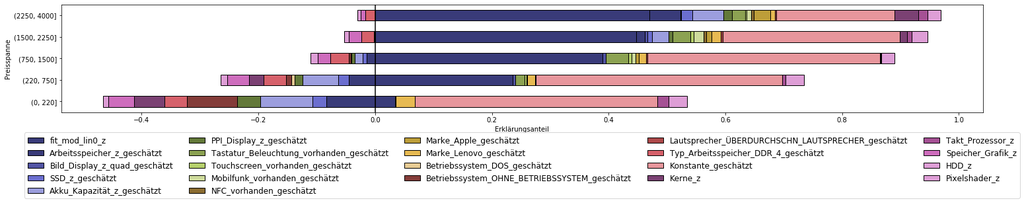

```python
fig,ax=plt.subplots(1,1, figsize=(25,3))
gruppiert.plot.barh(stacked= True, width=0.5, ax=ax, edgecolor= "black", legend= True, colormap="tab20b")
ax.set_xlabel("Erklärungsanteil")
ax.legend(loc='upper center', bbox_to_anchor=(0.5, -0.15), ncol=5, fontsize="large")
ax.axvline(x=0, color ="black");
```

**Der Graph ist ziemlich unübersichtlich es werden also nur Merkmale betrachtet, deren Einfluss größer als 2% des Gesamteinflusses ist.**

**Die Endungen "_geschätzt" und leere Spalten werden gelöscht:**

```python
gruppiert[gruppiert.abs()<0.02] =0
gruppiert = gruppiert.loc[:, (gruppiert != 0).any(axis=0)]
for Merkmal in gruppiert.columns:
    try:
        gruppiert = gruppiert.rename(columns= {Merkmal: Merkmal.split("_geschätzt")[0]})
    except Error:
        continue
```

**Bei den neuen Werten wurden vorherige Werte unter 0,02 durch 0 ersetzt:**

```python
gruppiert
```

| Preisspanne | fit_mod_lin0_z | Arbeitsspeicher_z | SSD_z | Akku_Kapazität_z | PPI_Display_z | Tastatur_Beleuchtung_vorhanden | Marke_Apple | Marke_Lenovo | Betriebssystem_OHNE_BETRIEBSSYSTEM | Typ_Arbeitsspeicher_DDR_4 | Konstante | Kerne_z | Speicher_Grafik_z | Pixelshader_z |
| --- | --- | --- | --- | --- | --- | --- | --- | --- | --- | --- | --- | --- | --- | --- |
| (0, 220] | 0.034204 | -0.083788 | -0.023699 | -0.089372 | -0.038963 | 0.000000 | 0.000000 | 0.033384 | -0.086071 | -0.038622 | 0.415402 | -0.052097 | -0.044089 | 0.031908 |
| (220, 750] | 0.235269 | -0.045044 | 0.000000 | -0.061306 | 0.000000 | 0.000000 | 0.000000 | 0.000000 | 0.000000 | -0.038610 | 0.422024 | -0.025514 | -0.037064 | 0.032454 |
| (750, 1500] | 0.389544 | 0.000000 | 0.000000 | 0.000000 | 0.000000 | 0.037922 | 0.000000 | 0.000000 | 0.000000 | -0.032036 | 0.399208 | 0.000000 | -0.021686 | 0.022616 |
| (1500, 2250] | 0.446802 | 0.000000 | 0.000000 | 0.028191 | 0.000000 | 0.030786 | 0.000000 | 0.000000 | 0.000000 | -0.021857 | 0.303106 | 0.000000 | -0.020598 | 0.028053 |
| (2250, 4000] | 0.469482 | 0.053280 | 0.000000 | 0.053327 | 0.000000 | 0.022725 | 0.027422 | 0.000000 | 0.000000 | 0.000000 | 0.202738 | 0.040194 | 0.000000 | 0.022754 |

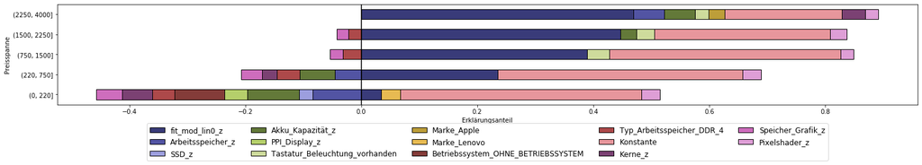

```python
fig,ax=plt.subplots(1,1, figsize=(25,3))
gruppiert.plot.barh(stacked= True, width=0.5, ax=ax, edgecolor= "black", legend= True, colormap="tab20b")
ax.set_xlabel("Erklärungsanteil")
ax.legend(loc='upper center', bbox_to_anchor=(0.5, -0.15), ncol=5, fontsize="large")
ax.axvline(x=0, color ="black");
```

**Die oben genannten Schritte lassen sich in einer Funktion zusammenfassen:**

```python
def übersicht(fit, modell, mini,maxi):
    xl = pd.DataFrame()
    xl["fit"] = fit
    modell_parameter = modell.params.to_frame(name="beta").reset_index().rename_axis(None).rename(columns={"index": "Merkmal"})
    for Merkmal in list(modell_parameter.Merkmal):
        xl["{}_geschätzt".format(Merkmal)]= x[Merkmal].apply(lambda x: x*modell_parameter[modell_parameter.Merkmal == Merkmal].beta)
    for Merkmal in list(xl.columns):
    # es werden nur quadratische Merkmale betrachtet
        if "_quad" in Merkmal:
    # die Merkmale werden jeweils bei _quad geteilt. Für Kerne_z_quad_geschätzt ergibt sich: "Kerne_z" und "_geschätzt"
            Merkmal_neu = Merkmal.split("_quad")[0]
            try:
                xl[Merkmal_neu] = xl["{}_geschätzt".format(Merkmal_neu)]+xl[Merkmal]
                del xl[Merkmal], xl["{}_geschätzt".format(Merkmal_neu)]
            except KeyError:
                continue
    xl = xl.drop("fit", axis=1)
    xl["Preis"] = y.Preis
    preisklassen = [0,750,1500,2250,4000]
    xl["Preisspanne"] = pd.cut(xl["Preis"], preisklassen)
    gruppiert = xl.groupby("Preisspanne").sum()
    gruppiert = gruppiert.replace(np.nan,0)
    gruppiert1 = gruppiert.drop("Preis", axis=1)
    gruppiert1["anteil_positiv"] = gruppiert1.where(gruppiert > 0).sum(axis=1)
    gruppiert1["anteil_negativ"] = gruppiert1.where(gruppiert<0).sum(axis=1)
    gruppiert = gruppiert1.div(gruppiert1.anteil_positiv+gruppiert1.anteil_negativ.abs(), axis=0)
    gruppiert = gruppiert.drop(["anteil_negativ", "anteil_positiv"], axis=1)
# Der folgende Schritt schließt Merkmale unter 2% Einfluss aus
    gruppiert[gruppiert.abs() < 0.02] = 0
    gruppiert = gruppiert.loc[:, (gruppiert != 0).any(axis=0)]
    for Merkmal in gruppiert.columns:
        try:
            gruppiert = gruppiert.rename(columns= {Merkmal: Merkmal.split("_geschätzt")[0]})
        except Error:
            continue
    fig,ax=plt.subplots(1,1, figsize=(22,3))
    gruppiert.plot.barh(stacked= True, width=0.65, ax=ax, edgecolor= "black", legend= True, colormap="tab20b")
    ax.set_xlabel("Erklärungsanteil", fontsize="x-large")
    ax.set_ylabel("Preisspanne", fontsize="x-large")
    ax.legend(loc='upper center', bbox_to_anchor=(0.5, -0.3), ncol=5, fontsize="x-large")
    ax.set_xlim(mini, maxi)
    ax.axvline(x=0, color ="black");
    return(gruppiert)
```

### Einflussfaktoren Modell1 zentriert und reduziert

| Preisspanne | Arbeitsspeicher_z | SSD_z | Akku_Kapazität_z | PPI_Display_z | Tastatur_Beleuchtung_vorhanden | Mobilfunk_vorhanden | Marke_Apple | Marke_Lenovo | Typ_Arbeitsspeicher_DDR_4 | Konstante | Kerne_z | Takt_Prozessor_z | Speicher_Grafik_z | Pixelshader_z |
| --- | --- | --- | --- | --- | --- | --- | --- | --- | --- | --- | --- | --- | --- | --- |
| (0, 750] | -0.059185 | -0.023598 | -0.080292 | 0.000000 | 0.021231 | 0.000000 | 0.00000 | 0.000000 | -0.050381 | 0.550622 | -0.033572 | 0.000000 | -0.048438 | 0.042343 |
| (750, 1500] | -0.024481 | 0.000000 | -0.023460 | 0.000000 | 0.062120 | 0.000000 | 0.00000 | 0.020883 | -0.052479 | 0.653950 | 0.000000 | 0.000000 | -0.035524 | 0.037048 |
| (1500, 2250] | 0.027112 | 0.000000 | 0.050959 | 0.000000 | 0.055651 | 0.030343 | 0.00000 | 0.028353 | -0.039511 | 0.547916 | 0.021974 | 0.000000 | -0.037234 | 0.050710 |
| (2250, 4000] | 0.100430 | 0.035142 | 0.100519 | 0.027872 | 0.042835 | 0.000000 | 0.05169 | 0.000000 | -0.031950 | 0.382150 | 0.075763 | 0.030764 | 0.000000 | 0.042889 |

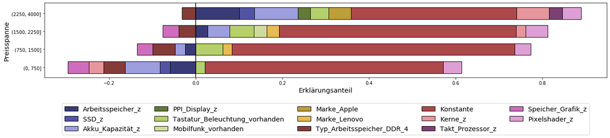

```python
übersicht(x.fit_mod_lin1_z, mod_lin1_z, -0.35, 0.95)
```